# Ch. 7 Gravity Waves — fluidpy

## 7.5 Group Velocity, Energy Flux, and Dispersion

**What is this section about?** When the speed depends on the wavelength, a group of waves moves at a different speed from its crests. That group speed, dω/dk, is the speed of the energy — the answer to C06's cliff-hanger. Then we let the depth change slowly: frequency stays constant along rays while wavelength and direction change, which is why waves turn toward beaches.

### 🧩 Group velocity and the energy flux `C09`

*The question:* Why do crests appear at the back of a group of swell and vanish at its front — and which speed carries the energy?

*In one line:* $c_g=\Delta\omega/\Delta k=d\omega/dk$ *(7.67)* · $F=Ec_g,\ E=\tfrac12\rho ga^2$ *(7.71)*

📝 **Note.** **Dispersion is common** `N64` — Speeds that depend on wavelength are common for waves on interfaces between materials (Rayleigh and Stoneley waves in solids, liquid–liquid interfaces); we stay with water.

#### The problem in plain words

Surfers wait for "sets": swell arrives in groups of a few big waves, then a lull. Watch one crest in a group and it runs forward through the group and fades at the front, while new crests grow at the back. The group — and the energy — is slower than the crests. We want that speed and the proof that energy rides with it.

#### The idea

```
ω(k) curve:   slope of the chord from the origin to (k, ω)   = ω/k   = c    (crests)
              slope of the tangent at (k, ω)                 = dω/dk = c_g  (groups, energy)
deep water:   ω = √(gk) bends down  ⇒  tangent flatter than chord  ⇒  c_g = c/2
```

> 🔁 **Tools from earlier chapters used here** (see `knowledge/primers.md`)
- **derivative as the limit of a difference quotient** — $d\omega/dk=\lim_{\Delta k\to0}\Delta\omega/\Delta k$: the chord slope becomes the tangent slope (Ch. 1 P19).

#### 🧮 Derivation — Beats and the group velocity $c_g=d\omega/dk$ `D19` (Eq. 7.67: $c_g=\Delta\omega/\Delta k=d\omega/dk$)

**What we want to show.** Show that two waves of nearly equal length make groups, and that the groups move at dω/dk.

**Assumptions.** Equal amplitudes; Δk small (step 7).

**The plan.**

1. Sum-to-product.
2. Read the speed of the fast factor and of the slow factor.
3. Let the waves merge.

**Tools we use** (each explained before this point): sum-to-product identities (P171) · D01's phase argument · derivative as a limit (P19).

**We start from**

$$ \eta=a\cos(k_1x-\omega_1t)+a\cos(k_2x-\omega_2t)\ \text{,}\ \omega_i=\omega(k_i)\ \text{.} $$

**Step 1 of 7 — Add two nearby waves.**

$$ \eta=a\cos(k_1x-\omega_1t)+a\cos(k_2x-\omega_2t) $$

- *Why we can do this:* Superposition; the medium fixes each ω_i through its dispersion relation.
- *In words:* two waves of almost the same wavelength.

**Step 2 of 7 — Define means and differences.**

$$ k=\tfrac{k_1+k_2}2,\ \omega=\tfrac{\omega_1+\omega_2}2,\ \Delta k=k_2-k_1,\ \Delta\omega=\omega_2-\omega_1 $$

- *Why we can do this:* These are the half-sums and half-differences that the sum-to-product identity (P171) needs; they also name the mean wave.
- *In words:* a central wave and a small mismatch.

**Step 3 of 7 — Apply sum-to-product.**

$$ \eta=2a\cos\big(\tfrac12\Delta k\,x-\tfrac12\Delta\omega\,t\big)\cos(kx-\omega t)\ \text{(7.66)} $$

- *Why we can do this:* With A = k₁x − ω₁t, B = k₂x − ω₂t: (A + B)/2 = kx − ωt and (A − B)/2 = −(½Δk x − ½Δω t); cos is even.
- *In words:* a fast carrier times a slow envelope.

**Step 4 of 7 — Correct the printed slip.**

$$ \text{printed: }\cos\big(\tfrac12\Delta k\,x-\tfrac12\Delta\omega\,x\big)\ \to\ \text{read}\ \tfrac12\Delta\omega\,t $$

- *Why we can do this:* The identity gives ½Δω t; the book's next line and its figure use t. With x the envelope would not depend on time and could never move.
- *In words:* the envelope must move in time.

**Step 5 of 7 — Read the carrier's speed.**

$$ kx-\omega t=\text{const}\Rightarrow\frac{dx}{dt}=\frac\omega k=c $$

- *Why we can do this:* D01's argument applied to the fast factor.
- *In words:* crests move at the phase speed.

**Step 6 of 7 — Read the envelope's speed.**

$$ \tfrac12\Delta k\,x-\tfrac12\Delta\omega\,t=\text{const}\Rightarrow\frac{dx}{dt}=\frac{\Delta \omega}{\Delta k} $$

- *Why we can do this:* The same argument for the slow factor; its wavelength is 4π/Δk and its period 4π/Δω.
- *In words:* nodes of the envelope move at Δω/Δk.

**Step 7 of 7 — Let the waves merge.**

$$ c_g=\lim_{\Delta k\to0}\frac{\Delta\omega}{\Delta k}=\frac{d\omega}{dk}\ \text{(7.67)} $$

- *Why we can do this:* The difference quotient tends to the derivative (P19): the chord slope becomes the tangent slope of ω(k).
- *In words:* groups move at the slope of the dispersion curve.

**Result**

$$ \eta=2a\cos\big(\tfrac12\Delta k\,x-\tfrac12\Delta\omega\,t\big)\cos(kx-\omega t)\ \text{(7.66)},\qquad c_g=\Delta\omega/\Delta k=d\omega/dk\ \text{(7.67)} $$

*In words:* fast carrier at c, slow envelope at the group velocity

**What it means.** No energy crosses a node of the envelope, so energy travels at the node speed — c_g (made precise for packets in D20 and for the flux in D21).

**Check it.** Deep water, k₁ = 0.9, k₂ = 1.1 rad/m: Δω/Δk = 1.568 m/s vs ½√(g/k) = 1.566 m/s at k = 1 ✓.

> ⚠️ **Common confusion (traps in `D19`):** Taking the printed Δω x literally; mixing the envelope's wavelength (4π/Δk) with the beat length between nodes (2π/Δk).

📝 **Note.** **Beats** `N65` — Two nearby waves make the beat pattern (7.66). The book prints ½Δω **x** in (7.66); it must be ½Δω **t** — the next line of the text and the figure use t, and with x the envelope could not move. The code compares the two forms: the node of the correct envelope moves by $\frac{\Delta\omega}{\Delta k}\times10$ s, the printed one does not move.

$$ \eta=2a\cos\big(\tfrac12\Delta k\,x-\tfrac12\Delta\omega\,t\big)\cos(kx-\omega t) \qquad \text{(7.66)} $$

> 📎 **Primer — np.sign and np.nonzero: finding where a curve crosses zero.** `P180` · `np.sign(e)` turns every value into −1, 0 or +1. Where two neighbours `e[:-1]` and `e[1:]` have different signs the curve crossed zero between them. `np.nonzero(mask)` returns the indices where a True/False array is True (as a tuple, one array per axis — hence the `[0]`), so `np.nonzero(...)[0][0]` is the first crossing; a straight line between the two neighbours then places the zero precisely.

```python
import numpy as np                                        # arrays
e = np.array([2.0, 1.0, -1.0, -2.0])                      # a curve sampled at x = 0, 1, 2, 3
i = np.nonzero(np.sign(e[:-1]) != np.sign(e[1:]))[0][0]   # first index before a sign change → 1
print(i, i - e[i]*(1.0)/(e[i + 1] - e[i]))                 # 1 and the interpolated zero at x = 1.5
```

```
1 1.5
```

```python
x = np.linspace(-40, 80, 24001)                           # positions [m]
env = lambda t, printed: ch07.beat_wave(x, t, 0.9, 1.1, printed=printed)["envelope"]   # (7.66), deep water
b = ch07.beat_wave(x, 0.0, 0.9, 1.1)                      # k₁ = 0.9, k₂ = 1.1 rad/m
def node(e):                                              # first zero of the envelope beyond x = 5 m [m]
    i = np.nonzero((x[:-1] > 5) & (np.sign(e[:-1]) != np.sign(e[1:])))[0][0]   # first sign change
    return x[i] - e[i]*(x[i + 1] - x[i])/(e[i + 1] - e[i])   # linear interpolation to the zero
for pr in (False, True):                                  # correct ½Δω t, then the printed ½Δω x
    print(f"printed={pr}: envelope node at t = 0: {node(env(0.0, pr)):.3f} m, at t = 10 s: {node(env(10.0, pr)):.3f} m")
print(f"Δω/Δk = {b['cg_finite']:.4f} m/s, dω/dk at k = 1 = {ch07.group_velocity(1.0):.4f} m/s, c = {b['c']:.4f} m/s")
```

```
printed=False: envelope node at t = 0: 15.708 m, at t = 10 s: 31.388 m
printed=True: envelope node at t = 0: 27.654 m, at t = 10 s: 27.654 m
Δω/Δk = 1.5680 m/s, dω/dk at k = 1 = 1.5660 m/s, c = 3.1282 m/s
```

**What does the code above do?**

With ½Δω t the node moves from 15.7 m to 31.4 m in 10 s — 1.568 m/s, close to the tangent slope $d\omega/dk=\tfrac12\sqrt{g/k}=1.566$ m/s at k = 1 rad/m, while the crests move at c = 3.13 m/s. With the printed ½Δω x the node stays where it is: that form describes a frozen pattern, not a wave group.

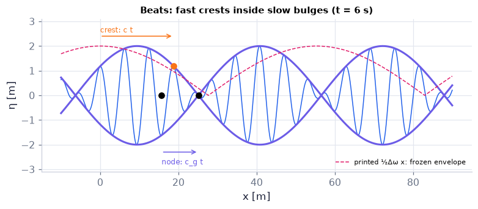

```python
x = np.linspace(-10, 90, 3000)                            # positions [m]
fig, ax = plt.subplots(figsize=(7, 3))                    # one panel
b0, b1 = ch07.beat_wave(x, 0.0, 0.9, 1.1), ch07.beat_wave(x, 6.0, 0.9, 1.1)   # t = 0 and t = 6 s
ax.plot(x, b1["eta"], color=COLORS["blue"], lw=1)         # the beats at t = 6 s
ax.plot(x, np.abs(b1["envelope"]), color=COLORS["accent"], lw=2); ax.plot(x, -np.abs(b1["envelope"]), color=COLORS["accent"], lw=2)   # ± the envelope
ax.plot(x, np.abs(ch07.beat_wave(x, 6.0, 0.9, 1.1, printed=True)["envelope"]), ls="--", color=COLORS["rose"], lw=1,   # the printed slip's envelope
        label="printed ½Δω x: frozen envelope")          # the slip's ghost (it does not move)
xn0 = np.pi/b0["dk"]                                      # a node of the correct envelope at t = 0 [m]
xn1 = xn0 + b0["cg_finite"]*6.0                           # it moves at Δω/Δk [m]
ax.plot([xn0, xn1], [0, 0], "ko"); ax.annotate("", xy=(xn1, -2.3), xytext=(xn0, -2.3), arrowprops=dict(arrowstyle="->", color=COLORS["accent"]))   # the node then and now, and its arrow
ax.text(xn0, -2.8, "node: c_g t", fontsize=8, color=COLORS["accent"])   # label
xc0 = 0.0; xc1 = xc0 + b0["c"]*6.0                        # a crest moves at c [m]
ax.plot([xc1], [np.abs(b1["envelope"][np.argmin(np.abs(x - xc1))])], "o", color=COLORS["orange"])   # the tracked crest at t = 6 s
ax.annotate("", xy=(xc1, 2.4), xytext=(xc0, 2.4), arrowprops=dict(arrowstyle="->", color=COLORS["orange"]))   # how far the crest moved
ax.text(xc0, 2.55, "crest: c t", fontsize=8, color=COLORS["orange"])   # label
ax.set_ylim(-3.1, 3.1); ax.set_xlabel("x [m]"); ax.set_ylabel("η [m]"); ax.legend(fontsize=7, loc="lower right")   # axes and legend
ax.set_title("Beats: fast crests inside slow bulges (t = 6 s)", fontsize=10)   # the message
savefig(fig, "ch07", "c09_beats"); plt.show()   # save, then draw
```

**What you see.** Fast crests (blue) inside slow bulges bounded by the purple envelope; in 6 s a crest (orange) moved 18.8 m but a node (black) only 9.4 m; the rose dashed ghost is the printed envelope, which stays put (our remake of Fig. 7.13 `N179`).

**How to read it.** Nodes travel at Δω/Δk: no energy crosses a node, so the energy travels at the node speed.

**What would change if…** …Δk were halved: the groups become twice as long and the node speed tends to dω/dk.

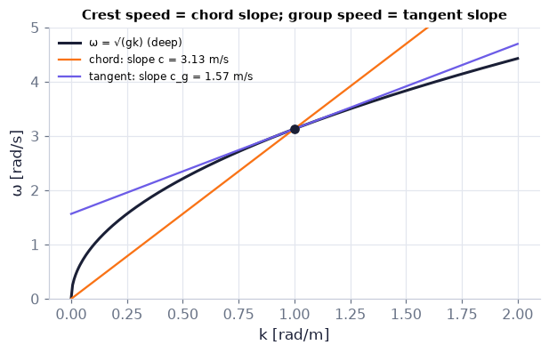

```python
k = np.linspace(0, 2, 300)                                # wavenumbers [rad/m]
fig, ax = plt.subplots(figsize=(5.5, 3.5))                # one panel
ax.plot(k, ch07.omega_gravity(k), color=COLORS["ink"], lw=2, label="ω = √(gk) (deep)")   # (7.28) deep
k0, w0, cg0 = 1.0, ch07.omega_gravity(1.0), ch07.group_velocity(1.0)   # the point k = 1 rad/m
ax.plot(k, w0/k0*k, color=COLORS["orange"], lw=1.5, label=f"chord: slope c = {w0/k0:.2f} m/s")        # ω/k
ax.plot(k, w0 + cg0*(k - k0), color=COLORS["accent"], lw=1.5, label=f"tangent: slope c_g = {cg0:.2f} m/s")   # dω/dk
ax.plot(k0, w0, "o", color=COLORS["ink"])
ax.set_ylim(0, 5); ax.set_xlabel("k [rad/m]"); ax.set_ylabel("ω [rad/s]"); ax.legend(fontsize=8)
ax.set_title("Crest speed = chord slope; group speed = tangent slope", fontsize=10)
savefig(fig, "ch07", "c09_chord_tangent"); plt.show()
```

**What you see.** The deep-water ω(k) with, at k = 1 rad/m, the chord from the origin (orange, slope c = 3.13 m/s) and the tangent (purple, slope $c_g=1.57$ m/s) — our remake of Fig. 7.14 `N180`.

**How to read it.** $c_g<c$ wherever ω(k) bends down (gravity waves); $c_g>c$ where it bends up (capillary waves).

**What would change if…** …shallow water: ω = k√(gH) is a straight line through the origin — chord and tangent coincide, $c_g=c$.

> 📎 **Primer — Fourier integral and a packet's spectrum.** `P172` · A real wave group is a continuous sum of sinusoids, $\eta(x,t)=\int A(k)e^{i(kx-\omega(k)t)}dk$ (real part understood), where A(k) is its spectrum. A narrow spectrum of width δk around k₀ means a long group of length ~1/δk, and near k₀ we may Taylor-expand ω(k) (Ch. 1 P26). This is Ch. 5 P142's discrete Fourier modes with the sum turned into an integral.

```python
import numpy as np                                # numbers
x = np.linspace(-200, 200, 4001)                  # positions [m]
k = np.linspace(0.9, 1.1, 201); A = np.exp(-(k - 1)**2/(2*0.02**2))   # a narrow spectrum around k₀ = 1 rad/m
eta = (A[:, None]*np.cos(k[:, None]*x)).sum(0)*(k[1] - k[0])          # the integral as a sum over k
print(x[np.argmax(eta)], np.abs(eta[np.abs(x) > 150]).max()/eta.max())   # peak at 0; tails < 1 %: ~1/0.02 = 50 m long
```

```
0.0 0.01060198039029159
```

📝 **Note.** **A wave packet** `N66` — All wavenumbers in a narrow band δk around k; in space a nearly sinusoidal wave whose amplitude dies away over a length ∝ 1/δk. The figure is our remake of Fig. 7.15 `N181`.

> 📎 **Primer — np.fft.rfft and np.fft.rfftfreq.** `P181` · For a **real** signal the FFT's negative-wavenumber half mirrors the positive half, so `np.fft.rfft(eta)` returns only the modes with k ≥ 0 (a reminder of the FFT itself: Ch. 5 P142). `np.fft.rfftfreq(n, d)` gives the matching frequencies in cycles per unit length for n samples spaced d apart; multiplying by 2π turns them into wavenumbers in rad/m. The size `np.abs(...)` of each complex mode is the height of the spectrum.

```python
import numpy as np                                        # arrays
x = np.arange(8)*0.5                                      # 8 samples, 0.5 m apart (a 4 m periodic domain)
F = np.fft.rfft(np.cos(2*np.pi*x/2.0))                    # a cosine of wavelength 2 m
print(2*np.pi*np.fft.rfftfreq(8, d=0.5), np.abs(F).round(3))   # k = 0, 1.57, 3.14, 4.71, 6.28 rad/m; peak at k = π rad/m
```

```
[0.     1.5708 3.1416 4.7124 6.2832] [0. 0. 4. 0. 0.]
```

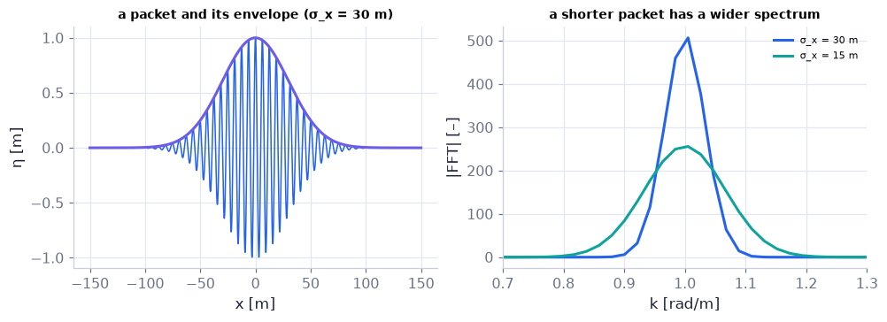

```python
x = np.linspace(-150, 150, 4096, endpoint=False)          # a periodic domain [m]
fig, (a1, a2) = plt.subplots(1, 2, figsize=(9, 3.2))      # packet | spectrum
for sx, cl in ((30.0, COLORS["blue"]), (15.0, COLORS["teal"])):   # a long and a short packet [m]
    p = ch07.gaussian_packet(x, 0.0, 1.0, 1.0, sx)        # η = e^{−x²/2σx²} cos k₀x at t = 0
    if sx == 30.0:
        a1.plot(x, p["eta"], color=cl, lw=1); a1.plot(x, p["envelope"], color=COLORS["accent"], lw=2)
    kk = 2*np.pi*np.fft.rfftfreq(x.size, d=x[1] - x[0])   # wavenumbers of the FFT [rad/m]
    a2.plot(kk, np.abs(np.fft.rfft(p["eta"])), color=cl, lw=2, label=f"σ_x = {sx:.0f} m")   # |spectrum|
a1.set_xlabel("x [m]"); a1.set_ylabel("η [m]"); a1.set_title("a packet and its envelope (σ_x = 30 m)", fontsize=9)
a2.set_xlim(0.7, 1.3); a2.set_xlabel("k [rad/m]"); a2.set_ylabel("|FFT| [–]"); a2.legend(fontsize=7)
a2.set_title("a shorter packet has a wider spectrum", fontsize=9)
savefig(fig, "ch07", "c09_packet_spectrum"); plt.show()
```

**What you see.** Left, a Gaussian packet (blue) inside its envelope (purple); right, the size of its Fourier spectrum around k₀ = 1 rad/m, and that of a packet half as long (teal), twice as wide.

**How to read it.** Length × width ≈ constant: for a Gaussian, σ_x σ_k = 1, so 30 m ↔ 0.033 rad/m and 15 m ↔ 0.067 rad/m.

**What would change if…** …the packet were halved again: its spectrum doubles again — and it spreads faster in time (D20's dropped term).

> 🔁 **Tools from earlier chapters used here** (see `knowledge/primers.md`)
- **substitution in an integral** — replace k by $k_0+\kappa$ and dk by dκ (Ch. 3 P106).
- **complex amplitudes** — Re is taken at the end, so $e^{i\theta}$ factors can be pulled out of integrals (primer P176 in C13 develops this; here only $\mathrm{Re}[a\,e^{i\theta}]=a\cos\theta$ for real a is used, Ch. 1 P45).

#### 🧮 Derivation — A packet's envelope moves at c_g: $\eta=a(x-c_gt)\cos(kx-\omega t)$ `D20` (Eq. 7.68: $\eta=a(x-c_gt)\cos(kx-\omega t)$)

**What we want to show.** Show that a narrow packet keeps its envelope shape and carries it at c_g = dω/dk, and see what eventually spreads it. (The book cites Phillips (1977) without the steps; we write them out.)

**Assumptions.** Narrow spectrum δk ≪ k₀ (step 2); short times t ≪ 1/(ω″δk²) (step 7); A symmetric about k₀ for a real envelope (step 10).

**The plan.**

1. Measure k from the carrier.
2. Taylor-expand ω(k).
3. Split the phase into carrier + envelope + small rest.
4. Drop the rest for short times and recognise the shifted envelope.

**Tools we use** (each explained before this point): Fourier integral and a packet's spectrum (P172) · Taylor expansion (P26) · substitution in an integral (P106) · complex amplitudes (Re taken at the end).

**We start from**

$$ \eta(x,t)=\mathrm{Re}\int A(k)\,e^{i(kx-\omega(k)t)}dk\ \text{with A(k) concentrated near k₀} $$

*In words:* a group is a continuous sum of sinusoids, each moving at its own speed.

**Step 1 of 12 — Write the packet as a Fourier integral.**

$$ \eta=\mathrm{Re}\int A(k)e^{i(kx-\omega(k)t)}dk $$

- *Why we can do this:* Linear waves superpose, and each Fourier component moves with its own ω(k) (N02, P172).
- *In words:* a group is a sum of sinusoids.

**Step 2 of 12 — Say what 'narrow' means.**

$$ A(k)\approx0\ \text{unless}\ \lvert k-k_0\rvert\lesssim\delta k,\ \delta k\ll k_0 $$

- *Why we can do this:* A long, nearly sinusoidal group has a narrow spectrum (length ~ 1/δk, N66); this is the key assumption.
- *In words:* only wavenumbers near k₀ are present.

**Step 3 of 12 — Measure k from the carrier.**

$$ k=k_0+\kappa,\quad dk=d\kappa $$

- *Why we can do this:* A change of variable (P106); κ is small wherever A is not zero.
- *In words:* count wavenumbers from the centre.

**Step 4 of 12 — Look at the initial shape.**

$$ \eta(x,0)=\mathrm{Re}\big[e^{ik_0x}a(x)\big],\quad a(x)\equiv\int A(k_0+\kappa)e^{i\kappa x}d\kappa $$

- *Why we can do this:* At t = 0 factor $e^{ik_0x}$ out of the integral; what remains contains only small κ, so it varies slowly in x.
- *In words:* a carrier times a slowly varying envelope.

**Step 5 of 12 — Taylor-expand the dispersion relation.**

$$ \omega(k_0+\kappa)=\omega_0+c_g\kappa+\tfrac12\omega''\kappa^2+\ldots $$

- *Why we can do this:* ω(k) is smooth and κ is small (P26); c_g = ω′(k₀), ω″ = ω″(k₀).
- *In words:* near k₀ the curve is almost its tangent.

**Step 6 of 12 — Substitute into the phase.**

$$ kx-\omega t=(k_0x-\omega_0t)+\kappa(x-c_gt)-\tfrac12\omega''\kappa^2t $$

- *Why we can do this:* kx = k₀x + κx; subtract t × the Taylor series; group the terms by powers of κ.
- *In words:* carrier phase + envelope phase + a small correction.

**Step 7 of 12 — Drop the quadratic term for short times.**

$$ \tfrac12\lvert\omega''\rvert\kappa^2t\ll1\ \text{while}\ t\ll\frac{1}{\lvert \omega''\rvert\delta k^2} $$

- *Why we can do this:* κ is at most about δk, so this term changes the phase by much less than a radian for such times.
- *In words:* for a while the curvature of ω(k) does not matter.

**Step 8 of 12 — Factor out the carrier.**

$$ \eta\approx\mathrm{Re}\Big[e^{i(k_0x-\omega_0t)}\int A(k_0+\kappa)e^{i\kappa(x-c_gt)}d\kappa\Big] $$

- *Why we can do this:* The carrier phase does not depend on κ, so it leaves the integral.
- *In words:* the carrier moves out in front.

**Step 9 of 12 — Recognise the envelope.**

$$ \int A(k_0+\kappa)e^{i\kappa(x-c_gt)}d\kappa=a(x-c_gt) $$

- *Why we can do this:* It is step 4's integral with x replaced by x − c_g t.
- *In words:* the envelope is the initial envelope, shifted by c_g t.

**Step 10 of 12 — Take the real part.**

$$ \eta=a(x-c_gt)\cos(k_0x-\omega_0t)\ \text{(7.68)} $$

- *Why we can do this:* For A symmetric about k₀ the envelope a is real, and Re[a $e^{i\theta}$] = a cos θ.
- *In words:* envelope at c_g, carrier at c = ω₀/k₀.

**Step 11 of 12 — Look at the dropped term.**

$$ \text{later: width}\sim\lvert\omega''\rvert\,\delta k\,t $$

- *Why we can do this:* Components with different κ pick up different phases −½ω″κ²t and drift apart: dispersion spreads the packet; zero only if ω″ = 0 (shallow water).
- *In words:* the dropped term is what makes packets spread.

**Step 12 of 12 — Identify the energy speed.**

$$ E(x,t)=\tfrac12\rho g\,a(x-c_gt)^2 $$

- *Why we can do this:* The local energy density (7.42), $E=E_p+E_k=\rho g\overline{\eta^2}=\tfrac12\rho ga^2$ is carried by the envelope, so it moves at c_g — the same speed D21 finds for the flux, (7.71) F = E c_g.
- *In words:* the energy travels with the group.

**Result**

$$ \eta=a(x-c_gt)\cos(kx-\omega t)\ \text{(7.68),}\ c_g=d\omega/dk\ \text{, valid for}\ t\ll1/(\lvert\omega''\rvert\delta k^2)\ \text{.} $$

**What it means.** Groups, energy and any signal travel at dω/dk; crests only at ω/k. Swell forecasting, tsunami arrival and every "where does the energy go" question of Ch. 13 use this.

**Check it.** Units: c_g t [m] ✓. Shallow water: ω″ = 0, the result is exact for all times ✓. Numbers: the FFT packet of C09 (k₀ = 1 rad/m, deep) moves its envelope peak at 1.566 m/s within 1 % ✓.

```python
import sympy as sp                                              # symbolic algebra
k0, kap, x, t, w0, cg, w2 = sp.symbols('k0 kappa x t omega0 c_g omega2', real=True)   # carrier, offset, position, time, ω₀, c_g, ω″
xi = sp.symbols('xi', real=True)                                # the moving coordinate ξ = x − c_g t
omega_taylor = w0 + cg*kap + w2*kap**2/2                        # step 5: ω(k₀ + κ) to second order
phase = (k0 + kap)*x - omega_taylor*t                           # steps 3 and 6: the phase kx − ωt with k = k₀ + κ
split = (k0*x - w0*t) + kap*(x - cg*t) - w2*kap**2*t/2          # step 6: carrier + envelope + small rest
print("step 6 regrouping:", sp.expand(phase - split))           # 0: the regrouping is exact
al, bt = sp.symbols('alpha beta', positive=True)                # a Gaussian spectrum e^{−ακ²} and a position β
gauss = sp.integrate(sp.exp(-al*kap**2 + sp.I*bt*kap), (kap, -sp.oo, sp.oo))    # ∫ e^{−ακ² + iβκ} dκ
print("Gaussian integral:", sp.simplify(gauss - sp.sqrt(sp.pi/al)*sp.exp(-bt**2/(4*al))))   # 0: = √(π/α) e^{−β²/4α}
s, tt = sp.symbols('s tau', positive=True)                      # spectral width δk and a (positive) time τ
Gauss = lambda A_, B_: sp.sqrt(sp.pi/A_)*sp.exp(-B_**2/(4*A_))  # the closed form just verified, ∫e^{−Aκ² + iBκ}dκ
a0 = Gauss(1/(2*s**2), x)                                       # step 4: a(x) for the spectrum A(k₀ + κ) = e^{−κ²/2s²}
env1 = Gauss(1/(2*s**2), x - cg*tt)                             # step 9 with ω″ dropped: the integral with κ(x − c_g t)
print("steps 9-10: envelope − a(x − c_g t) =", sp.simplify(env1 - a0.subs(x, x - cg*tt)),   # 0: it IS the initial shape …
      "; ∂/∂t + c_g ∂/∂x of it =", sp.simplify(sp.diff(env1, tt) + cg*sp.diff(env1, x)))   # … carried rigidly at c_g
alpha2 = 1/(2*s**2) + sp.I*w2*tt/2                              # keep ω″: the exponent −κ²/2s² − iω″κ²t/2, α complex
m2 = sp.simplify(sp.pi/sp.Abs(alpha2)*sp.exp(-xi**2*sp.re(1/alpha2)/2))   # |envelope|² = |√(π/α)|² |e^{−ξ²/4α}|²
print("|envelope|² =", m2)
print("slope of |envelope|² at ξ = 0:", sp.simplify(sp.diff(m2, xi).subs(xi, 0)))   # 0: the peak rides at x = c_g t (step 12)
print("peak ratio:", sp.simplify(m2.subs(xi, 0)/m2.subs({xi: 0, tt: 0})))   # 1/√(1 + (ω″s²t)²): spreading once t ~ 1/(ω″δk²), step 7
```

```
step 6 regrouping: 0
```

```
Gaussian integral: 0
steps 9-10: envelope − a(x − c_g t) = 0 ; ∂/∂t + c_g ∂/∂x of it = 0
|envelope|² = 2*pi*s**2*exp(-s**2*xi**2/(omega2**2*s**4*tau**2 + 1))/sqrt(omega2**2*s**4*tau**2 + 1)
slope of |envelope|² at ξ = 0: 0
```

```
peak ratio: 1/sqrt(omega2**2*s**4*tau**2 + 1)
```

> ⚠️ **Common confusion (traps in `D20`):** Thinking the carrier moves at c_g (it moves at c); dropping the quadratic term forever (packets do spread); forgetting that a narrow spectrum is essential (a single spike has no group).

📝 **Note.** **The packet keeps its shape for a while** `N67` — For short times the packet's envelope moves at $c_g$: $\eta=a(x-c_gt)\cos(kx-\omega t)$ *(7.68)* (the book cites Phillips; D20 writes it out). The nodes of the envelope move at $c_g$ and no energy crosses them.

> 🔁 **Tools from earlier chapters used here** (see `knowledge/primers.md`)
- **chain rule** — $d\,\omega^2/dk=2\omega\,d\omega/dk$ (Ch. 1 P49); the product rule differentiates $k\tanh kH$ (Ch. 1 P38).

#### 🧮 Derivation — $c_g=\frac c2\big[1+\frac{2kH}{\sinh2kH}\big]$, its limits and $F=Ec_g$ `D21` (Eq. 7.69: $c_g=\frac c2\Big[1+\frac{2kH}{\sinh(2kH)}\Big]$)

**What we want to show.** Differentiate the dispersion relation of water waves, read off its limits, and recognise the second factor of the energy flux (7.44), $F=\Big[\tfrac12\rho ga^2\Big]\Big[\frac c2\Big(1+\frac{2kH}{\sinh2kH}\Big)\Big]$.

**Assumptions.** Linear gravity waves, constant depth.

**The plan.**

1. Differentiate ω² implicitly.
2. Divide by c and simplify.
3. Take the limits.
4. Compare with (7.44), $F=\Big[\tfrac12\rho ga^2\Big]\Big[\frac c2\Big(1+\frac{2kH}{\sinh2kH}\Big)\Big]$.

**Tools we use** (each explained before this point): chain and product rules (P49, P38) · hyperbolic identities (P168) · D14.

**We start from**

$$ \omega^2=gk\tanh kH\ \text{(7.28).} $$

**Step 1 of 11 — Differentiate ω².**

$$ 2\omega\frac{d\omega}{dk}=\frac{d}{dk}(gk\tanh kH) $$

- *Why we can do this:* Differentiating ω² with the chain rule (P49) avoids differentiating a square root.
- *In words:* the slope of ω² in terms of the slope of ω.

**Step 2 of 11 — Use the product rule.**

$$ \frac{d}{dk}(gk\tanh kH)=g\tanh kH+gkH\,\mathrm{sech}^2kH $$

- *Why we can do this:* Product of k and tanh kH (P38); d/dk tanh kH = H sech² kH (chain rule, tanh′ = sech²).
- *In words:* two contributions.

**Step 3 of 11 — Solve for dω/dk.**

$$ c_g=\frac{g\tanh kH+gkH\,\mathrm{sech}^2kH}{2\omega} $$

- *Why we can do this:* Divide both sides by 2ω, which is not zero for a wave; the left side is then dω/dk alone.
- *In words:* the group velocity.

**Step 4 of 11 — Divide by c = ω/k.**

$$ \frac{c_g}c=\frac{k\,(g\tanh kH+gkH\,\mathrm{sech}^2kH)}{2\omega^2} $$

- *Why we can do this:* Since c = ω/k, dividing by c is multiplying by k/ω; the ratio c_g/c is easier to simplify.
- *In words:* the ratio to the phase speed.

**Step 5 of 11 — Replace ω² by (7.28).**

$$ \frac{c_g}c=\frac{gk\tanh kH+gk\cdot kH\,\mathrm{sech}^2kH}{2gk\tanh kH} $$

- *Why we can do this:* Replace ω² in the denominator by the dispersion relation (7.28) ω² = gk tanh kH, so g and k can cancel.
- *In words:* g and k are about to cancel.

**Step 6 of 11 — Divide through.**

$$ \frac{c_g}c=\frac12\Big(1+\frac{kH\,\mathrm{sech}^2kH}{\tanh kH}\Big) $$

- *Why we can do this:* Each term divided by gk tanh kH.
- *In words:* one half, plus a depth correction.

**Step 7 of 11 — Simplify sech²/tanh.**

$$ c_g=\frac c2\Big[1+\frac{2kH}{\sinh(2kH)}\Big]\ \text{(7.69)} $$

- *Why we can do this:* sech²x/tanh x = 1/(sinh x cosh x) = 2/sinh 2x (P168).
- *In words:* the group velocity of water waves.

**Step 8 of 11 — Take deep water.**

$$ kH\to\infty:\ \frac{2kH}{\sinh2kH}\to0\ \Rightarrow\ c_g=\frac c2\ \text{(7.70)} $$

- *Why we can do this:* sinh grows exponentially, faster than its argument.
- *In words:* energy moves at half the crest speed.

**Step 9 of 11 — Take shallow water.**

$$ kH\to0:\ \frac{2kH}{\sinh2kH}\to1\ \Rightarrow\ c_g=c\ \text{(7.70)} $$

- *Why we can do this:* sinh y ≈ y for small y (P168).
- *In words:* groups and crests together — no dispersion.

**Step 10 of 11 — Compare with the energy flux.**

$$ F=\big[\tfrac12\rho ga^2\big]\Big[\frac c2\Big(1+\frac{2kH}{\sinh2kH}\Big)\Big]=Ec_g\ \text{(7.71)} $$

- *Why we can do this:* (7.44), $F=\Big[\tfrac12\rho ga^2\Big]\Big[\frac c2\Big(1+\frac{2kH}{\sinh2kH}\Big)\Big]$'s first factor is E (7.42), $E=E_p+E_k=\rho g\overline{\eta^2}=\tfrac12\rho ga^2$ and its second is exactly (7.69), $c_g=\frac c2\Big[1+\frac{2kH}{\sinh(2kH)}\Big]$.
- *In words:* energy flux = energy × group velocity.

**Step 11 of 11 — Read it as an energy speed.**

$$ c_E\equiv\frac FE=c_g $$

- *Why we can do this:* A flux divided by the density of what flows is the speed at which it flows (as mass flux ρu over ρ is u).
- *In words:* wave energy travels at the group velocity.

**Result**

$$ c_g=\frac c2\big[1+\frac{2kH}{\sinh(2kH)}\big]\ \text{(7.69),}\ c_g=c/2\ \text{(deep),}\ c_g=c\ \text{(shallow) (7.70),}\ F=Ec_g $$

**What it means.** C06's cliff-hanger is solved: the speed in (7.44), $F=\Big[\tfrac12\rho ga^2\Big]\Big[\frac c2\Big(1+\frac{2kH}{\sinh2kH}\Big)\Big]$ is the group velocity. Swell energy from a distant storm arrives at c_g.

**Check it.** H = 10 m, λ = 50 m: c = 8.15 m/s, c_g = 5.74 m/s (ratio 0.705) ✓ (numeric central difference agrees to 1e-8). Pure capillary ω² = σk³/ρ gives c_g = 3c/2 (`group_velocity(g=0)` returns it) ✓.

> ⚠️ **Common confusion (traps in `D21`):** Forgetting the product rule (tanh kH depends on k); deep-water c_g = c/2, not 2c; confusing sinh(2kH) with 2 sinh kH.

📝 **Note.** **Group velocity of water waves** `N68–N70` — $c_g=\frac c2\Big[1+\frac{2kH}{\sinh(2kH)}\Big]$ *(7.69)*; $c_g=c/2\ \text{(deep water)},\ c_g=c\ \text{(shallow water)}$ *(7.70)*; pure capillary waves have $c_g=3c/2$ (checked below with `group_velocity(g=0)`); and $F=E\frac c2\big[1+\frac{2kH}{\sinh(2kH)}\big]=Ec_g$ *(7.71)*, $E=\rho ga^2/2$ — **the rate of energy transmission is energy times group velocity**.

📝 **Note.** **In three dimensions** `N71` — $c_{gi}=\partial\omega/\partial K_i$: the group velocity is the gradient of ω in wavenumber space (used for internal waves in C16). For deep water with K = (0.6, 0.8) rad/m (|K| = 1) it points along K with size $\tfrac12\sqrt{g/K}=1.566$ m/s:

$$ \mathbf c_g=\nabla_{\mathbf K}\,\omega(\mathbf K) $$

```python
print(ch07.group_velocity_vector(lambda K: np.sqrt(G*np.hypot(K[0], K[1])), np.array([0.6, 0.8])), "m/s")   # ∂ω/∂K_i
```

```
[0.9396 1.2528] m/s
```

#### ✏️ Tiny example: swell from a distant storm

1. Deep water, λ = 156 m (T = 10 s): $c=\sqrt{g\lambda/2\pi}=15.6$ m/s.
2. $c_g=c/2=7.8$ m/s.
3. A storm 1000 km away: the first energy arrives after $10^6/7.8=128\,000$ s ≈ 35.6 h — not 17.8 h, as the crest speed would suggest.
4. Longer swell (T = 20 s) arrives first: $c_g=15.6$ m/s, 17.8 h — a forecaster reads the storm's distance from how fast the period falls.

```python
k = 2*np.pi/156.0                                          # the swell of the tiny example [rad/m]
print(f"deep: c = {ch07.phase_speed(k):.2f}, c_g = {ch07.group_velocity(k):.2f} m/s")          # (7.29), (7.69)
print(f"on 30 m: c = {ch07.phase_speed(k, 30.0):.2f}, c_g = {ch07.group_velocity(k, 30.0):.2f} m/s")   # kH = 1.21
print(f"H = 10 m, λ = 50 m: c = {ch07.phase_speed(2*np.pi/50, 10.0):.2f}, c_g = {ch07.group_velocity(2*np.pi/50, 10.0):.2f} m/s")
print(f"complex-step dω/dk = {ch07.group_velocity_numeric(None, k):.10f} m/s")                 # numerical (7.67)
kc = 2*np.pi/0.005                                          # a 5 mm ripple [rad/m]
print("pure capillary c_g/c =", ch07.group_velocity(kc, sigma=0.0727, g=0.0)/ch07.phase_speed(kc, sigma=0.0727, g=0.0))
ps = ch07.packet_state(k, distance=1e6)                    # everything about this group, storm 1000 km away
print({n: (round(v, 3) if isinstance(v, float) else v) for n, v in ps.items()})
assert np.isclose(ch07.energy_flux(1.0, k), ch07.wave_energy_density(1.0)*ch07.group_velocity(k))   # (7.44) = E c_g, (7.71)
```

```
deep: c = 15.61, c_g = 7.80 m/s
on 30 m: c = 14.27, c_g = 10.24 m/s
H = 10 m, λ = 50 m: c = 8.15, c_g = 5.74 m/s
complex-step dω/dk = 7.8032742921 m/s
pure capillary c_g/c = 1.5
{'omega': 0.629, 'lam': 156.0, 'c': 15.607, 'cg': 7.803, 'ratio': 0.5, 'E': 4905.0, 'F': 38275.06, 't_crest_cross': 199.916, 'arrival_h': 35.598, 'regime': 'cg<c'}
```

**What does the code above do?**

1. Deep water: c = 15.61 and $c_g=7.80$ m/s (half). On a 30 m shelf (kH = 1.21) c = 14.27 m/s but $c_g=10.24$ m/s — larger than in deep water: in intermediate depth $c_g/c$ rises toward 1. For H = 10 m, λ = 50 m: 8.15 and 5.74 m/s (D21's check).
2. The complex-step derivative $\mathrm{Im}\,\omega(k+ih)/h$ has no subtraction, so no cancellation error (Ch. 3 P107): it equals (7.69), $c_g=\frac c2\Big[1+\frac{2kH}{\sinh(2kH)}\Big]$ to ten digits.
3. Pure capillary waves: $c_g/c=1.5$ — groups outrun crests.
4. `packet_state` bundles c, $c_g$, E, F = E c_g and the arrival time from a storm 1000 km away (35.6 h); the assertion is (7.71), $F=Ec_g,\ E=\tfrac12\rho ga^2$: the flux of C06 is energy times group velocity.

> 📎 **Primer — envelope with scipy.signal.hilbert.** `P173` · The modulus of the "analytic signal" `np.abs(scipy.signal.hilbert(eta))` follows the slowly varying amplitude of a fast oscillation — the envelope — without fitting. We use it to track a packet's peak (`ch07.envelope` wraps it).

```python
import numpy as np, scipy.signal as ss            # numbers and signal tools
x = np.linspace(0, 100, 2001); eta = np.exp(-((x - 50)/10)**2)*np.cos(3*x)   # a packet
env = np.abs(ss.hilbert(eta))                     # its envelope
print(x[np.argmax(env)], env.max())               # 50.0, ≈ 1.0
```

```
50.0 0.9999999999999921
```

> 🔁 **Tools from earlier chapters used here** (see `knowledge/primers.md`)
- **periodic FFT domain and wrap-around** — the FFT treats the domain as periodic: whatever leaves at the right re-enters at the left, so the domain must be long enough that the packet never reaches its end (Ch. 5 P142).

**From scratch — two checks of $c_g$.** (1) A central difference of ω(k). (2) Evolve a Gaussian packet (k₀ = 1 rad/m, σ_x = 30 m, deep water) with the FFT (`linear_evolve`, each mode with its own ω(k)) on a periodic domain long enough that nothing wraps round, and fit the speed of the envelope's peak. The run is kept (`packet_run`) for the x–t diagram of C10.

```python
h = 1e-6                                                   # difference step [rad/m] (k = 0.040 rad/m here)
cg_mine =(ch07.omega_gravity(k + h) - ch07.omega_gravity(k - h))/(2*h)   # (1) central difference of (7.28), deep
assert np.allclose(cg_mine, ch07.group_velocity(k), rtol=1e-8)
N = 4096 if not FAST else 1024                             # FFT points (spectral: k₀ = 1 is resolved either way)
xp = np.linspace(0, 2000, N, endpoint=False)               # periodic domain [m]
eta0 = np.exp(-(xp - 300)**2/(2*30**2))*np.cos(1.0*(xp - 300))   # the packet at t = 0 [m]
tp = np.linspace(0, 200, 11)                               # eleven times [s]
packet_run = ch07.linear_evolve(eta0, xp, tp, direction=+1, H=np.inf)   # (7.28) mode by mode, one-way to +x
peaks = [xp[np.argmax(ch07.envelope(e))] for e in packet_run]   # envelope peak at each time [m]
slope = np.polyfit(tp, peaks, 1)[0]                        # its speed [m/s]
print(f"(1) central difference: {cg_mine:.6f} m/s;  (2) envelope peak speed: {slope:.4f} m/s;  c_g = {ch07.group_velocity(1.0):.4f} m/s")
assert np.allclose(slope, ch07.group_velocity(1.0), rtol=1e-2)   # the envelope moves at c_g, not at c = 3.13 m/s
```

```
(1) central difference: 7.803274 m/s;  (2) envelope peak speed: 1.5667 m/s;  c_g = 1.5660 m/s
```

> 📎 **Primer — np.interp: reading a curve between its samples.** `P182` · `np.interp(x_new, x, y)` returns the value of the sampled curve (x, y) at the point x_new by drawing a straight line between the two neighbouring samples (x must be increasing). Below it reads the envelope's height at the tracked crest, which sits between grid points.

```python
import numpy as np                                        # arrays
print(np.interp(1.5, [0.0, 1.0, 2.0], [0.0, 10.0, 30.0])) # halfway between 10 and 30 → 20.0
```

```
20.0
```

```python
fig, (a1, a2) = plt.subplots(2, 1, figsize=(7, 4.6))       # packet (top) | stone in a pond (bottom)
xa = np.linspace(-60, 260, 1200)                           # positions for the packet [m]
p0 = ch07.gaussian_packet(xa, 0.0, 1.0, 1.0, 20.0)         # deep-water packet, k₀ = 1 rad/m, σ_x = 20 m
c, cg = p0["c"], p0["cg"]                                  # 3.13 and 1.57 m/s
(car,) = a1.plot(xa, p0["eta"], color=COLORS["blue"], lw=1)                     # carrier
(env_u,) = a1.plot(xa, p0["envelope"], color=COLORS["accent"], lw=2)             # envelope
(dot,) = a1.plot([], [], "o", color=COLORS["orange"], ms=7)                      # one tracked crest
xcrest0 = -2*np.pi*6                                       # a crest that starts six wavelengths behind the centre [m]
a1.set_xlim(xa[0], xa[-1]); a1.set_ylim(-1.1, 1.1); a1.set_ylabel("η [m]")
txt = a1.text(-55, 0.85, "", fontsize=8)
xs_ = np.linspace(0, 1.0, 800)                             # pond: distance from the stone [m]
(pond,) = a2.plot(xs_, 0*xs_, color=COLORS["blue"], lw=1)
cgmin = ch07.min_group_velocity(0.07274, 998.2)["cg_min"]  # minimum group velocity of ripples [m/s]
calm = a2.axvline(0, color=COLORS["accent"], ls="--", lw=1)   # the calm-centre edge at c_g,min t
a2.set_xlim(0, 1); a2.set_ylim(-0.012, 0.012); a2.set_xlabel("x [m] (packet above: x in m too)"); a2.set_ylabel("η [m]")
nf = 48 if not FAST else 24                                # frames


def update(i):   # draw frame i
    t = i/nf*120.0                                         # packet time 0…120 s
    p = ch07.gaussian_packet(xa, t, 1.0, 1.0, 20.0)        # the packet at t (spreads slowly: ω″ kept)
    car.set_ydata(p["eta"]); env_u.set_ydata(p["envelope"])
    xc = xcrest0 + c*t                                     # the tracked crest moves at c
    amp = np.interp(xc, xa, p["envelope"])                 # the envelope height where it is
    dot.set_data([xc], [amp] if amp > 0.03 else [np.nan])  # visible only inside the group
    txt.set_text(f"t = {t:5.1f} s   crest at c = {c:.2f} m/s, group at c_g = {cg:.2f} m/s")
    tp_ = 0.02 + i/nf*2.0                                  # pond time 0.02…2 s
    pond.set_ydata(ch07.pond_ripples(xs_, tp_, width=0.01, a=0.01, rho=998.2, sigma=0.07274))   # stone-in-a-pond train
    calm.set_xdata([cgmin*tp_, cgmin*tp_])
    a2.set_title(f"stone in a pond, t = {tp_:.2f} s: calm inside c_g,min·t (purple)", fontsize=9)
    return []   # nothing to blit


show_animation(animate(update, frames=nf, fig=fig, interval=60))
```

[video not shown]

**What you see.** Top: a deep-water packet; the orange dot rides one crest, enters at the rear of the group, runs through it and disappears at the front while the purple envelope moves at half its speed. Bottom: the ripple train from a stone (released hump 1 cm wide) spreading, with the calm-centre edge (purple dashed) — the `A2` animation.

**How to read it.** A crest lives about as long as it takes to cross the group at the speed difference c − c_g. In the pond the waves sort themselves by group velocity; nothing is left inside the dashed line, which moves at the minimum group velocity.

**What would change if…** …the water were shallow (ω = k√(gH)): crest and envelope would move together; the dot would stay at the same place in the group forever.

> 🔁 **Tools from earlier chapters used here** (see `knowledge/primers.md`)
- **animate_figure (plotly time slider)** — like `slider_figure` (Ch. 1 P17) but the slider is time and a ▶ button plays it; every frame is computed up front, so it works on the page.

```python
xq = np.linspace(-50, 400, 400)                           # positions [m]
p0 = ch07.gaussian_packet(xq, 0.0, 1.0, 1.0, 20.0)         # deep packet, k₀ = 1 rad/m
def frame(t):                                              # everything drawn at time t [s]
    p = ch07.gaussian_packet(xq, t, 1.0, 1.0, 20.0, order=2)   # carrier and envelope (ω″ kept)
    xg = p0["cg"]*t                                        # the group centre moves at c_g [m]
    xc = xg + (p0["c"] - p0["cg"])*t % 60 - 30             # a crest marker: speed c, re-entering the group at the rear [m]
    return {"η": (xq, p["eta"]), "envelope": (xq, p["envelope"]),
            "marker at c_g": ([xg, xg], [-1.2, 1.2]), "marker at c": ([xc, xc], [-1.2, 1.2])}
fig = animate_figure(frame, np.linspace(0, 200, 21 if not FAST else 11), xlabel="x [m]", ylabel="η [m]",
                     title="Crests at c, the group at c_g (deep water, k₀ = 1 rad/m)", yrange=(-1.3, 1.3))
for tr in list(fig.data) + [d for fr in fig.frames for d in fr.data]:   # colours by meaning
    tr.line.color = {"η": COLORS["blue"], "envelope": COLORS["accent"], "marker at c_g": COLORS["accent"],
                     "marker at c": COLORS["orange"]}[tr.name]
fig.show()   # draw (works on the page: no kernel needed)
```

[interactive chart not shown]

**What you see.** Press ▶: the purple bar stays at the centre of the envelope (speed $c_g=1.57$ m/s); the orange bar runs through the group at c = 3.13 m/s relative to the ground (it re-enters at the rear each time it leaves the front, like a new crest being born). This player works on the page without a kernel.

**What would change if…** the water were shallow: both bars would move together at √(gH) and the orange bar would never leave the group.

📝 **Note.** **A stone in a pond** `N72` — (the book's Fig. 7.16) The impact contains all wavelengths; each travels at its own $c_g$, so the train sorts itself — longest gravity waves in front — and because capillary–gravity waves have a **minimum group velocity** $c_{g,min}$ (0.1776 m/s at λ ≈ 4.35 cm for clean water at 20 °C, σ = 72.74 mN/m — printed by the next cell), nothing is left inside a circle of radius $c_{g,min}t$: a calm centre. Heights fall as the train lengthens; viscosity finally damps each wave like $a_0e^{-2\nu k^2t}$ (Ch. 8's tools).

```python
print(ch07.min_group_velocity(0.07274, 998.2))            # c_g,min [m/s] and its wavenumber and wavelength
print("a 1 cm ripple after 10 s keeps", ch07.viscous_decay(1.0, 2*np.pi/0.01, 1e-6, 10.0), "of its height")   # e^{−2νk²t}
```

```
{'cg_min': 0.17761914217753066, 'k': 144.3120349210874, 'lam': 0.04353888648729368, 'c': 0.28016760172695837, 'x': 0.15470053837925168}
a 1 cm ripple after 10 s keeps 0.00037234730603371435 of its height
```

**What does the code above do?**

$c_{g,min}=0.1776$ m/s at λ = 4.35 cm; the viscous factor for a 1 cm ripple over 10 s is $e^{-2\times10^{-6}\times394\,784 \times10}=e^{-7.9}=3.7\times10^{-4}$ — short ripples die fast.

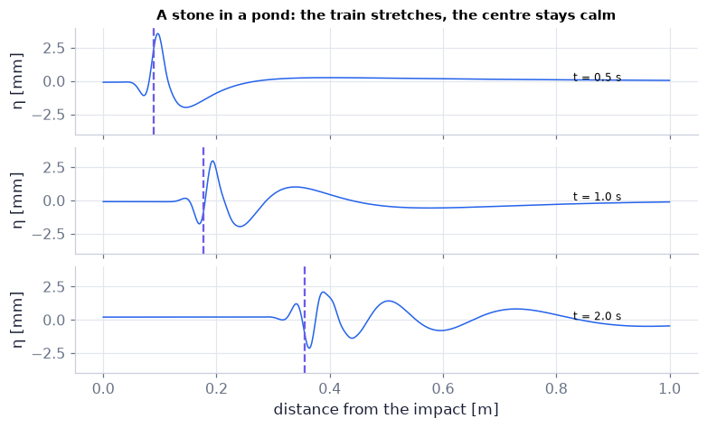

```python
xs_ = np.linspace(0, 1.0, 1000)                            # distance from the stone [m]
cgmin = ch07.min_group_velocity(0.07274, 998.2)["cg_min"]  # [m/s]
fig, axs = plt.subplots(3, 1, figsize=(7, 4.2), sharex=True)   # three times, stacked
for axp, t in zip(axs, (0.5, 1.0, 2.0)):                   # times after the impact [s]
    axp.plot(xs_, 1e3*ch07.pond_ripples(xs_, t, width=0.01, a=0.01, rho=998.2, sigma=0.07274), color=COLORS["blue"], lw=1)   # the train at time t, in mm
    axp.axvline(cgmin*t, color=COLORS["accent"], ls="--", lw=1.5)   # calm-centre edge
    axp.text(0.8, 0.5, f"t = {t} s", transform=axp.transAxes, fontsize=8); axp.set_ylabel("η [mm]")   # time label and unit
    axp.set_ylim(-4, 4)   # same scale in every panel
axs[-1].set_xlabel("distance from the impact [m]")   # shared x label
axs[0].set_title("A stone in a pond: the train stretches, the centre stays calm", fontsize=10)   # the message
savefig(fig, "ch07", "c09_pond"); plt.show()   # save, then draw
```

**What you see.** The ripple train from a released 1 cm hump at 0.5, 1 and 2 s (our remake of Fig. 7.16 `N182`); the purple dashed line is at $c_{g,min}t$.

**How to read it.** The longest waves lead; inside the dashed line the surface stays flat — its edge moves at the minimum group velocity (0.1776 m/s, printed two cells above), not at the minimum phase speed $c_{min}=23.1$ cm/s of C07.

**What would change if…** …σ = 0 (no surface tension): no minimum group velocity, and ever shorter waves fill the centre.

📝 **Note.** **Following one crest** `N73` — in a deep-water group: it runs from the rear to the front at twice the group speed, its wavelength grows as it goes, and it dies at the front while new crests are born at the rear (seen in the A2 animation and in the explainer).

#### 🎮 Interactive: Where does a wave's energy go?

**Why interactive rather than a static figure:** Follow one crest with a marker while the envelope moves at half its speed; switch the dispersion to shallow or capillary and see $c_g=c$ or $c_g>c$; the chord and tangent of ω(k) move with the dot. Crests passing through a group can only be seen moving.

**What to try:**

- Play the *swell set*: count how many crests pass through one group.
- Choose *shallow*: the packet keeps its shape — no dispersion.
- Choose *capillary*: crests now appear at the front and vanish at the back.
- Open the Derivation (D20) and toggle the dropped ω″ term: the packet spreads.

```python
show_viz("ch07", "group_velocity_packets")   # full-width explainer; ⤢ Full screen for more room
```

🎮 Interactive 4/9 Where does a wave's energy go? Open alone ↗

[interactive chart not shown]

> ⚠️ **Common confusion:** "the wave speed" is two speeds. $c=\omega/k$ is how fast crests move; $c_g=d\omega/dk$ is how fast the envelope, the energy and any signal move. For deep-water gravity waves $c_g=c/2$; for capillary waves $c_g=3c/2$; only non-dispersive waves (shallow water, sound) have $c_g=c$.

**What would change if…** …the medium changed slowly along the way (depth decreasing toward a beach)? k and ω can no longer both stay constant: C10 shows that ω is the one that is carried unchanged along a path moving at $c_g$.

### 🧩 Kinematic wave theory, rays and refraction `C10`

*The question:* How do the wavenumber and the frequency of a wave train change when the depth changes slowly — and why do waves turn toward the shore?

*In one line:* $\frac{\partial\omega}{\partial t}+c_g\frac{\partial\omega}{\partial x}=0$ *(7.79)*

#### The problem in plain words

Walk along a beach on any day: the breakers arrive nearly parallel to the shore, whatever direction the wind blew offshore. Waves round an island even bend toward its sides. We want the rules that carry a wave train's wavelength, frequency and direction across slowly changing depth — **ray theory**, also called **WKB theory** (after Wentzel, Kramers and Brillouin): the approximation for a medium that changes little over one wavelength, so that locally the wave looks like a plain sinusoid whose k and ω drift slowly. D22–D23 below are an example of it, and Ch. 13 uses the same theory for internal and planetary waves.

#### The idea

```
phase θ(x,t):  k = ∂θ/∂x (crests per metre),  ω = −∂θ/∂t (crests per second passing a point)
crests are conserved  ⇒  ∂k/∂t + ∂ω/∂x = 0
uniform depth:  k is carried at c_g (rays are straight lines in the x–t plane)
depth H(x):     ω is carried at c_g, k changes;  the shoreward end of a crest slows  ⇒  the crest turns
```

📝 **Note.** **Local wavenumber and frequency** `N74, N75` — A slowly varying train $\eta=a(x,t)\cos[\theta(x,t)]$ *(7.72)* has a local wavenumber and frequency $k\equiv\partial\theta/\partial x,\ \omega\equiv-\partial\theta/\partial t$ *(7.73)* (for θ = kx − ωt they are the usual k and ω). The code differentiates a chirped phase θ = 0.5x + 0.002x² − 2t numerically: k = 0.54 rad/m at x = 10 m, ω = 2 rad/s.

```python
theta = lambda x, t: 0.5*x + 0.002*x**2 - 2.0*t           # a chirped wave train's phase [rad]
print(ch07.local_wavenumber_frequency(theta, 10.0, 0.0))  # (7.73): (k [rad/m], ω [rad/s]) at x = 10 m, t = 0
```

```
(0.5399999999999849, 2.0000000000086615)
```

> 📎 **Primer — first-order wave equation and characteristics.** `P174` · The equation ∂q/∂t + c ∂q/∂x = 0 says q does not change for an observer moving at speed c: along each line dx/dt = c in the x–t plane (a characteristic) q is constant. It is the material derivative of Ch. 3 with the velocity replaced by c.

```python
import numpy as np                                # numbers
q0 = lambda x: np.exp(-x**2)                      # a bump at t = 0
c, t = 2.0, 3.0                                   # speed [m/s] and time [s]
q = lambda x, t: q0(x - c*t)                      # the solution: the bump shifted by ct
print(q(6.0, 3.0), q0(0.0))                       # 1.0 1.0 — the value rode along x = ct
```

```
1.0 1.0
```

> 🔁 **Tools from earlier chapters used here** (see `knowledge/primers.md`)
- **mixed partial derivatives commute** — $\partial^2\theta/\partial t\,\partial x=\partial^2\theta/\partial x\,\partial t$ for smooth θ — Schwarz's theorem (Ch. 4 P121).
- **chain rule along a path** — ω depends on x only through k, so ∂ω/∂x = (dω/dk)(∂k/∂x) (Ch. 3 P91).

#### 🧮 Derivation — Crest conservation and k carried at c_g `D22` (Eq. 7.75: $\frac{\partial k}{\partial t}+c_g\frac{\partial k}{\partial x}=0$)

**What we want to show.** Show that crests are conserved and that the local wavenumber is carried at the group velocity.

**Assumptions.** Slowly varying train (each piece obeys the uniform-medium ω(k)) from step 5; homogeneous medium.

**The plan.**

1. Define local k and ω from the phase.
2. Cross-differentiate.
3. Use the local dispersion relation.
4. Read the result along characteristics.

**Tools we use** (each explained before this point): mixed partials commute (P121) · chain rule (P91) · first-order wave equation and characteristics (P174).

**We start from**

$$ \eta=a(x,t)\cos[\theta(x,t)]\ \text{(7.72)} $$

*In words:* a wave train whose amplitude and wavelength change slowly.

**Step 1 of 8 — Write a slowly varying train.**

$$ \eta=a(x,t)\cos[\theta(x,t)]\ \text{(7.72)} $$

- *Why we can do this:* Amplitude and wavelength change little over one wavelength and one period; a uniform train has θ = kx − ωt.
- *In words:* a wave whose properties drift slowly.

**Step 2 of 8 — Define local k and ω.**

$$ k\equiv\frac{\partial\theta}{\partial x},\qquad\omega\equiv-\frac{\partial\theta}{\partial t}\ \text{(7.73)} $$

- *Why we can do this:* For θ = kx − ωt these return the usual k and ω; in general they are the local rates of change of phase.
- *In words:* crests per metre and crests per second, measured locally.

**Step 3 of 8 — Cross-differentiate.**

$$ \frac{\partial k}{\partial t}=\frac{\partial^2\theta}{\partial t\,\partial x}=\frac{\partial^2\theta}{\partial x\, \partial t}=-\frac{\partial\omega}{\partial x} $$

- *Why we can do this:* θ is smooth, so mixed partial derivatives commute (Schwarz, P121).
- *In words:* the time change of k is minus the space change of ω.

**Step 4 of 8 — Write it as a conservation law.**

$$ \frac{\partial k}{\partial t}+\frac{\partial\omega}{\partial x}=0\ \text{(7.74)} $$

- *Why we can do this:* It has the form of a continuity equation with density k (crests per metre) and flux ω (crests per second).
- *In words:* crests are neither created nor destroyed.

**Step 5 of 8 — Use the local dispersion relation.**

$$ \omega(x,t)=\omega\big(k(x,t)\big) $$

- *Why we can do this:* In a homogeneous medium each short stretch of a slowly varying train obeys the same ω(k) as a uniform wave.
- *In words:* frequency follows the local wavenumber.

**Step 6 of 8 — Apply the chain rule.**

$$ \frac{\partial\omega}{\partial x}=\frac{d\omega}{dk}\frac{\partial k}{\partial x}=c_g\frac{\partial k}{\partial x} $$

- *Why we can do this:* ω depends on x only through k (P91); dω/dk = c_g (7.67), $c_g=\Delta\omega/\Delta k=d\omega/dk$.
- *In words:* ω changes in space because k does.

**Step 7 of 8 — Substitute.**

$$ \frac{\partial k}{\partial t}+c_g\frac{\partial k}{\partial x}=0\ \text{(7.75)} $$

- *Why we can do this:* Substitute step 6 into crest conservation (7.74), $\partial k/\partial t+\partial\omega/\partial x=0$ ∂k/∂t + ∂ω/∂x = 0; only k is left as unknown.
- *In words:* k obeys a first-order wave equation with speed c_g.

**Step 8 of 8 — Read along characteristics.**

$$ \frac{dk}{dt}=0\ \text{along}\ \frac{dx}{dt}=c_g $$

- *Why we can do this:* P174: ∂q/∂t + c ∂q/∂x = 0 keeps q constant along dx/dt = c; here q = k and c = c_g, so ω(k) is constant too.
- *In words:* an observer moving at c_g always sees the same wavelength.

**Result**

$$ \partial k/\partial t+\partial\omega/\partial x=0\ \text{(7.74),}\ \partial k/\partial t+c_g\,\partial k/\partial x=0 $$

**What it means.** The group velocity is the speed at which wavenumbers (and, as D23 shows, frequencies) are advected — the kinematic basis of ray tracing.

**Check it.** A chirped train θ = 0.5x + 0.002x² − 2t satisfies (7.74), $\partial k/\partial t+\partial\omega/\partial x=0$ to 1e-9 (the code cell after the tiny example of C10) ✓. The FFT packet's x–t diagram shows k constant along lines of slope c_g ✓.

> ⚠️ **Common confusion (traps in `D22`):** k is constant along dx/dt = c_g, not along dx/dt = c; the local dispersion relation is an assumption about slow variation.

📝 **Note.** **Wavenumbers ride at the group velocity** `N76, N77` — Crest conservation $\partial k/\partial t+\partial\omega/\partial x=0$ *(7.74)* and, with a dispersion relation, $\frac{\partial k}{\partial t}+c_g\frac{\partial k}{\partial x}=0$ *(7.75)*: **wavenumbers are carried at the group velocity** — an observer moving at $c_g$ always sees the same wavelength. The x–t diagram below (our remake of Fig. 7.17 `N183`) uses the FFT packet of C09.

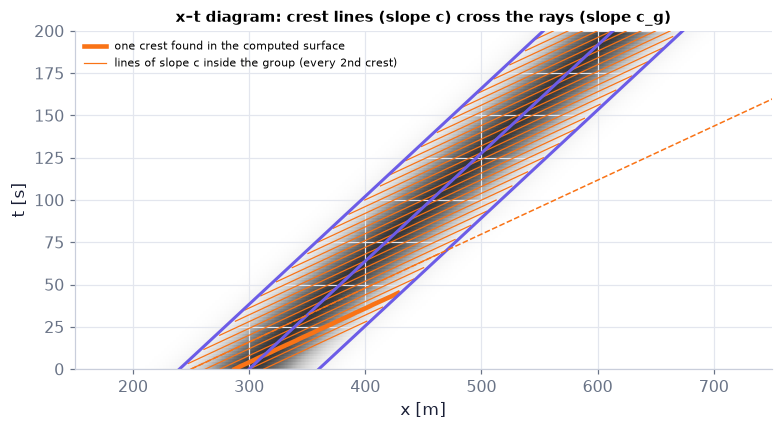

```python
tq = np.linspace(0, 200, 121 if not FAST else 61)          # times [s]
run = ch07.linear_evolve(eta0, xp, tq, direction=+1, H=np.inf)   # the C09 packet, now at many times
sel = (xp > 150) & (xp < 750)                              # the part of the domain the packet visits [m]
fig, ax = plt.subplots(figsize=(7, 3.8))                   # x–t diagram
env_xt = ch07.envelope(run, axis=-1)                       # the packet's envelope at every time [m]
ax.pcolormesh(xp[sel], tq, env_xt[:, sel], cmap="Greys", shading="auto", vmin=0, vmax=1.2)   # the group (grey band)
c0, cg0 = ch07.phase_speed(1.0), ch07.group_velocity(1.0)  # 3.13 and 1.57 m/s
crest_x, crest_t = [], []                                  # one crest followed through the group
x_prev, lost = None, False                                 # its position at the previous time [m]; True once it has faded
for j, t_ in enumerate(tq):                                # crest positions at each time: local maxima inside the group
    e = run[j]
    ic = np.nonzero((e[1:-1] > e[:-2]) & (e[1:-1] >= e[2:]) & (e[1:-1] > 0.15))[0] + 1   # local maxima (P180)
    if ic.size and not lost:                               # follow the crest that starts about 12 m behind the centre
        guess = 288.0 if x_prev is None else x_prev + c0*(tq[1] - tq[0])   # where it should be now: it moves at c [m]
        jn = ic[np.argmin(np.abs(xp[ic] - guess))]         # the nearest crest
        if abs(xp[jn] - guess) < 2.0:                      # still the same crest
            crest_x.append(xp[jn]); crest_t.append(t_); x_prev = xp[jn]   # record it
        else:
            lost = True                                    # it has faded at the front of the group: stop following
    elif ic.size == 0 and x_prev is not None:
        lost = True                                        # no crest left above the threshold
for n_ in range(-2, 64, 2):                                # every 2nd crest of the carrier cos(x − 300): crest at 300 − 2πn at t = 0
    xl = 300 - 2*np.pi*n_ + c0*tq                          # its path if it moves at c [m]
    amp = np.array([np.interp(xl[j], xp, env_xt[j]) for j in range(tq.size)])   # the group's height along that path (P182)
    ax.plot(np.where(amp > 0.15, xl, np.nan), tq, color=COLORS["orange"], lw=0.8)   # drawn only while inside the group
ax.plot(crest_x, crest_t, color=COLORS["orange"], lw=3, label="one crest found in the computed surface")   # one crest's whole life
ax.plot([], [], color=COLORS["orange"], lw=0.8, label="lines of slope c inside the group (every 2nd crest)")   # legend entry
for x0 in (240, 300, 360):                                 # rays: lines of slope c_g (purple)
    ax.plot(x0 + cg0*tq, tq, color=COLORS["accent"], lw=2)
ax.plot(250 + c0*tq, tq, color=COLORS["orange"], lw=1, ls="--")   # a guide of slope c for comparison
ax.set_xlim(150, 750); ax.set_ylim(0, 200); ax.set_xlabel("x [m]"); ax.set_ylabel("t [s]")
ax.legend(fontsize=7, loc="upper left")                   # the followed crest
ax.set_title("x–t diagram: crest lines (slope c) cross the rays (slope c_g)", fontsize=10)
savefig(fig, "ch07", "c10_xt_diagram"); plt.show()
```

**What you see.** The packet is the grey band. The thick orange line is one crest found in the computed surface (local maxima, time level by time level) from near the rear of the group until it fades at the front; the thin orange segments are lines of slope c drawn through every second crest, only where the group is present. All are flatter than the band (speed c = 3.13 m/s, like the dashed guide), so crests enter at the rear of the band and leave at its front, where they fade. The band itself follows the thick purple rays (speed $c_g=1.57$ m/s) and widens slowly with time.

**How to read it.** Along a purple line the wavenumber and frequency stay fixed; along an orange line a crest keeps its phase and ends when it leaves the band at the front.

**What would change if…** …shallow water: both families have the same slope — crests and groups move together.

📝 **Note.** **A slowly varying depth** `N78–N80` — In slowly varying depth $\omega=\sqrt{gk\tanh[kH(x)]}$ has the form $\omega=\omega(k,x)$ *(7.76)*, a local group velocity is $\partial\omega(k,x)/\partial k=c_g$ *(7.77)*, and multiplying by ∂k/∂t gives $c_g\frac{\partial k}{\partial t}=\frac {\partial\omega}{\partial t}$ *(7.78)*.

#### 🧮 Derivation — Frequency is constant along rays `D23` (Eq. 7.79: $\frac{\partial\omega}{\partial t}+c_g\frac{\partial\omega}{\partial x}=0$)

**What we want to show.** Let the depth change slowly with x and show that ω — not k — is carried unchanged at c_g.

**Assumptions.** Steady medium (H does not change in time); slowly varying depth.

**The plan.**

1. Write ω(k, x).
2. Differentiate ω in time at fixed x.
3. Multiply (7.74), $\partial k/\partial t+\partial\omega/\partial x=0$ by c_g and substitute.
4. Add the companion equation for k.

**Tools we use** (each explained before this point): chain rule with a variable held fixed (P39, P91) · characteristics (P174).

**We start from**

$$ \frac{\partial k}{\partial t}+\frac{\partial\omega}{\partial x}=0\ \text{(7.74) and}\ \omega=\sqrt{gk\tanh[kH(x)]}\ \text{.} $$

**Step 1 of 8 — Let the depth vary with x.**

$$ \omega=\omega(k,x)\ \text{(7.76)} $$

- *Why we can do this:* With H = H(x), the local dispersion relation ω = √(gk tanh kH(x)) depends on x directly as well as through k.
- *In words:* frequency depends on the wavenumber and on where you are.

**Step 2 of 8 — Define the local group velocity.**

$$ \frac{\partial\omega(k,x)}{\partial k}=c_g\ \text{(7.77)} $$

- *Why we can do this:* The slope of ω against k at a fixed position (P39: derivative with x held fixed).
- *In words:* the group velocity of the local medium.

**Step 3 of 8 — Differentiate ω in time at fixed x.**

$$ \frac{\partial\omega}{\partial t}=\Big(\frac{\partial\omega}{\partial k}\Big)_x \frac{\partial k}{\partial t} $$

- *Why we can do this:* Chain rule; at fixed x the medium does not change in time, so ω changes only through k.
- *In words:* the local frequency changes only if the local wavenumber does.

**Step 4 of 8 — Recognise c_g.**

$$ c_g\frac{\partial k}{\partial t}=\frac{\partial\omega}{\partial t}\ \text{(7.78)} $$

- *Why we can do this:* At fixed x the slope (∂ω/∂k)_x is the local group velocity c_g of (7.77), $\partial\omega(k,x)/\partial k=c_g$, so step 3 reads c_g ∂k/∂t.
- *In words:* the book's (7.78), $c_g\frac{\partial k}{\partial t}=\frac{\partial\omega}{\partial t}$.

**Step 5 of 8 — Multiply crest conservation by c_g.**

$$ c_g\frac{\partial k}{\partial t}+c_g\frac{\partial\omega}{\partial x}=0 $$

- *Why we can do this:* (7.74), $\partial k/\partial t+\partial\omega/\partial x=0$ times c_g — not c — to create the combination of step 4.
- *In words:* prepare to substitute.

**Step 6 of 8 — Substitute (7.78).**

$$ \frac{\partial\omega}{\partial t}+c_g\frac{\partial\omega}{\partial x}=0\ \text{(7.79)} $$

- *Why we can do this:* Use (7.78) c_g ∂k/∂t = ∂ω/∂t to replace the first term; the equation then contains ω only.
- *In words:* ω obeys a first-order wave equation with speed c_g.

**Step 7 of 8 — Read along rays.**

$$ \frac{d\omega}{dt}=0\ \text{along}\ \frac{dx}{dt}=c_g;\qquad\frac{\partial\omega}{\partial t}+\mathbf c_g\cdot \nabla\omega=0 $$

- *Why we can do this:* Characteristics (P174); the book states the 3-D form.
- *In words:* frequency is conserved along rays while k, c and c_g change.

**Step 8 of 8 — Add the companion equation (ours).**

$$ \frac{dk}{dt}=-\Big(\frac{\partial\omega}{\partial x}\Big)_k\ \text{along}\ \frac{dx}{dt}=c_g $$

- *Why we can do this:* In (7.74), $\partial k/\partial t+\partial\omega/\partial x=0$ write ∂ω/∂x = c_g∂k/∂x + (∂ω/∂x)_k; the first part joins ∂k/∂t. k changes where the medium changes — this bends rays (D24).
- *In words:* the wavenumber changes along a ray as the depth changes.

**Result**

$$ \begin{array}{l}\frac{\partial\omega}{\partial t}+c_g\frac{\partial\omega}{\partial x}=0\ \text{(7.79), with the ray equations}\ \frac{dx}{dt}= \frac{\partial\omega}{\partial k}\ \text{,} \\ \frac{dk}{dt}=-\frac{\partial\omega}{\partial x}\ \text{.}\end{array} $$

**What it means.** In a steady medium the period of a wave never changes on its way; wavelength and direction do. This is the ray (WKB) theory Ch. 13 uses for internal waves in N(z) and for Rossby waves.

**Check it.** `ray_trace` over a 1:50 beach conserves ω to < 1e-8 relative while k grows from 0.071 to 0.181 rad/m ✓.

> ⚠️ **Common confusion (traps in `D23`):** Multiplying (7.74), $\partial k/\partial t+\partial\omega/\partial x=0$ by c instead of c_g; assuming k is conserved in an inhomogeneous medium; forgetting the medium must be steady (a changing tide breaks ω-conservation).

> 📎 **Primer — Snell's law for waves.** `P175` · When a wave crosses a medium whose properties change only in one direction (say x), the wavenumber component along the other direction (y) cannot change: the crests must match along every line of constant x. With |k| changing, the angle α between k and the x-direction obeys |k| sin α = constant — the optics rule n₁ sin α₁ = n₂ sin α₂.

```python
import numpy as np                                # numbers
k1, a1 = 0.07, np.radians(30)                     # offshore wavenumber [rad/m] and angle
k2 = 0.18                                         # a larger k closer to shore (shallower water) [rad/m]
print(np.degrees(np.arcsin(k1*np.sin(a1)/k2)))    # 11.2° — the crest has turned toward the shore
```

```
11.212271417649696
```

#### 🧮 Derivation — Refraction on a plane beach: $k\sin\alpha=\text{const}$ (Snell) `D24`

**What we want to show.** Show why crests arriving at an angle turn parallel to the shore. (The book gives the argument in words only; we write it out.)

**Assumptions.** Straight, parallel depth contours (H = H(x)); slowly varying depth; steady medium.

**The plan.**

1. Write 2-D rays.
2. Use straight contours: k_y is conserved.
3. ω is conserved: |k| grows as H falls.
4. Combine into Snell's law.

**Tools we use** (each explained before this point): ray equations (D23 step 8) · Snell's law for waves (P175) · dispersion relation (7.28), $\omega=\sqrt{gk\tanh kH}$.

**We start from**

$$ \text{The ray equations of D23 in two dimensions, with depth H(x) on a plane beach.} $$

**Step 1 of 9 — Write the 2-D ray equations.**

$$ \frac{d\mathbf x}{dt}=\nabla_{\mathbf k}\omega,\qquad\frac{d\mathbf k}{dt}=-\nabla_{\mathbf x}\omega $$

- *Why we can do this:* D23 steps 7–8 in two dimensions with ω = ω(|k|, H(x, y)) (our extension of (7.79), $\frac{\partial\omega}{\partial t}+c_g\frac{\partial\omega}{\partial x}=0$: Hamilton's equations for rays — the same pair as Hamilton's equations of mechanics, $dx/dt=\partial\mathcal H/\partial p$, $dp/dt=-\partial\mathcal H/\partial x$, with the ray's point x as the position, the wavenumber k as the momentum and ω as the energy, the Hamiltonian $\mathcal H$ (a script letter, not the depth H)).
- *In words:* a ray moves at c_g, and its wavenumber changes where the medium changes.

**Step 2 of 9 — Use straight depth contours.**

$$ H=H(x)\ \Rightarrow\ \frac{\partial\omega}{\partial y}=0 $$

- *Why we can do this:* On a plane beach the depth changes only with distance x from the shoreline.
- *In words:* nothing changes along the shore.

**Step 3 of 9 — Conclude k_y is conserved.**

$$ \frac{dk_y}{dt}=0\ \Rightarrow\ k_y=\text{const} $$

- *Why we can do this:* The y-component of the second ray equation with ∂ω/∂y = 0.
- *In words:* the along-shore wavenumber never changes.

**Step 4 of 9 — Recall ω is conserved.**

$$ \omega=\text{const along the ray} $$

- *Why we can do this:* (7.79), $\frac{\partial\omega}{\partial t}+c_g\frac{\partial\omega}{\partial x}=0$: the medium is steady (D23).
- *In words:* the period stays the same all the way in.

**Step 5 of 9 — Get |k| from the local depth.**

$$ \omega^2=g\lvert\mathbf k\rvert\tanh(\lvert\mathbf k\rvert H(x)) $$

- *Why we can do this:* (7.28), $\omega=\sqrt{gk\tanh kH}$ with ω fixed: as H falls, tanh(|k|H) falls, so |k| must rise to keep ω (C03's `wavenumber_from_omega`).
- *In words:* the wave shortens as the water shallows.

**Step 6 of 9 — Define the angle to the shore normal.**

$$ k_y=\lvert\mathbf k\rvert\sin\alpha $$

- *Why we can do this:* α is measured between k and the x-axis, the normal to the shoreline and the contours.
- *In words:* α = 0 means crests parallel to the shore.

**Step 7 of 9 — Combine.**

$$ \lvert\mathbf k\rvert\sin\alpha=\lvert\mathbf k_0\rvert\sin\alpha_0 $$

- *Why we can do this:* Steps 3 and 6: the product is the conserved k_y (P175).
- *In words:* Snell's law for water waves.

**Step 8 of 9 — Solve for α.**

$$ \sin\alpha=\frac{\lvert\mathbf k_0\rvert\sin\alpha_0}{\lvert\mathbf k(x)\rvert} $$

- *Why we can do this:* Divide by |k| > 0; |k| grows toward the shore (step 5), so sin α shrinks.
- *In words:* the ray turns toward the shore normal.

**Step 9 of 9 — Take the shallow limit.**

$$ \lvert\mathbf k\rvert\approx\frac{\omega}{\sqrt{gH}}\to\infty\ \text{as}\ H\to0\ \Rightarrow\ \alpha\to0 $$

- *Why we can do this:* (7.49): c = ω/|k| = √(gH) → 0 at the shoreline.
- *In words:* crests end up parallel to the depth contours.

**Result**

$$ \lvert\mathbf k\rvert\sin\alpha=\text{const}\ \text{along a ray on a plane beach; α → 0 at the shore.} $$

**What it means.** Refraction is why breakers line up with beaches and why energy focuses on headlands and over ridges; the same law bends light (optics) and sound.

**Check it.** T = 8 s, 30° at 20 m → 11.3° at 2 m ✓ (worked example); the RK4 ray and the closed form agree to 1e-6 ✓.

> ⚠️ **Common confusion (traps in `D24`):** Conserving k instead of ω along the ray; measuring α from the shoreline instead of its normal; forgetting that the law needs straight contours (an island needs the full ray equations).

📝 **Note.** **Refraction on a beach and round an island** `N47, N48` — On a sloping beach (the book's Fig. 7.8) ω is fixed along the path, while $c=\sqrt{gH}$ and λ shrink as H falls, so $k\sin\alpha$ constant (D24) forces α toward zero — crests end up parallel to the depth contours. Round a circular island with a gently sloping beach (Fig. 7.9) the same bending brings crests onto the shadow side too — optics' lens, made of water depth.

#### ✏️ Tiny example: swell turning on a 1:50 beach

T = 8 s, arriving at 30° to the shore normal in 20 m of water.

1. $\omega=2\pi/8=0.785$ rad/s (fixed along the ray).
2. At H = 20 m solve (7.28), $\omega=\sqrt{gk\tanh kH}$: k = 0.0708 rad/m (λ = 88.8 m).
3. At H = 2 m: k = 0.181 rad/m (λ = 34.7 m).
4. Snell: $\sin\alpha_2=0.0708\times\sin30°/0.181=0.195$ → α₂ = 11.3°.
5. The crest turned by almost 19° while crossing 900 m of beach (from 20 m to 2 m depth on a 1:50 slope).

> 🔁 **Tools from earlier chapters used here** (see `knowledge/primers.md`)
- **np.arcsin, np.radians, np.degrees** — inverse sine in radians, and conversions degrees ↔ radians (numpy works in radians; Ch. 2 P66).

```python
print(ch07.crest_conservation_residual(theta, 10.0, 0.0))          # (7.74) for the chirp: residual ≈ 1e-10
r = ch07.snell_ray_plane_beach(np.linspace(1000, 100, 10), np.radians(30), 1000.0, 8.0, 0.02)   # T = 8 s, 30°, slope 1:50
print("α along the ray [deg]:", np.round(np.degrees(r["alpha"]), 2))
print("k sin α [rad/m]:", r["snell"])                              # Snell's invariant: constant
s = ch07.refraction_state(8.0, np.radians(30), 20.0, 2.0)          # one point: H₀ = 20 m → H = 2 m
print(f"at H = 2 m: α = {s['alpha_deg']:.2f}°, λ = {s['lam']:.1f} m")
ray = ch07.ray_trace(None, (1000.0, 0.0), (-0.0708*np.cos(np.radians(30)), 0.0708*np.sin(np.radians(30))), (0, 250),
                     H_fn=lambda X: 0.02*X[0])                     # Hamilton's ray equations over the same beach
print("relative drift of ω along the traced ray:", ray["omega_drift"])
```

```
{'k': 0.5399999999995408, 'omega': 1.9999999999995577, 'r774': 4.93679171616653e-11}
α along the ray [deg]: [30.   29.1  28.03 26.77 25.28 23.53 21.44 18.89 15.68 11.27]
k sin α [rad/m]: [0.0354 0.0354 0.0354 0.0354 0.0354 0.0354 0.0354 0.0354 0.0354 0.0354]
at H = 2 m: α = 11.27°, λ = 34.7 m
```

```
relative drift of ω along the traced ray: 2.001124095970369e-09
```

**What does the code above do?**

1. The chirp satisfies crest conservation to about $10^{-10}$ — it holds for any smooth phase.
2. `snell_ray_plane_beach` fixes ω = 2π/8 along the ray, gets k(x) from (7.28), $\omega=\sqrt{gk\tanh kH}$ with `brentq` and α from Snell's law: α falls from 30° at 20 m depth to 11.3° at 2 m, while k sin α stays 0.03538 rad/m.
3. `ray_trace` integrates the ray equations $d\mathbf x/dt=\nabla_{\mathbf k}\omega$, $d\mathbf k/dt=-\nabla_{\mathbf x} \omega$ (D23 step 8, D24 step 1) with `solve_ivp`: ω drifts by $2\times10^{-9}$ relative over the whole beach (7.79), $\frac{\partial\omega}{\partial t}+c_g\frac{\partial\omega}{\partial x}=0$.

```python
wf = lambda kx, ky, x: np.sqrt(G*np.hypot(kx, ky)*np.tanh(np.hypot(kx, ky)*0.02*x))   # ω(k, x) on the 1:50 beach [rad/s]
def rhs(y):                                                # Hamilton's ray equations: y = (x, y, kx, ky)
    x, yy, kx, ky = y
    hk, hx = 1e-7, 1e-2                                    # difference steps in k [rad/m] and x [m]
    dwdkx = (wf(kx + hk, ky, x) - wf(kx - hk, ky, x))/(2*hk)   # ∂ω/∂k_x = c_g,x
    dwdky = (wf(kx, ky + hk, x) - wf(kx, ky - hk, x))/(2*hk)   # ∂ω/∂k_y = c_g,y
    dwdx = (wf(kx, ky, x + hx) - wf(kx, ky, x - hx))/(2*hx)    # ∂ω/∂x (the depth changes with x)
    return np.array([dwdkx, dwdky, -dwdx, 0.0])            # dx/dt, dy/dt, dk_x/dt, dk_y/dt
k0 = ch07.wavenumber_from_omega(2*np.pi/8, 20.0)           # start: T = 8 s at H = 20 m [rad/m]
y = np.array([1000.0, 0.0, -k0*np.cos(np.radians(30)), k0*np.sin(np.radians(30))])   # heading shoreward at 30°
dt = 0.5                                                   # RK4 step [s]
while y[0] > 110.0:                                        # march until H ≈ 2.2 m
    s1 = rhs(y); s2 = rhs(y + dt/2*s1); s3 = rhs(y + dt/2*s2); s4 = rhs(y + dt*s3)   # RK4 (P95)
    y = y + dt*(s1 + 2*s2 + 2*s3 + s4)/6
alpha_mine = np.arcsin(y[3]/np.hypot(y[2], y[3]))          # angle to the shore normal at the end [rad]
r_alpha = float(np.ravel(ch07.snell_ray_plane_beach(np.array([y[0]]), np.radians(30), 1000.0, 8.0, 0.02)["alpha"])[0])   # closed form there
print(f"x = {y[0]:.1f} m: our α = {np.degrees(alpha_mine):.6f}°, Snell {np.degrees(r_alpha):.6f}°;",
      f"ω drift {abs(wf(y[2], y[3], y[0])/(2*np.pi/8) - 1):.1e}")
assert np.allclose(alpha_mine, r_alpha, rtol=1e-6)         # our RK4 ray bends exactly as Snell's law says
```

```
x = 108.6 m: our α = 11.722131°, Snell 11.722131°; ω drift 3.0e-10
```

```
(b) rays that wrap round onto the lee (east) half of the island: 2
```

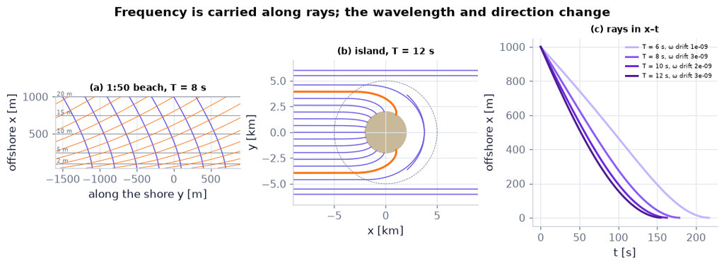

```python
fig, axs = plt.subplots(1, 3, figsize=(10, 3.6))           # beach | island | x–t
# (a) plane beach, 1:50, rays from 1000 m offshore at 30°
xr = np.linspace(1000, 40, 60)                             # offshore distance along the ray [m]
ray0 = ch07.snell_ray_plane_beach(xr, np.radians(30), 1000.0, 8.0, 0.02)   # one ray (the others are shifted copies)
for y0 in np.linspace(-1500, 300, 7):                      # seven rays, shifted along the shore [m]
    axs[0].plot(y0 + ray0["y"], xr, color=COLORS["accent"], lw=1)
for H in (2, 5, 10, 15, 20):                               # depth contours [m]
    axs[0].axhline(H/0.02, color=COLORS["muted"], lw=0.5); axs[0].text(-1580, H/0.02 + 10, f"{H} m", fontsize=6, color=COLORS["muted"])
yy = np.linspace(-1600, 900, 250)                          # along-shore coordinate [m]
k_x = np.sqrt(ray0["k"]**2 - ray0["l"]**2)                 # shoreward wavenumber component on the ray [rad/m]
phase_x = np.concatenate([[0.0], np.cumsum(0.5*(k_x[1:] + k_x[:-1])*(xr[:-1] - xr[1:]))])   # ∫k_x dx toward the shore
PH = ray0["l"]*yy[None, :] + phase_x[:, None]              # phase θ = l y + ∫k_x dx on the grid
lv0 = 4*np.pi*np.floor(PH.min()/(4*np.pi))                 # the first crest level below the smallest phase
axs[0].contour(yy, xr, PH, levels=np.arange(lv0, PH.max(), 4*np.pi), colors=[COLORS["orange"]], linewidths=0.6)   # every 2nd crest
axs[0].set_aspect("equal"); axs[0].set_xlim(-1600, 900); axs[0].set_ylim(40, 1000)   # true angles
axs[0].set_xlabel("along the shore y [m]"); axs[0].set_ylabel("offshore x [m]"); axs[0].set_title("(a) 1:50 beach, T = 8 s", fontsize=9)
# (b) circular island: H rises from 0 at r = 2 km to 30 m at r = 5 km (our bathymetry)
R0 = 2000.0                                                # island radius [m]
Hf = lambda X: float(np.clip(30*(np.hypot(X[0], X[1]) - R0)/3000.0, 0.0, 30.0))   # depth [m]
kI = ch07.wavenumber_from_omega(2*np.pi/12, 30.0)          # T = 12 s on 30 m [rad/m]
th_ = np.linspace(0, 2*np.pi, 200); axs[1].fill(R0*np.cos(th_)/1e3, R0*np.sin(th_)/1e3, color="#c8b99a")
axs[1].plot((R0 + 3000)*np.cos(th_)/1e3, (R0 + 3000)*np.sin(th_)/1e3, color=COLORS["muted"], lw=0.5, ls="--")
n_lee = 0                                                  # rays that land on the island's east (lee) half
y_start = np.concatenate([[-6000, -5500], np.linspace(-4600, 4600, 15 if not FAST else 9), [5500, 6000]])   # across the shelf, plus 2 beyond its edge on each side [m]
for yI in y_start:                                         # parallel rays from the west
    rI = ch07.ray_trace(None, (-9000.0, yI), (kI, 0.0), (0, 1800), H_fn=Hf, n_out=300)   # ray equations (stop at H ≈ 0)
    xe, ye = rI["x"][0][-1], rI["x"][1][-1]                # where the ray ends [m]
    lee = np.hypot(xe, ye) < R0 + 50 and xe > 0            # it reached the shore on the side facing away from the swell
    n_lee += lee                                           # count it
    axs[1].plot(rI["x"][0]/1e3, rI["x"][1]/1e3, color=COLORS["orange"] if lee else COLORS["accent"], lw=2 if lee else 1)
print(f"(b) rays that wrap round onto the lee (east) half of the island: {n_lee}")
axs[1].set_aspect("equal"); axs[1].set_xlim(-9, 9); axs[1].set_ylim(-7, 7)
axs[1].set_xlabel("x [km]"); axs[1].set_ylabel("y [km]"); axs[1].set_title("(b) island, T = 12 s", fontsize=9)
# (c) x–t of four rays straight onto the beach, different periods
for T_, cl in zip((6.0, 8.0, 10.0, 12.0), ("#c4b5fd", "#8b5cf6", "#6d28d9", "#4c1d95")):
    kT = ch07.wavenumber_from_omega(2*np.pi/T_, 20.0)      # start at 20 m depth [rad/m]
    rT = ch07.ray_trace(None, (1000.0, 0.0), (-kT, 0.0), (0, 600), H_fn=lambda X: 0.02*X[0], n_out=300)
    axs[2].plot(rT["t"], rT["x"][0], color=cl, lw=2, label=f"T = {T_:g} s, ω drift {rT['omega_drift']:.0e}")
axs[2].set_xlabel("t [s]"); axs[2].set_ylabel("offshore x [m]"); axs[2].legend(fontsize=6); axs[2].set_title("(c) rays in x–t", fontsize=9)
fig.suptitle("Frequency is carried along rays; the wavelength and direction change", fontweight="bold")
savefig(fig, "ch07", "c10_refraction"); plt.show()
```

**What you see.** (a) Rays (purple) coming from offshore at 30° bend toward the shore normal as the depth contours (grey) get shallower, and the crest lines (orange) turn parallel to the shore — our remake of Fig. 7.8 `N174`. (b) Parallel rays from the west bending toward a circular island from every side: the central rays land on its west face, the outer ones curve round its north and south points, and the rays launched about 3.5–4.5 km off the axis (thick orange, counted in the printed line) wrap far enough to land on its east, sheltered half — Fig. 7.9 `N175` with our bathymetry. The outermost shelf rays (launched ±4.6 km off the axis, thin purple) bend the most of all: they swing behind the island and cross each other on its east side, but they never come closer than about 3.8 km to the centre, so they never reach the shore and are not counted — the traced 30 minutes end while they are still turning (traced longer, they head back out to sea). The four rays launched at ±5.5 and ±6 km never cross the shelf edge (dashed circle): the depth along them stays 30 m, so they pass by dead straight. (c) Four rays straight onto the beach in the x–t plane: curved, because they slow down as the water shallows, each keeping its ω to about $10^{-9}$ — Fig. 7.18 `N184`.

**How to read it.** Each ray keeps its ω (printed drift); k grows as the depth falls, so the ray bends toward the shallow side. Longer periods (darker) travel faster in deep water and slow down more near the shore.

**What would change if…** …a longer period (T = 14 s): the swell feels the bottom sooner, so the turning starts further offshore.

```python
xr = np.linspace(1000, 40, 40)                             # offshore distance [m]
def rays(a0):                                              # rays over the 1:50 beach for incidence a0 [deg]
    r_ = ch07.snell_ray_plane_beach(xr, np.radians(a0), 1000.0, 8.0, 0.02)   # Snell with (7.28)
    return {f"ray {j}": (y0 + r_["y"], xr) for j, y0 in enumerate(np.linspace(-1500, 300, 4))}   # four rays: shifted copies along the shore
fig = slider_figure(rays, "α₀", np.linspace(0, 60, 13 if not FAST else 7), unit="°", xlabel="along the shore y [m]",   # slider over the incidence angle
                    ylabel="offshore x [m]", title="Rays over a 1:50 beach (T = 8 s): all end nearly normal to the shore",   # labels and message
                    xrange=(-1600, 1400), yrange=(0, 1000))   # fixed axes
recolor(fig, {f"ray {j}": COLORS["accent"] for j in range(4)})   # rays purple (group/energy colour)
fig.show()   # draw (works on the page: no kernel needed)
```

[interactive chart not shown]

**What you see.** Whatever the incidence angle α₀, the rays end nearly perpendicular to the shoreline (the bottom of the plot): refraction straightens them.

**What would change if…** the beach were steeper (1:10): the turning would happen over a fifth of the distance, so the rays would bend more sharply but end at nearly the same angle, set by Snell's law and the final depth.

#### 🎮 Interactive: Why do waves arrive parallel to the beach?

**Why interactive rather than a static figure:** Set the angle and the period and watch rays bend over a beach, a ridge or round an island; the side view prints ω flat along the selected ray while k, c and $c_g$ change. The conservation is seen, not asserted.

**What to try:**

- Preset *swell at 30°*: read α at the 2 m contour (11°).
- Switch to *island*: find a ray that reaches the shadow side.
- Choose *homogeneous*: the rays are straight — nothing to refract.
- Step the Derivation (D23) to 'multiply by c_g'.

```python
show_viz("ch07", "wave_rays_refraction")   # full-width explainer; ⤢ Full screen for more room
```

🎮 Interactive 5/9 Why do waves arrive parallel to the beach? Open alone ↗

[interactive chart not shown]

**What would change if…** …the medium varied in time too (a tide changing the depth)? Then ω is no longer conserved along a ray: dω/dt = ∂ω/∂t at fixed k — the Doppler-like frequency shift used for waves on tidal currents and for internal waves in Ch. 13.

## 7.6 Nonlinear Waves in Shallow and Deep Water

**What is this section about?** Everything so far assumed ka ≪ 1. Now the amplitude matters. In shallow water crests outrun troughs, fronts steepen and break into a hydraulic jump — unless dispersion balances the steepening and a solitary wave travels unchanged. In deep water the crests sharpen (Stokes waves) and the orbits of C05 fail to close: the water drifts forward (Stokes drift).

> 🔁 **Recap — The Froude number** (Ch. 4 §4.11). $\mathrm{Fr}=\frac{U}{\sqrt{gl}}$ *(4.104)* compares a flow speed with the shallow-water wave speed of C04, $c=\sqrt{gH}$ *(7.49)*: Fr > 1 supercritical (waves cannot travel upstream), Fr < 1 subcritical.

```python
print(similarity.froude_number(2.97, 0.1, g=9.81))        # 2.97 m/s in 10 cm of water: Fr ≈ 3, supercritical
```

```
2.9986235374361443
```

**What does the code above do?**

$\mathrm{Fr}=u/\sqrt{gH}$ with u = 2.97 m/s, g = 9.81 m/s² and H = 0.1 m: 2.97/0.990 = 3.0 — the stream runs three times faster than a long wave can travel on it, so no signal can move upstream — the condition for a jump.

### 🧩 The hydraulic jump — and the other fate, the solitary wave `C11`

*The question:* Given the incoming depth and speed, how high is the jump, where does the energy go — and when does a steep shallow-water wave not break at all?

*In one line:* $\frac{H_2}{H_1}=\tfrac12\big(-1+\sqrt{1+8\mathrm{Fr}_1^2}\big)$ *(7.81)*

#### The problem in plain words

At the foot of a dam spillway a thin, fast sheet of water suddenly rises into a deep, slow, churning roller; a tidal bore climbs up a river mouth as a moving step. Both are hydraulic jumps. We want the downstream depth from the upstream depth and speed, and the price paid in energy. Some steep waves, though, never break: a single hump can travel for kilometres unchanged (Russell's solitary wave, 1844).

📝 **Note.** **Why shallow waves steepen** `N81` — Relative to water moving at u, a small wavelet travels at the local $c'=\sqrt{gH'}$; in the fixed frame at $c=c'+u$. Under a crest H′ and u are both larger, so crests outrun troughs and the front steepens (the book's Fig. 7.19). The book stays qualitative; our labelled extension uses the exact simple wave of the shallow-water equations, $c=3\sqrt{g(H+\eta)}-2\sqrt{gH}$ (a Riemann invariant of the shallow-water equations, Ch. 13/15; stated, not derived), which breaks at $t_b=-1/\min(\partial c/\partial x)$ at t = 0 (characteristics, primer P174; Ch. 15 develops them for gases).

> 🔁 **Tools from earlier chapters used here** (see `knowledge/primers.md`)
- **simple wave and breaking time (our extension)** — each surface point keeps its height and moves at its own speed c(η) along a characteristic (primer P174); where faster points catch slower ones the profile would fold — at $t_b$.

```python
x = np.linspace(0, 200, 2001)                              # positions [m]
eta0 = 0.2*np.exp(-((x - 50)/10)**2)                      # a 20 cm hump on H = 1 m [m]
s = ch07.simple_wave_evolve(eta0, x, np.linspace(0, 12, 7), 1.0)   # every surface point rides its characteristic
print(f"breaking time t_b = {s['t_break']:.2f} s")
eta_test = np.array([-0.1, 0.0, 0.1])                      # a trough, the still level and a crest [m]
print("book c′ + u:", ch07.nonlinear_wavelet_speed(eta_test, 1.0, model="book"), "m/s")    # √(g(H + η)) + c₀η/H
print("simple wave:", ch07.nonlinear_wavelet_speed(eta_test, 1.0), "m/s")                  # 3√(g(H + η)) − 2√(gH)
```

```
breaking time t_b = 13.13 s
book c′ + u: [2.6582 3.1321 3.5982] m/s
simple wave: [2.6499 3.1321 3.5907] m/s
```

**What does the code above do?**

1. `simple_wave_evolve` moves every point of the hump at its own speed $c(\eta)$ and reports when the profile first becomes vertical: $t_b\approx13$ s for this 20 cm hump on 1 m of water.
2. The two wavelet-speed models agree to first order in η/H (2.66/2.65, 3.13, 3.60/3.59 m/s): both are $c_0(1+\tfrac32\eta/H)$ plus smaller terms — the coefficient $\tfrac32$ reappears in the KdV equation (7.87), $\frac{\partial\eta}{\partial t}+c_0\frac{\partial\eta}{\partial x}+\frac32c_0\frac\eta H\frac{\partial\eta}{\partial x}+\frac16c_0H^2\frac{\partial^3\eta}{\partial x^3}=0$ below.

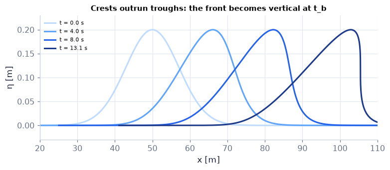

```python
fig, ax = plt.subplots(figsize=(7, 3))                     # one panel
tb = s["t_break"]                                          # breaking time [s]
for t_, cl in zip((0.0, 4.0, 8.0, tb), ("#bfdbfe", "#60a5fa", "#2563eb", "#1e3a8a")):
    xs_ = ch07.simple_wave_evolve(eta0, x, t_, 1.0)["x_points"]   # positions of the surface points at t_ [m]
    ax.plot(xs_, eta0, color=cl, lw=2, label=f"t = {t_:.1f} s")
ax.set_xlim(20, 110); ax.set_ylim(-0.03, 0.23); ax.set_xlabel("x [m]"); ax.set_ylabel("η [m]"); ax.legend(fontsize=7)
ax.set_title("Crests outrun troughs: the front becomes vertical at t_b", fontsize=10)
savefig(fig, "ch07", "c11_steepening"); plt.show()
```

**What you see.** The same hump at four times: its front steepens and becomes vertical at $t_b\approx13$ s (our remake of Fig. 7.19 `N185`). Every surface point keeps its height and moves at its own speed c(η), so the top of the hump gains on the foot of its front.

**How to read it.** Points higher up move faster: after $t_b$ the curve would fold over — real water breaks instead.

**What would change if…** …the hump were halved: $t_b$ roughly doubles (∝ 1/amplitude).

📝 **Note.** **The hydraulic jump** `N82` — After breaking, the front becomes a hydraulic jump: a nearly steady step joining a shallow supercritical stream (depth H₁, wave speed $\sqrt{gH_1}<u_1$) to a deeper subcritical one. It may stand still (spillway, a kitchen sink's circular jump) or move (a tidal bore). In the frame of a moving bore the same relations hold (the figure is our Fig. 7.20 `N186`).

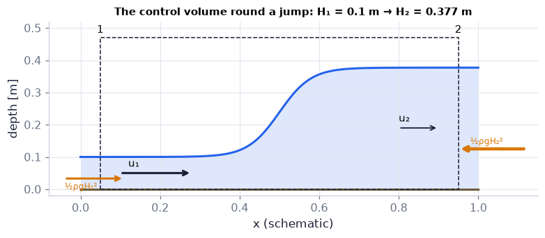

```python
fig, ax = plt.subplots(figsize=(7, 3))                     # one panel
cv_box(ax, 0.1, 0.377)                                      # channel, jump roller and the dashed control volume
ax.annotate("", xy=(0.28, 0.05), xytext=(0.1, 0.05), arrowprops=dict(arrowstyle="->", color=COLORS["ink"], lw=2))   # fast inflow
ax.text(0.12, 0.07, "u₁", fontsize=10)   # label
ax.annotate("", xy=(0.9, 0.19), xytext=(0.8, 0.19), arrowprops=dict(arrowstyle="->", color=COLORS["ink"], lw=1.2))   # slow outflow
ax.text(0.8, 0.21, "u₂", fontsize=10)   # label
ax.annotate("", xy=(0.11, 0.033), xytext=(-0.04, 0.033), arrowprops=dict(arrowstyle="->", color=COLORS["amber"], lw=2))   # pressure force on face 1
ax.text(-0.04, 0.0, "½ρgH₁²", fontsize=8, color=COLORS["amber"])   # label
ax.annotate("", xy=(0.95, 0.125), xytext=(1.12, 0.125), arrowprops=dict(arrowstyle="->", color=COLORS["amber"], lw=3))   # pressure force on face 2
ax.text(0.98, 0.14, "½ρgH₂²", fontsize=8, color=COLORS["amber"])   # label
ax.set_xlim(-0.08, 1.15); ax.set_ylim(-0.02, 0.52); ax.set_xlabel("x (schematic)"); ax.set_ylabel("depth [m]")   # axes
ax.set_title("The control volume round a jump: H₁ = 0.1 m → H₂ = 0.377 m", fontsize=10)   # the message
savefig(fig, "ch07", "c11_jump_cv"); plt.show()   # save, then draw
```

**What you see.** A control volume (dashed) round the jump with two vertical faces: fast shallow water in, slow deep water out, the hydrostatic pushes ½ρgH² on the faces (amber).

**How to read it.** Only four things enter the momentum account: two momentum fluxes and two pressure forces (the bed is frictionless, the roller stays inside).

**What would change if…** …the observer ran upstream at the bore speed: a moving bore becomes this stationary jump (Galilean frames, Ch. 3).

> 🔁 **Tools from earlier chapters used here** (see `knowledge/primers.md`)
- **control-volume momentum balance** — momentum outflow − inflow = net force, the steady form of $\frac{d}{dt}\int_{V^*}\rho\mathbf u\,dV+\int_{A^*}\rho\mathbf u(\mathbf u-\mathbf b)\cdot\mathbf n\,dA=\int_{V^*}\rho\mathbf g\,dV+\int_{A^*}\mathbf f\,dA$ *(4.17)*; a face carries the momentum flux ρu(u·n) (Ch. 4 §4.4, P114).
- **quadratic formula, np.roots, the physical root** — $r^2+r+c=0$ has $r=\tfrac12(-1\pm\sqrt{1-4c})$; the roots multiply to c (Vieta, Ch. 2 P71), so for c < 0 exactly one is positive. `np.roots([1, 1, c])` returns both.

#### 🧮 Derivation — The Bélanger relation `D25` (Eq. 7.81: $\frac{H_2}{H_1}=\tfrac12\big(-1+\sqrt{1+8\mathrm{Fr}_1^2}\big)$)

**What we want to show.** Find the downstream depth of a hydraulic jump from the upstream depth and speed, using only mass and momentum.

**Assumptions.** Steady jump; horizontal, frictionless bed; uniform velocity and hydrostatic pressure on the two faces (far from the roller); atmospheric pressure cancels (gauge).

**The plan.**

1. Choose the CV and its face forces.
2. Balance momentum.
3. Eliminate the velocities and cancel the common factor.
4. Solve the quadratic and keep the physical root.

**Tools we use** (each explained before this point): CV momentum (Ch. 4 §4.4; momentum flux P114) · hydrostatic pressure (Ch. 1 §1.7) · Froude number (R10) · quadratic formula and Vieta (P71).

**We start from**

$$ \text{Mass}\ Q=u_1H_1=u_2H_2\ \text{and the control-volume momentum balance (4.17)} $$

*In words:* what flows in flows out, and momentum out − momentum in = net force.

**Step 1 of 10 — Draw the control volume.**

$$ \text{face 1: }(H_1,u_1),\quad\text{face 2: }(H_2,u_2) $$

- *Why we can do this:* The jump is steady in this frame; vertical faces where the flow is uniform and hydrostatic keep the bookkeeping exact; the roller stays inside.
- *In words:* a box round the jump.

**Step 2 of 10 — Write mass conservation.**

$$ Q=u_1H_1=u_2H_2 $$

- *Why we can do this:* Steady and incompressible: the volume flow per unit width entering must leave.
- *In words:* the same flow rate crosses both faces.

**Step 3 of 10 — Find the face pressure forces.**

$$ \int_0^{H}\rho g(H-z)\,dz=\tfrac12\rho gH^2 $$

- *Why we can do this:* Hydrostatic gauge pressure ρg(H − z) on a vertical face of height H, integrated over the depth (per unit width).
- *In words:* each face is pushed by the weight of its column.

**Step 4 of 10 — Balance momentum.**

$$ \rho Q(u_2-u_1)=\tfrac12\rho gH_1^2-\tfrac12\rho gH_2^2 $$

- *Why we can do this:* (4.17), $\frac{d}{dt}\int_{V^*}\rho\mathbf u\,dV+\int_{A^*}\rho\mathbf u(\mathbf u-\mathbf b)\cdot\mathbf n\,dA=\int_{V^*}\rho\mathbf g\,dV+\int_{A^*}\mathbf f\,dA$ with d/dt = 0 and no x-body force: momentum outflow − inflow = net pressure force; the frictionless bed gives no x-force.
- *In words:* the momentum lost equals the difference of the pushes.

**Step 5 of 10 — Eliminate the velocities.**

$$ Q^2\Big(\frac1{H_2}-\frac1{H_1}\Big)=\tfrac12g(H_1^2-H_2^2)\ \text{(7.80)} $$

- *Why we can do this:* u₁ = Q/H₁, u₂ = Q/H₂; divide by ρ.
- *In words:* the jump relation in depths.

**Step 6 of 10 — Factor both sides.**

$$ \frac{Q^2(H_1-H_2)}{H_1H_2}=\tfrac12g(H_1-H_2)(H_1+H_2) $$

- *Why we can do this:* 1/H₂ − 1/H₁ = (H₁ − H₂)/(H₁H₂) and a² − b² = (a − b)(a + b).
- *In words:* both sides share H₁ − H₂.

**Step 7 of 10 — Cancel the common factor.**

$$ Q^2=\tfrac12gH_1H_2(H_1+H_2) $$

- *Why we can do this:* H₁ ≠ H₂ for a jump (H₁ = H₂ is the trivial 'no jump' solution).
- *In words:* the flow rate links both depths.

**Step 8 of 10 — Make it dimensionless.**

$$ 2\mathrm{Fr}_1^2=r(1+r),\quad r=\frac{H_2}{H_1},\quad\mathrm{Fr}_1^2=\frac{Q^2}{gH_1^3}=\frac{u_1^2}{gH_1} $$

- *Why we can do this:* Divide by ½gH₁³; (4.104) Fr = u/√(gH).
- *In words:* one quadratic in the depth ratio.

**Step 9 of 10 — Use the quadratic formula.**

$$ r^2+r-2\mathrm{Fr}_1^2=0\ \Rightarrow\ r=\tfrac12\big(-1\pm\sqrt{1+8\mathrm{Fr}_1^2}\big) $$

- *Why we can do this:* Roots of r² + r + c = 0; their product is −2Fr₁² < 0 (Vieta, P71), so exactly one root is positive.
- *In words:* two candidates, one negative.

**Step 10 of 10 — Keep the positive root.**

$$ \frac{H_2}{H_1}=\tfrac12\big(-1+\sqrt{1+8\mathrm{Fr}_1^2}\big)\ \text{(7.81)} $$

- *Why we can do this:* A depth ratio must be positive.
- *In words:* the conjugate depth of the jump.

**Result**

$$ \frac{H_2}{H_1}=\frac12\big(-1+\sqrt{1+8\mathrm{Fr}_1^2}\big) $$

**What it means.** Momentum alone fixes the jump height; energy is not conserved and was never used — it decides the direction (D26).

**Check it.** Fr₁ = 1 → r = 1 (no jump) ✓. H₁ = 0.1 m, Fr₁ = 3 → H₂ = 0.377 m; momentum terms 882.9 − 234.1 = 697.9 − 49.05 N/m ✓. Matches the published Bélanger form (V1 cross-check) and `np.roots` from scratch ✓.

> ⚠️ **Common confusion (traps in `D25`):** Using Bernoulli across the jump (energy is lost); forgetting the pressure forces are ½ρgH², not ρgH²; keeping the negative root.

📝 **Note.** **The momentum balance in the book's form** `N83`

$$ Q^2\Big(\frac1{H_2}-\frac1{H_1}\Big)=\tfrac12g(H_1^2-H_2^2) \qquad \text{(7.80)} $$

#### 🧮 Derivation — The energy loss of a jump and the second law `D26`

**What we want to show.** Compute the change of mechanical energy across a jump and show why only upward jumps exist.

**Assumptions.** As D25; E is per unit mass of a surface particle.

**The plan.**

1. Subtract the two faces.
2. Insert Q².
3. Put everything over one denominator and factor.
4. Read the sign.

**Tools we use** (each explained before this point): difference of squares · factorising · D25.

**We start from**

$$ E=\frac{u^2}2+gH=\frac{Q^2}{2H^2}+gH\ \text{and}\ Q^2=\tfrac12gH_1H_2(H_1+H_2)\ \text{(D25 step 7).} $$

**Step 1 of 8 — Write the energy per unit mass.**

$$ E=\frac{Q^2}{2H^2}+gH $$

- *Why we can do this:* Bernoulli's sum for a surface particle: gauge pressure 0, height H above the bed, speed u = Q/H.
- *In words:* kinetic plus potential energy of surface water.

**Step 2 of 8 — Subtract the two faces.**

$$ E_2-E_1=\frac{Q^2}2\Big(\frac1{H_2^2}-\frac1{H_1^2}\Big)+g(H_2-H_1) $$

- *Why we can do this:* Evaluate step 1 at both faces.
- *In words:* the change across the jump.

**Step 3 of 8 — Combine the fractions.**

$$ \frac1{H_2^2}-\frac1{H_1^2}=\frac{(H_1-H_2)(H_1+H_2)}{H_1^2H_2^2} $$

- *Why we can do this:* Common denominator and a difference of squares.
- *In words:* ready for Q².

**Step 4 of 8 — Insert Q² from D25.**

$$ \frac{Q^2}2\cdot\frac{(H_1-H_2)(H_1+H_2)}{H_1^2H_2^2}=\frac{g(H_1+H_2)^2(H_1-H_2)}{4H_1H_2} $$

- *Why we can do this:* Q² = ½gH₁H₂(H₁ + H₂); one factor H₁H₂ cancels.
- *In words:* the kinetic change in depths only.

**Step 5 of 8 — Put both terms over 4H₁H₂.**

$$ E_2-E_1=\frac{g(H_2-H_1)}{4H_1H_2}\big[4H_1H_2-(H_1+H_2)^2\big] $$

- *Why we can do this:* Write g(H₂ − H₁) = g(H₂ − H₁)·4H₁H₂/(4H₁H₂) and H₁ − H₂ = −(H₂ − H₁).
- *In words:* factor out the common pieces.

**Step 6 of 8 — Simplify the bracket.**

$$ 4H_1H_2-(H_1+H_2)^2=-(H_2-H_1)^2 $$

- *Why we can do this:* Expand: 4H₁H₂ − H₁² − 2H₁H₂ − H₂² = −(H₁² − 2H₁H₂ + H₂²).
- *In words:* a negative square.

**Step 7 of 8 — Collect.**

$$ E_2-E_1=-\frac{g(H_2-H_1)^3}{4H_1H_2} $$

- *Why we can do this:* Multiply step 5 by step 6. (Some copies lose this minus sign; the energy argument below needs it.)
- *In words:* the energy change is a cube of the depth change.

**Step 8 of 8 — Read the sign.**

$$ H_2>H_1\Rightarrow E_2<E_1;\qquad H_2<H_1\Rightarrow E_2>E_1\ (\text{forbidden}) $$

- *Why we can do this:* The turbulent roller can only dissipate mechanical energy (second law); a 'jump down' would create energy, so only Fr₁ > 1 (H₂ > H₁) happens. Head loss = (E₁ − E₂)/g.
- *In words:* water can jump up, never down.

**Result**

$$ E_2-E_1=-(H_2-H_1)\frac{g(H_2-H_1)^2}{4H_1H_2}\ \text{, negative for every physical jump.} $$

**What it means.** The jump is a shock: like a gas-dynamic shock (Ch. 15) it takes supercritical to subcritical flow and loses mechanical energy; engineers build stilling basins to make jumps dissipate a spillway's energy safely.

**Check it.** H₁ = 0.1 m, Fr₁ = 3: E₂ − E₁ = −1.385 J/kg, head loss 0.141 m (the published Bélanger loss) ✓. Units J/kg ✓.

> ⚠️ **Common confusion (traps in `D26`):** Taking E per unit mass of a particle at the bed (the pressure term changes); losing the minus sign; thinking the loss is small (it grows like the cube of the depth change).

📝 **Note.** **Only upward jumps** `N84` — The mechanical energy per unit mass of a surface particle drops across the jump, $E_2-E_1=-(H_2-H_1)\frac{g(H_2-H_1)^2}{4H_1H_2}<0$ whenever H₂ > H₁; a "jump down" (Fr₁ < 1) would create mechanical energy — the second law forbids it. The lost energy goes into the turbulent roller and ends as heat.

#### ✏️ Tiny example: a spillway jump

H₁ = 0.1 m, Fr₁ = 3.

1. $u_1=\mathrm{Fr}_1\sqrt{gH_1}=3\times0.990=2.97$ m/s, $Q=u_1H_1=0.297$ m²/s.
2. $H_2/H_1=\tfrac12(-1+\sqrt{1+72})=\tfrac12(-1+8.544)=3.772$ → H₂ = 0.377 m.
3. $u_2=Q/H_2=0.788$ m/s, $\mathrm{Fr}_2=0.788/\sqrt{9.81\times0.377}=0.41$ (subcritical).
4. Head loss $\frac{(H_2-H_1)^3}{4H_1H_2}=\frac{0.2772^3}{4\times0.1\times0.377}=0.141$ m — the energy of 14 cm of fall, ≈ ρgQ × 0.141 = 412 W per metre of width turned into heat.

```python
j = ch07.hydraulic_jump(0.1, Fr1=3.0)                      # (7.81) and the energy loss
print({n: (round(float(v), 4) if not isinstance(v, bool) else v) for n, v in j.items()})   # every result, rounded
print("momentum residual of (7.80):", ch07.jump_momentum_residual(0.1, j["H2"], j["Q"]), "m³/s²")   # ≈ 0
st = ch07.jump_state(0.1, 3.0)                             # the momentum budget per metre of width
print(f"momentum in {st['mom_in']:.1f}, out {st['mom_out']:.1f} N/m; pressure force in {st['p_in']:.2f}, "   # the four terms of the budget …
      f"out {st['p_out']:.1f} N/m; balance {st['residual']:.1e} N/m; power lost {st['power_loss']:.0f} W/m")   # … their balance and the dissipated power
jd = ch07.hydraulic_jump(1.0, Fr1=0.7)                     # a subcritical 'jump'
print(f"Fr₁ = 0.7: H₂/H₁ = {jd['ratio']:.3f}, E₂ − E₁ = {jd['dE']:+.3f} J/kg, allowed = {jd['allowed']}")   # energy would increase: forbidden
print("bore 2 m deep into still water 1 m deep:", ch07.jump_state(1.0, 3.0**0.5, frame="moving")["bore_speed"], "m/s;",   # the moving-bore frame …
      "Ch. 4:", ch04.bore_speed(1.0, 2.0, g=G), "m/s")    # Fr₁ = √3 ⇔ H₂/H₁ = 2; ch04.bore_speed(h_still, h_behind)
```

```
{'H2': 0.3772, 'u1': 2.9714, 'u2': 0.7877, 'Fr1': 3.0, 'Fr2': 0.4095, 'ratio': 3.772, 'Q': 0.2971, 'E1': 5.3955, 'E2': 4.0106, 'dE': -1.3849, 'head_loss': 0.1412, 'allowed': True}
momentum residual of (7.80): -1.1102230246251565e-16 m³/s²
momentum in 882.9, out 234.1 N/m; pressure force in 49.05, out 697.9 N/m; balance 1.1e-13 N/m; power lost 412 W/m
Fr₁ = 0.7: H₂/H₁ = 0.609, E₂ − E₁ = +0.241 J/kg, allowed = False
bore 2 m deep into still water 1 m deep: 5.424942396007538 m/s; Ch. 4: 5.424942396007538 m/s
```

**What does the code above do?**

1. H₂ = 0.3772 m, u₂ = 0.788 m/s, Fr₂ = 0.410, $E_2-E_1=-1.385$ J/kg, head loss 0.1412 m.
2. The momentum budget balances: 882.9 − 234.1 N/m of momentum flux against 697.9 − 49.05 N/m of pressure force (to $10^{-13}$); 412 W per metre of width is dissipated.
3. For Fr₁ = 0.7 the formula still gives a number (H₂/H₁ = 0.609) but the energy *increases*: `allowed = False`.
4. A bore of depth 2 m running into still water 1 m deep (H₂/H₁ = 2 ⇔ Fr₁ = √3) moves at 5.42 m/s — the same as Ch. 4's bore speed (`ch04.bore_speed(h_in, h_out)`, still depth first).

```python
r = np.roots([1.0, 1.0, -2*3.0**2])                        # D25 step 9: r² + r − 2Fr₁² = 0 with Fr₁ = 3
print("both roots:", r)                                    # 3.772 and −4.772
r_pos = r[r > 0][0]                                        # physics keeps the positive depth ratio
assert np.allclose(r_pos, ch07.hydraulic_jump(0.1, Fr1=3.0)["ratio"], rtol=1e-12)   # = (7.81)
```

```
both roots: [-4.772  3.772]
```

**What does this show?** The quadratic r² + r − 2Fr₁² = 0 of D25 step 9 (Fr₁ = 3) has the roots 3.772 and −4.772. A depth ratio cannot be negative, so the jump keeps 3.772 — exactly the ratio $\frac{H_2}{H_1}=\tfrac12\big(-1+\sqrt{1+8\mathrm{Fr}_1^2}\big)$ *(7.81)* that `hydraulic_jump` returns.

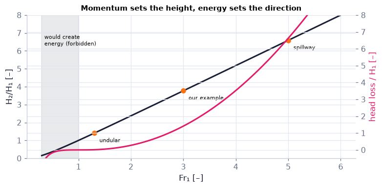

```python
Fr = np.linspace(0.3, 6, 300)                              # upstream Froude numbers [–]
res = [ch07.hydraulic_jump(1.0, Fr1=f) for f in Fr]        # H₁ = 1 m
ratio = np.array([q["ratio"] for q in res]); loss = np.array([q["head_loss"] for q in res])   # H₂/H₁ and loss/H₁
fig, ax = plt.subplots(figsize=(7, 3.4)); ax2 = ax.twinx()  # two y-axes
ax.plot(Fr, ratio, color=COLORS["ink"], lw=2, label="H₂/H₁ (7.81)")   # conjugate depth ratio
ax2.plot(Fr, loss, color=COLORS["rose"], lw=2, label="head loss / H₁")   # energy lost, in metres of fall per metre of H₁
ax.axvspan(0.3, 1.0, color=COLORS["muted"], alpha=0.15); ax.text(0.35, 6.3, "would create\nenergy (forbidden)", fontsize=7)   # the forbidden band
for f, lab in ((1.3, "undular"), (3.0, "our example"), (5.0, "spillway")):   # three marked cases
    q = ch07.hydraulic_jump(1.0, Fr1=f); ax.plot(f, q["ratio"], "o", color=COLORS["orange"]); ax.text(f + 0.1, q["ratio"] - 0.5, lab, fontsize=7)
ax.set_xlabel("Fr₁ [–]"); ax.set_ylabel("H₂/H₁ [–]"); ax2.set_ylabel("head loss / H₁ [–]", color=COLORS["rose"])   # axes
ax.set_ylim(0, 8); ax2.set_ylim(-0.5, 8)   # ranges
ax.set_title("Momentum sets the height, energy sets the direction", fontsize=10)   # the message
savefig(fig, "ch07", "c11_jump_curves"); plt.show()   # save, then draw
```

**What you see.** The depth ratio (black) grows roughly like √2·Fr₁; the head loss (rose, right axis) rises steeply; the grey band Fr₁ < 1 is forbidden.

**How to read it.** At Fr₁ = 1 nothing happens (H₂ = H₁, no loss); below 1 the formula still gives a number but the loss would be negative.

**What would change if…** …H₁ were doubled at the same Fr₁: every ratio stays, the head loss in metres doubles (it scales with H₁).

📝 **Note.** **Dispersion against steepening** `N85` — In a dispersive medium the different wavelengths separate, which works against steepening; the two can balance and give waves of permanent form.

📝 **Note.** **The Korteweg–de Vries equation** `N93` — For long waves that are only weakly dispersive (λ several times H, but not so long that nonlinearity alone rules), Korteweg and de Vries (1895) showed (7.87), with $c_0=\sqrt{gH}$: term by term, shallow-water propagation, nonlinear steepening (note N81, the ³⁄₂ coefficient) and the first correction for the depth not being quite shallow (weak dispersion).

$$ \frac{\partial\eta}{\partial t}+c_0\frac{\partial\eta}{\partial x}+\frac32c_0\frac\eta H\frac{\partial\eta}{\partial x}+\frac16c_0H^2\frac{\partial^3\eta}{\partial x^3}=0 \qquad \text{(7.87)} $$

📝 **Note.** **Its linear speed** `N94` — Without the nonlinear term, η = a cos(kx − ωt) gives $c=c_0(1-\tfrac16k^2H^2)$ — the first two Taylor terms of $c=\sqrt{\frac gk\tanh kH}$ *(7.29)*. The error grows like (kH)⁴:

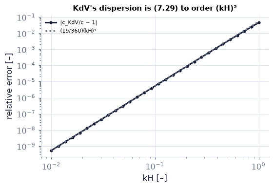

```
fitted slope: 4.00
```

```python
kH = np.logspace(-2, 0, 30)                                # depth ratios [–] (H = 1 m)
err = np.abs(ch07.kdv_linear_phase_speed(kH, 1.0)/ch07.phase_speed(kH, 1.0) - 1)   # |c_KdV/c − 1|
fig, ax = plt.subplots(figsize=(5, 3.4))   # one panel
ax.loglog(kH, err, "o-", color=COLORS["ink"], ms=3, label="|c_KdV/c − 1|")   # the error of KdV's speed
ax.loglog(kH, 19/360*kH**4, ":", color=COLORS["muted"], label="(19/360)(kH)⁴")   # the next Taylor term
ax.set_xlabel("kH [–]"); ax.set_ylabel("relative error [–]"); ax.legend(fontsize=7)   # axes and legend
ax.set_title("KdV's dispersion is (7.29) to order (kH)²", fontsize=10)   # the message
savefig(fig, "ch07", "c11_kdv_speed"); plt.show()   # save, then draw
print(f"fitted slope: {observed_order(kH[:20], err[:20]):.2f}")   # expect 4
```

**What you see.** A straight line of slope 4 (fitted slope printed below the figure).

**How to read it.** KdV reproduces the true phase speed to about 5 % of (kH)⁴: 0.05 % at kH = 0.3, 5 % at kH = 1.

**What would change if…** …the dispersive term were dropped: the error would be the full $(kH)^2/6$ — slope 2.

📝 **Note.** **Which fate wins?** `N95` — The ratio of the nonlinear to the dispersive term of (7.87), $\frac{\partial\eta}{\partial t}+c_0\frac{\partial\eta}{\partial x}+\frac32c_0\frac\eta H\frac{\partial\eta}{\partial x}+\frac16c_0H^2\frac{\partial^3\eta}{\partial x^3}=0$ is $\frac\eta H\frac{\partial\eta}{\partial x}\Big/H^2\frac{\partial^3\eta} {\partial x^3}\sim\frac{a\lambda^2}{H^3}$ (the Ursell number; the book's text says (7.88), $\eta=a\,\mathrm{sech}^2\Big[\Big(\frac{3a}{4H^3}\Big)^{1/2}(x-ct)\Big],\ c=c_0\Big(1+\frac a{2H}\Big)$ but means the terms of (7.87)). When it is large the front steepens into a jump; when it is of order one or smaller, dispersion can balance it. Where exactly the crossover sits depends on how the slopes are estimated: with sinusoidal slopes (∂/∂x → k) the two KdV terms are equal when $\frac{9a}{k^2H^3}=1$, i.e. at $a\lambda^2/H^3=4\pi^2/9\approx4.4$ (printed below).

```python
for a, lam in ((0.1, 10.0), (0.2, 10.0), (0.05, 30.0)):   # amplitude and wavelength on H = 1 m [m]
    print(f"a = {a} m, λ = {lam:.0f} m: Ursell number aλ²/H³ = {ch07.ursell_number(a, lam, 1.0):.0f}")
print(f"equal KdV terms (sinusoidal slopes) at aλ²/H³ = 4π²/9 = {4*np.pi**2/9:.2f}")   # 9a/(k²H³) = 1 with k = 2π/λ
```

```
a = 0.1 m, λ = 10 m: Ursell number aλ²/H³ = 10
a = 0.2 m, λ = 10 m: Ursell number aλ²/H³ = 20
a = 0.05 m, λ = 30 m: Ursell number aλ²/H³ = 45
equal KdV terms (sinusoidal slopes) at aλ²/H³ = 4π²/9 = 4.39
```

**What does the code above do?**

1. The Ursell number $a\lambda^2/H^3$ for three waves on H = 1 m: 10, 20 and 45 — each far above the crossover, so these fronts steepen before dispersion can stop them.
2. The last line is the crossover estimate: the nonlinear term $\frac32c_0\frac aH\,ka$ equals the dispersive term $\frac16c_0H^2k^3a$ when $9a/(k^2H^3)=1$.

> 🔁 **Tools from earlier chapters used here** (see `knowledge/primers.md`)
- **solitary wave (7.88), $\eta=a\,\mathrm{sech}^2\Big[\Big(\frac{3a}{4H^3}\Big)^{1/2}(x-ct)\Big],\ c=c_0\Big(1+\frac a{2H}\Big)$, sech² and its derivatives** — $\mathrm{sech}=1/\cosh$ (primer P168); $\frac{d}{dx}\tanh x=\mathrm{sech}^2x$ and $\frac{d}{dx}\mathrm{sech}\,x=-\mathrm{sech}\,x\tanh x$ — all the calculus the soliton check needs.

📝 **Note.** **Cnoidal and solitary waves** `N96, N97` — The periodic permanent-form solutions of (7.87), $\frac{\partial\eta}{\partial t}+c_0\frac{\partial\eta}{\partial x}+\frac32c_0\frac\eta H\frac{\partial\eta}{\partial x}+\frac16c_0H^2\frac{\partial^3\eta}{\partial x^3}=0$ are cnoidal waves (Jacobi's cn functions, drawn with `ch07.cnoidal_wave`). The single-hump solution is the solitary wave (7.88): taller is faster (checked by substitution below; the derivatives used are $\tanh'=\mathrm{sech}^2$ and $\mathrm{sech}'=-\mathrm{sech}\tanh$).

$$ \eta=a\,\mathrm{sech}^2\Big[\Big(\frac{3a}{4H^3}\Big)^{1/2}(x-ct)\Big],\ c=c_0\Big(1+\frac a{2H}\Big) \qquad \text{(7.88)} $$

```python
print(ch07.kdv_residual_sympy())                            # (7.88) put into (7.87): the residual is exactly 0
print(f"a = 0.2 m on H = 1 m: c = c₀(1 + a/2H) = {np.sqrt(G*1.0)*(1 + 0.2/2):.3f} m/s")   # (7.88)
```

```
{'residual': 0, 'residual_coefficients': [0], 'speed': sqrt(H)*sqrt(g)*(1 + a/(2*H))}
a = 0.2 m on H = 1 m: c = c₀(1 + a/2H) = 3.445 m/s
```

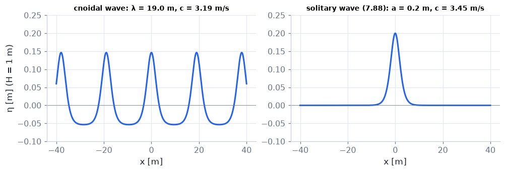

```python
x = np.linspace(-40, 40, 800)                              # positions [m]
fig, (a1, a2) = plt.subplots(1, 2, figsize=(9, 3))         # cnoidal | solitary
cn = ch07.cnoidal_wave(x, 0.0, H=1.0, height=0.2, m=0.99)  # a cnoidal train, crest-to-trough 0.2 m
a1.plot(x, cn["eta"], color=COLORS["blue"], lw=2); a1.axhline(0, color=COLORS["muted"], lw=0.5)   # the cnoidal surface and the still level
a1.set_title(f"cnoidal wave: λ = {cn['wavelength']:.1f} m, c = {cn['c']:.2f} m/s", fontsize=9)   # its wavelength and speed
a2.plot(x, ch07.solitary_wave(x, 0.0, 0.2, 1.0), color=COLORS["blue"], lw=2); a2.axhline(0, color=COLORS["muted"], lw=0.5)   # (7.88)
a2.set_title(f"solitary wave (7.88): a = 0.2 m, c = {ch07.solitary_wave_speed(0.2, 1.0):.2f} m/s", fontsize=9)   # its speed c₀(1 + a/2H)
for axp in (a1, a2):   # both panels:
    axp.set_xlabel("x [m]"); axp.set_ylim(-0.1, 0.25)   # same axes
a1.set_ylabel("η [m] (H = 1 m)")   # unit
savefig(fig, "ch07", "c11_cnoidal_solitary"); plt.show()   # save, then draw
```

**What you see.** Left, a cnoidal train with sharp crests and long flat troughs; right, a single hump (our remake of Fig. 7.23 `N189`).

**How to read it.** Steepening (the $\eta\,\partial\eta/\partial x$ term) and spreading (the $\partial^3\eta/\partial x^3$ term) cancel exactly for these shapes, so they travel unchanged.

**What would change if…** …a were doubled: the hump narrows by √2 and speeds up to $c_0(1+a/H)$.

```python
fig, (a1, a2) = plt.subplots(2, 1, figsize=(7, 4.4), layout="none")   # (a) no dispersion | (b) KdV; manual spacing below
xs_ = np.linspace(0, 200, 2001); e0 = 0.2*np.exp(-((xs_ - 50)/10)**2)   # the hump of N81
sw = ch07.simple_wave_evolve(e0, xs_, 0.0, 1.0)            # breaking time
(l1,) = a1.plot(xs_, e0, color=COLORS["blue"], lw=2); a1.set_xlim(20, 110); a1.set_ylim(-0.03, 0.25)   # panel (a): the hump
a1.set_ylabel("η [m]")   # unit
N = 1024 if not FAST else 512                              # KdV grid (spectral)
xk = np.linspace(-50, 350, N, endpoint=False)              # periodic domain [m]
ek0 = 0.1*np.exp(-(xk/10)**2)                              # a 10 cm Gaussian hump, 10 m wide, H = 1 m
tk = np.linspace(0, 100, 16 if not FAST else 9)           # output times [s]
kd = ch07.kdv_solve(ek0, xk, tk, 1.0, cache=str(ROOT/"outputs"/"ch07"/f"kdv_run_{N}.npz"))   # (7.87), cached
(l2,) = a2.plot(xk, ek0, color=COLORS["blue"], lw=1.5); a2.set_xlim(-50, 350); a2.set_ylim(-0.04, 0.2)   # panel (b): the KdV hump
a2.set_xlabel("x [m]"); a2.set_ylabel("η [m]")   # units


def update(i):   # draw frame i
    t1 = i/(len(tk) - 1)*sw["t_break"]                     # (a) runs up to the breaking time
    l1.set_xdata(ch07.simple_wave_evolve(e0, xs_, t1, 1.0)["x_points"])   # each surface point moved along its characteristic
    a1.set_title(f"(a) no dispersion: steepening, t = {t1:.1f} s (breaks at {sw['t_break']:.1f} s)", fontsize=9)   # time in the title
    l2.set_ydata(kd["eta"][i])                              # (b) the KdV solution at tk[i]
    a2.set_title(f"(b) KdV (7.87): the hump sorts itself into solitons, t = {tk[i]:.0f} s", fontsize=9)   # time in the title
    return []   # nothing to blit


fig.subplots_adjust(left=0.1, right=0.97, bottom=0.1, top=0.92, hspace=0.5)   # margins and room for the two titles
show_animation(animate(update, frames=len(tk), fig=fig, interval=200), player="frames")   # a frame player: step with ◀ ▶
print(f"KdV invariants: mass drift {abs(kd['mass'][-1]/kd['mass'][0] - 1):.1e}, "   # conserved quantities of (7.87) …
      f"energy drift {abs(kd['energy'][-1]/kd['energy'][0] - 1):.1e} (relative); {kd['steps']} steps, cached = {kd['cached']}")   # … should not drift
```

[figure not shown]

Once Loop Reflect

```
KdV invariants: mass drift 2.2e-16, energy drift 2.5e-13 (relative); 9225 steps, cached = True
```

**What you see.** Step through the frames (◀ ▶): (a) without dispersion the hump's front becomes vertical at $t_b$; (b) with the KdV dispersive term the same kind of hump splits into a train of solitary waves, the tallest (fastest) in front, followed by a small dispersive tail — the `A5` player.

**How to read it.** The printed invariants (mass and the KdV energy) stay constant to many digits: the solver is accurate. Taller solitons are faster, $c=c_0\big(1+\frac a{2H}\big)$ *(7.88)*, so the train spreads out in order of height.

**What would change if…** …the hump were wider (smaller Ursell number): fewer solitons, eventually just one.

#### 🎮 Interactive: How high does the water jump — and why only upward?

**Why interactive rather than a static figure:** The Fr₁ slider moves the downstream depth, the momentum bars and the energy bar together; pushing Fr₁ below 1 turns the energy change positive — the second law choosing the root is felt, not just stated.

**What to try:**

- Preset *spillway*: read H₂ and the head loss.
- Drag Fr₁ to 0.7: the status turns red — the energy bar is positive.
- Switch to the moving-bore frame: the same depths, a different observer.
- Choose the solitary-wave fate and raise a/H: watch the Ursell number grow and the front steepen.

```python
show_viz("ch07", "hydraulic_jump")   # full-width explainer; ⤢ Full screen for more room
```

🎮 Interactive 6/9 How high does the water jump — and why only upward? Open alone ↗

[interactive chart not shown]

**What would change if…** …the layer were a denser fluid under a lighter one (cold air under warm air, salty water under fresh)? g becomes the reduced gravity g′ of C14 and the same jump appears as an internal hydraulic jump in the lee of mountains (Ch. 13).

### 🧩 Stokes waves and Stokes drift `C12`

*The question:* If every orbit is a closed circle, why does floating debris travel with the waves?

*In one line:* $\bar u_L=a^2\omega ke^{2kz_0}$ *(7.85)*

#### The problem in plain words

A swimmer floating beyond the surf slowly drifts toward the beach although "waves only move up and down"; oil, plastic and larvae at sea are carried downwind by the waves themselves. We want that mean drift: its size, how fast it dies with depth, and why a current meter fixed in place measures no mean current at all.

📝 **Note.** **Stokes waves** `N86, N87` — In 1847 Stokes found periodic waves of finite amplitude in deep water, (7.82), with $c=\sqrt{\frac gk(1+k^2a^2+\ldots)}$ *(7.83)*: the harmonics sharpen the crests and flatten the troughs, and the speed grows with amplitude (4.4 % at ka = 0.3). We state them; the code cell below re-derives the coefficients in sympy.

$$ \eta=a\cos k(x-ct)+\tfrac12ka^2\cos2k(x-ct)+\tfrac38k^2a^3\cos3k(x-ct)+\ldots \qquad \text{(7.82)} $$

**How the coefficients are found — and a trap** (verification note O4). Write, with ε = ka and k = g = 1, $\eta=\varepsilon\cos\theta+\alpha\varepsilon^2\cos2\theta+\delta\varepsilon^3\cos3\theta$, $\phi=\varepsilon\omega(1+\beta\varepsilon^2)e^{z}\sin\theta$ and $\omega^2=1+\gamma\varepsilon^2$, put them into the exact kinematic condition (7.16), $\Big(\frac{\partial\phi}{\partial z}\Big)_{z=\eta}=\frac{\partial\eta}{\partial t}+\frac{\partial\eta}{\partial x}\Big(\frac{\partial\phi}{\partial x}\Big)_{z=\eta}$ and the full Bernoulli equation with p = 0, both on z = η, and collect powers of ε and harmonics:

| order | condition | gives |
| --- | --- | --- |
| ε² | kinematic, sin 2θ | α = ½ — the second harmonic of (7.82), $\eta=a\cos k(x-ct)+\tfrac12ka^2\cos2k(x-ct)+\tfrac38k^2a^3\cos3k(x-ct)+\ldots$ |
| ε³ | kinematic, sin θ and sin 3θ | β = −5/8, δ = 3/8 |
| ε³ | dynamic, cos θ | γ = 1 — the speed correction of (7.83), $c=\sqrt{\frac gk(1+k^2a^2+\ldots)}$ |

With β = −5/8 and $\omega\approx1+\varepsilon^2/2$, the potential's first harmonic is $\varepsilon(1-\varepsilon^2/8)$: the amplitude of φ is corrected at second order. **If instead the potential is kept at aω/k (β = 0) and the kinematic condition only to first order** — a tempting shortcut — the ε³ balance gives γ = 3/8, not 1. The consistent third-order solution (the coded one, and an independent expansion in the tests) gives γ = 1, i.e. (7.83).

> 🔁 **Tools from earlier chapters used here** (see `knowledge/primers.md`)
- **perturbation series checked in sympy** — `sp.series(expr, eps, 0, 4).removeO()` keeps powers of ε up to ε³, `.coeff(eps, n)` reads one order, and a product of sines is turned into harmonics before reading a coefficient (Ch. 4 P117).

```python
st = ch07.stokes_expansion_sympy()                        # the expansion above, done in sympy (cached)
print("consistent third order:", st["third_order"])        # alpha = 1/2, beta = −5/8, delta = 3/8, gamma = 1
print("truncated set-up (β frozen at 0):", st["exercise_literal"])   # alpha = 1/2 but gamma = 3/8: β was dropped
print(f"c(ka = 0.3)/c(ka → 0) = {ch07.stokes_wave_speed(1.0, 0.3)/ch07.phase_speed(1.0):.4f}")   # (7.83): 4.4 % faster
```

```
consistent third order: {'alpha': 1/2, 'beta': -5/8, 'delta': 3/8, 'gamma': 1}
truncated set-up (β frozen at 0): {'alpha': 1/2, 'gamma': 3/8}
c(ka = 0.3)/c(ka → 0) = 1.0440
```

**What does the code above do?**

1. `stokes_expansion_sympy` projects each condition on its harmonics order by order: α = ½ and δ = ³⁄₈ (the coefficients of (7.82), $\eta=a\cos k(x-ct)+\tfrac12ka^2\cos2k(x-ct)+\tfrac38k^2a^3\cos3k(x-ct)+\ldots$) and γ = 1 (the ka² of (7.83), $c=\sqrt{\frac gk(1+k^2a^2+\ldots)}$) — plus β = −⁵⁄₈, the correction of φ's first harmonic.
2. The same machinery with φ frozen at aω/k gives γ = ³⁄₈: dropping a term of the same order as the one kept changes the answer.
3. At ka = 0.3 the Stokes wave is 4.4 % faster than the linear one.

📝 **Note.** **The steepest wave** `N88` — The steepest possible Stokes wave has a sharp crest of angle 120° (Stokes 1880) and crest-to-trough height/wavelength of about one-seventh (Schwartz and Fenton's 1982 review); the digits 0.1411 in `ch07.STOKES_LIMIT_STEEPNESS` are from the computation of Dyachenko, Lushnikov and Korotkevich (2016). Half of it, measured from the mean level, is the largest amplitude, a ≈ 0.071λ (printed below); beyond it the crest spills (white caps). The truncated series (7.82), $\eta=a\cos k(x-ct)+\tfrac12ka^2\cos2k(x-ct)+\tfrac38k^2a^3\cos3k(x-ct)+\ldots$ cannot reach that corner; we show profiles only up to ka = 0.3.

```python
Hmax = ch07.STOKES_LIMIT_STEEPNESS                         # crest-to-trough height / wavelength of the steepest wave [–]
print(f"H/λ = {Hmax:.4f} ≈ 1/{1/Hmax:.2f};  largest amplitude a = H/2 ≈ {Hmax/2:.3f} λ;  ka = π·H/λ ≈ {np.pi*Hmax:.2f}")   # a from the mean level
```

```
H/λ = 0.1411 ≈ 1/7.09;  largest amplitude a = H/2 ≈ 0.071 λ;  ka = π·H/λ ≈ 0.44
```

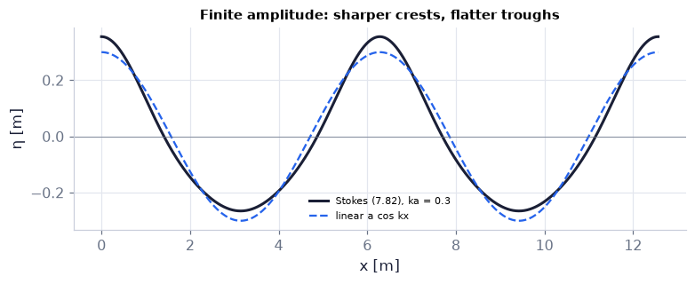

```python
x = np.linspace(0, 4*np.pi, 800)                           # two wavelengths, k = 1 rad/m [m]
fig, ax = plt.subplots(figsize=(7, 2.8))                   # one panel
ax.plot(x, ch07.stokes_wave_profile(x, 0.0, 0.3, 1.0), color=COLORS["ink"], lw=2, label="Stokes (7.82), ka = 0.3")   # three harmonics
ax.plot(x, 0.3*np.cos(x), "--", color=COLORS["blue"], lw=1.5, label="linear a cos kx")   # first harmonic only
ax.axhline(0, color=COLORS["muted"], lw=0.5); ax.set_xlabel("x [m]"); ax.set_ylabel("η [m]"); ax.legend(fontsize=7)   # still level and axes
ax.set_title("Finite amplitude: sharper crests, flatter troughs", fontsize=10)   # the message
savefig(fig, "ch07", "c12_stokes_profile"); plt.show()   # save, then draw
```

**What you see.** The Stokes profile (black) at ka = 0.3 against the linear cosine (blue dashed) — our remake of Fig. 7.21 `N187`.

**How to read it.** The second harmonic $\tfrac12ka^2\cos2k(x-ct)$ adds at the crests and subtracts at the troughs: crests 0.355 m high, troughs only 0.265 m deep.

**What would change if…** …ka = 0.1: the two curves almost coincide (the correction is ∝ ka).

📝 **Note.** **Stokes drift** `N89` — At finite amplitude a particle is a little further forward at the top of its loop, where the forward velocity is larger, than it is backward at the bottom, where it is smaller: the loop does not close and the particle creeps forward (the book's Fig. 7.22). **Lagrangian vs Eulerian mean**: the average of the velocity *following a particle* ($\bar u_L$) versus the average *at a fixed point* (ū); they differ whenever the particle samples a non-uniform field (Ch. 3 §3.2).

📝 **Note.** **The velocity a parcel really feels** `N90` — Keep the first Taylor terms of u about the mean position (Ch. 3 P98): (7.84a), and the same for w, $\frac{dz_p}{dt}= w(x_0,z_0,t)+\xi\big(\frac{\partial w}{\partial x}\big)_0+\zeta\big(\frac{\partial w}{\partial z}\big)_0+\ldots$ *(7.84b)*.

$$ \frac{dx_p}{dt}=u(x_0,z_0,t)+\xi\Big(\frac{\partial u}{\partial x}\Big)_0+\zeta\Big(\frac{\partial u}{\partial z}\Big)_0+\ldots \qquad \text{(7.84a)} $$

#### 🧮 Derivation — Deep-water Stokes drift `D27` (Eq. 7.85: $\bar u_L=a^2\omega ke^{2kz_0}$)

**What we want to show.** Find the mean forward speed of a water parcel under a deep-water wave, to second order in the amplitude.

**Assumptions.** Deep water; second order in ka; the first-order orbit (7.46), $\xi\cong-ae^{kz_0}\sin(kx_0-\omega t),\ \zeta\cong ae^{kz_0}\cos(kx_0-\omega t)$ is used in the correction terms.

**The plan.**

1. Average the Taylor-expanded velocity over a period.
2. Insert the linear orbits and velocities.
3. Watch sin² + cos² make the average constant.

**Tools we use** (each explained before this point): multivariable Taylor (P98) · mean of sin² and cos² (P151) · Lagrangian vs Eulerian mean (gloss) · D10, (7.46), $\xi\cong-ae^{kz_0}\sin(kx_0-\omega t),\ \zeta\cong ae^{kz_0}\cos(kx_0-\omega t)$, (7.47), $u=a\omega e^{kz}\cos(kx-\omega t),\ w=a\omega e^{kz}\sin(kx-\omega t)$.

**We start from**

$$ \frac{dx_p}{dt}=u(x_0,z_0,t)+\xi\big(\frac{\partial u}{\partial x}\big)_{x_0,z_0}+\zeta\big(\frac{\partial u}{\partial z}\big)_{x_0,z_0}+\ldots\ \text{(7.84a)} $$

*In words:* the velocity a parcel feels, corrected for where it actually is.

**Step 1 of 9 — Expand u about the mean position.**

$$ \frac{dx_p}{dt}=u(x_0,z_0,t)+\xi\frac{\partial u}{\partial x}+\zeta\frac{\partial u}{\partial z} +\ldots\ \text{(7.84a)} $$

- *Why we can do this:* First-order multivariable Taylor (P98) in the small excursions ξ, ζ — this time we keep the terms D10 step 4 dropped.
- *In words:* the velocity the parcel really feels.

**Step 2 of 9 — Define the drift.**

$$ \bar u_L=\Big\langle\frac{dx_p}{dt}\Big\rangle $$

- *Why we can do this:* The mean velocity following one parcel over a period (the Lagrangian mean).
- *In words:* how fast the parcel advances on average.

**Step 3 of 9 — Average the first term.**

$$ \langle u(x_0,z_0,t)\rangle=0 $$

- *Why we can do this:* At a fixed point u ∝ cos(kx₀ − ωt), which averages to zero over a period.
- *In words:* the linear velocity alone gives no drift.

**Step 4 of 9 — Insert the deep-water fields.**

$$ \xi=-ae^{kz_0}\sin\varphi,\ \zeta=ae^{kz_0}\cos\varphi,\ u=a\omega e^{kz}\cos\varphi,\ \varphi=kx_0-\omega t $$

- *Why we can do this:* (7.46), $\xi\cong-ae^{kz_0}\sin(kx_0-\omega t),\ \zeta\cong ae^{kz_0}\cos(kx_0-\omega t)$ and (7.47), $u=a\omega e^{kz}\cos(kx-\omega t),\ w=a\omega e^{kz}\sin(kx-\omega t)$ at the mean position.
- *In words:* the known orbit and velocity.

**Step 5 of 9 — Compute ξ ∂u/∂x.**

$$ \frac{\partial u}{\partial x}=-a\omega ke^{kz_0}\sin\varphi\ \Rightarrow\ \xi\frac{\partial u}{\partial x}=a^2\omega ke^{2kz_0}\sin^2\varphi $$

- *Why we can do this:* d/dx cos(kx − ωt) = −k sin(kx − ωt); multiplying two negative factors gives a positive product.
- *In words:* ahead of its mean position the parcel meets faster forward water.

**Step 6 of 9 — Compute ζ ∂u/∂z.**

$$ \frac{\partial u}{\partial z}=a\omega ke^{kz_0}\cos\varphi\ \Rightarrow\ \zeta\frac{\partial u}{\partial z}=a^2\omega ke^{2kz_0}\cos^2\varphi $$

- *Why we can do this:* Differentiate (7.47), $u=a\omega e^{kz}\cos(kx-\omega t),\ w=a\omega e^{kz}\sin(kx-\omega t)$ in z: d/dz $e^{kz}$ = k $e^{kz}$; then multiply by ζ from (7.46), $\xi\cong-ae^{kz_0}\sin(kx_0-\omega t),\ \zeta\cong ae^{kz_0}\cos(kx_0-\omega t)$, both at the mean position.
- *In words:* the parcel is highest, in faster water, when u is forward.

**Step 7 of 9 — Add the two terms.**

$$ \xi\frac{\partial u}{\partial x}+\zeta\frac{\partial u}{\partial z}=a^2\omega ke^{2kz_0}\big(\sin^2\varphi+\cos^2\varphi\big) =a^2\omega ke^{2kz_0} $$

- *Why we can do this:* sin² + cos² = 1: the sum does not depend on time at all.
- *In words:* the correction always points forward.

**Step 8 of 9 — Average.**

$$ \bar u_L=a^2\omega ke^{2kz_0}\ \text{(7.85)} $$

- *Why we can do this:* The average of a constant is the constant — no factor ½ appears.
- *In words:* the deep-water Stokes drift.

**Step 9 of 9 — Compare the decay rates.**

$$ \bar u_L\propto e^{2kz_0}\quad\text{vs}\quad\text{orbit radius}\propto e^{kz_0} $$

- *Why we can do this:* The drift is a product of two first-order fields, each ∝ $e^{kz_0}$.
- *In words:* the drift dies twice as fast with depth; at the surface it is ka × aω.

**Result**

$$ \begin{array}{l}\bar u_L=a^2\omega ke^{2kz_0}\ \text{(7.85); at any depth}\ \bar u_L=a^2\omega k\frac{\cosh2k(z_0+H)}{2\sinh^2kH}\ \text{(7.86) by the same moves} \\ \text{(N91).}\end{array} $$

**What it means.** Waves carry water — a mass transport confined to the top ~λ/4, while a fixed meter reads no mean current (N92). In the ocean it drives the Stokes–Coriolis force and Langmuir cells (Ch. 13).

> ⚠️ **Common confusion (traps in `D27`):** Expecting a ½ from averaging (sin² + cos² is constant); averaging u at a fixed point (zero); using $e^{kz_0}$ for the decay.

> 🔁 **Tools from earlier chapters used here** (see `knowledge/primers.md`)
- **fundamental theorem of calculus** — $f(z)=f(z_0)+\int_{z_0}^z f'(s)\,ds$ (Ch. 2 P84); with $\partial u/\partial z=\partial w/\partial x$ (no vorticity) it rebuilds u from the bottom up in the note below.

📝 **Note.** **Any depth, and the Eulerian mean** `N91, N92` — At any depth the same moves with cosh and sinh give (7.86); the vertical drift is zero. At a point that stays under water the mean velocity is exactly zero: irrotationality gives $u=u\vert_{z=-H}+\int_{-H}^z\frac{\partial w}{\partial x}dz$, whose wavelength average vanishes for a periodic wave. All the transport is Lagrangian.

$$ \bar u_L=a^2\omega k\frac{\cosh 2k(z_0+H)}{2\sinh^2kH} \qquad \text{(7.86)} $$

```python
print(f"Eulerian mean at z = −0.5 m: {ch07.eulerian_mean_u(-0.5, 0.05, 1.0, 5.0):.1e} m/s;",
      f"Stokes drift there: {ch07.stokes_drift(-0.5, 0.05, 1.0, 5.0):.2e} m/s")   # a = 5 cm, k = 1 rad/m, H = 5 m
```

```
Eulerian mean at z = −0.5 m: 1.7e-18 m/s; Stokes drift there: 2.88e-03 m/s
```

#### ✏️ Tiny example: drift under a 1 m swell

a = 1 m, T = 8 s, deep water.

1. ω = 0.785 rad/s, k = ω²/g = 0.0629 rad/m.
2. Surface drift $a^2\omega k=1\times0.785\times0.0629=0.0494$ m/s ≈ 4.9 cm/s ≈ 4 km per day.
3. It decays like $e^{2kz_0}$ — twice as fast as the orbits: halved every $\ln2/2k=5.5$ m.
4. Compare the orbital speed aω = 0.785 m/s: the drift is ka = 6 % of it — a second-order effect.

```python
k, a = 1.0, 0.05                                           # deep water, ka = 0.05 [rad/m, m]
for z0 in (0.0, -0.5, -1.0):                               # three mean depths [m]
    an = ch07.stokes_drift(z0, a, k)                       # (7.85) [m/s]
    nu_ = ch07.stokes_drift_numeric(z0, a, k, periods=20 if not FAST else 10)   # exact path lines, drift per time
    print(f"z₀ = {z0:4.1f} m: (7.85) {an:.3e} m/s, exact path lines {nu_:.3e} m/s ({nu_/an - 1:+.1%})")
print(f"1 m, 8 s swell at the surface: {ch07.stokes_drift(0.0, 1.0, (2*np.pi/8)**2/G):.4f} m/s")
```

```
z₀ =  0.0 m: (7.85) 7.830e-03 m/s, exact path lines 7.462e-03 m/s (-4.7%)
```

```
z₀ = -0.5 m: (7.85) 2.881e-03 m/s, exact path lines 2.796e-03 m/s (-2.9%)
```

```
z₀ = -1.0 m: (7.85) 1.060e-03 m/s, exact path lines 1.041e-03 m/s (-1.8%)
1 m, 8 s swell at the surface: 0.0494 m/s
```

**What does the code above do?**

1. (7.85), $\bar u_L=a^2\omega ke^{2kz_0}$ gives 7.83, 2.88 and 1.06 mm/s at 0, 0.5 and 1 m depth. The drift measured from exact path lines (`solve_ivp`, DOP853, rtol = 1e-10: the drift is a few % of the orbital speed, so the integrator must be far more accurate than that, Ch. 3 P94) agrees within a few per cent — the difference is itself O(ka), the order of the terms the derivation dropped.
2. The 1 m swell of the tiny example drifts at 0.0494 m/s at the surface.

```python
a, k, z0 = 0.02, 1.0, -0.5                                 # a gentler wave, ka = 0.02 [m, rad/m, m]
T = 2*np.pi/ch07.omega_gravity(k)                          # period [s]
tt = np.arange(0, 21)*T                                    # 21 whole-period instants [s]
p = ch07.particle_path(0.0, z0, tt, a, k, model="exact")   # the exact path line (7.33), sampled once per period
slope = np.polyfit(tt, p["x"], 1)[0]                       # period-averaged forward speed [m/s]
print(f"measured drift {slope:.4e} m/s, (7.85) {ch07.stokes_drift(z0, a, k):.4e} m/s")
assert np.allclose(slope, ch07.stokes_drift(z0, a, k), rtol=3e-2)   # agree to O(ka) = 2 %: the drift is the mean of the exact motion
```

```
measured drift 4.5537e-04 m/s, (7.85) 4.6089e-04 m/s
```

The particles really do creep forward at $\bar u_L=a^2\omega ke^{2kz_0}$ *(7.85)* — the analytic drift is the average of the exact motion, not an extra assumption (at ka = 0.02 the two differ by about 1 %, as expected from the dropped O(ka) terms).

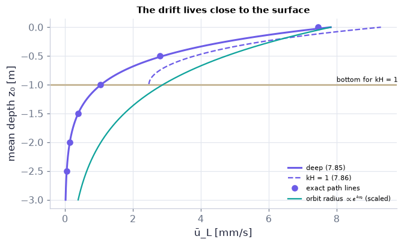

```python
k, a = 1.0, 0.05                                            # ka = 0.05 [rad/m, m]
z0 = np.linspace(-3, 0, 200)                                # mean depths [m]
fig, ax = plt.subplots(figsize=(6, 3.6))                    # drift profile
ax.plot(ch07.stokes_drift(z0, a, k)*1e3, z0, color=COLORS["accent"], lw=2, label="deep (7.85)")   # deep water [mm/s]
zH = z0[z0 >= -1.0]                                         # only above the bottom of the H = 1 m case [m]
ax.plot(ch07.stokes_drift(zH, a, k, 1.0)*1e3, zH, "--", color=COLORS["accent"], lw=1.5, label="kH = 1 (7.86)")   # finite depth H = 1 m
ax.axhline(-1.0, color="#c8b99a", lw=2); ax.text(8, -0.95, "bottom for kH = 1", fontsize=7)   # where the H = 1 m case ends
zd = np.linspace(-2.5, 0, 6)                                # six depths for the numerical drift [m]
ax.plot([ch07.stokes_drift_numeric(z, a, k, periods=20 if not FAST else 10)*1e3 for z in zd], zd, "o",   # drift measured on exact path lines
        color=COLORS["accent"], label="exact path lines")   # … as dots
ax.plot(ch07.stokes_drift(0.0, a, k)*1e3*np.exp(k*z0), z0, color=COLORS["teal"], lw=1.5,   # orbit size ∝ e^{kz₀}, scaled
        label=r"orbit radius $\propto e^{kz_0}$ (scaled)")           # decay of the orbits, for comparison
ax.set_xlabel("ū_L [mm/s]"); ax.set_ylabel("mean depth z₀ [m]"); ax.legend(fontsize=7)   # axes and legend
ax.set_title("The drift lives close to the surface", fontsize=10)   # the message
savefig(fig, "ch07", "c12_drift_profile"); plt.show()   # save, then draw
```

**What you see.** The drift (purple) falls twice as fast with depth as the orbit size (teal, scaled to the same surface value); the numerical dots from exact path lines sit on the deep-water curve; the dashed curve is the finite-depth (7.86), $\bar u_L=a^2\omega k\frac{\cosh 2k(z_0+H)}{2\sinh^2kH}$ with kH = 1.

**How to read it.** $e^{2kz_0}$ vs $e^{kz_0}$: one wavelength down ($z_0=-\lambda$) the orbit keeps $e^{-2\pi}\approx0.2$ % and the drift $e^{-4\pi}\approx4\times10^{-6}$.

**What would change if…** …the depth were finite (kH = 1): the drift does not vanish at the bottom — cosh 2k(z₀ + H) ≥ 1 (dashed).

```python
k, a = 1.0, 0.25                                            # a steep deep-water wave, ka = 0.25 [rad/m, m]
w = ch07.omega_gravity(k); T = 2*np.pi/w                    # ω [rad/s], period [s]
z0s = np.linspace(-2.0, 0.0, 9)                             # nine particles on a vertical line at x = 0 [m]
nf = 50 if not FAST else 25                                 # frames over five periods
tt = np.linspace(0, 5*T, nf)                                # frame times [s]
dl = ch07.dyed_line(z0s, tt, a, k)                          # exact path lines of all particles, all times (one solve_ivp)
fig, ax = plt.subplots(figsize=(7, 3.4))
xs = np.linspace(-np.pi, 2*np.pi, 300)                      # surface points [m]
(surf,) = ax.plot(xs, a*np.cos(k*xs), color=COLORS["blue"], lw=2)
trails = [ax.plot([], [], color=COLORS["teal"], lw=0.8)[0] for _ in z0s]   # each particle's open loop so far
(line,) = ax.plot(dl["x"][0], dl["z"][0], color=COLORS["rose"], lw=2)      # the dyed line
dots = ax.scatter(dl["x"][0], dl["z"][0], s=14, color=COLORS["teal"], zorder=3)
ax.set_xlim(-np.pi, 2*np.pi); ax.set_ylim(-2.4, 0.5); ax.set_aspect("equal"); ax.set_xlabel("x [m]"); ax.set_ylabel("z [m]")


def update(i):   # draw frame i
    surf.set_ydata(a*np.cos(k*xs - w*tt[i]))                 # the linear surface (the particles follow (7.33))
    for j, tr in enumerate(trails):                          # the loops traced up to now
        tr.set_data(dl["x"][:i + 1, j], dl["z"][:i + 1, j])
    line.set_data(dl["x"][i], dl["z"][i]); dots.set_offsets(np.c_[dl["x"][i], dl["z"][i]])
    ax.set_title(f"exact path lines, ka = 0.25: after {tt[i]/T:.1f} periods the dye line leans forward", fontsize=9)
    return []   # nothing to blit


show_animation(animate(update, frames=nf, fig=fig, interval=60))
```

[video not shown]

**What you see.** Nine particles released on a vertical line under a steep wave: each goes round an open loop (teal trail) and the rose dye line through them tilts forward period by period — our version of Fig. 7.22 `N188`, the `A4` animation.

**How to read it.** The top of the dye line runs ahead; after a few periods the line is curved like $e^{2kz_0}$ — the drift profile of the previous figure.

**What would change if…** …ka were halved: the drift falls by four (∝ a²) while the loops shrink only by two.

#### 🎮 Interactive: What does the water under a wave actually do?

**Why interactive rather than a static figure:** Tracer particles loop under the moving surface; drag the depth to squash circles into ellipses, then switch the model from linear to exact and watch the loops open and the dyed column lean forward. Motion and one model toggle are the whole lesson.

**What to try:**

- Start in *deep water*, click a particle at 1 m depth and read its A, B in the inspector.
- Drag kH to 0.3: the circles become flat ellipses; the bottom particle only slides.
- Choose *steep deep wave (exact)*: after five periods read the drift in the end-of-run card and compare with $a^2\omega k$.
- Open the Derivation (D27) at 'average the two terms'.

```python
show_viz("ch07", "particle_orbits")   # full-width explainer; ⤢ Full screen for more room
```

🎮 Interactive 7/9 What does the water under a wave actually do? Open alone ↗

[interactive chart not shown]

> ⚠️ **Common confusion:** "the mean current is zero" and "the water drifts" are both true. A fixed meter averages over whatever water passes it (zero); a float averages following one parcel ($a^2\omega ke^{2kz_0}$). Ch. 13 adds the Earth's rotation, and the Stokes drift then drives the Stokes–Coriolis force and Langmuir circulation in the ocean's surface layer.

**What would change if…** …the waves broke? Breaking transfers momentum to the water as a real (Eulerian) current — the longshore currents and undertow of beaches — which the irrotational theory here cannot describe.

## 7.7 Waves on a Density Interface

**What is this section about?** Replace the air above the water by a slightly lighter liquid — fresh water over salt water, warm water over cold. Gravity still restores the interface, but only through the small density difference: the waves become slow and tall. With a free surface on top, a layer of fluid can oscillate in two ways — the surface way and the interface way — the barotropic and baroclinic modes that layered ocean and atmosphere models are built on.

> 🔁 **Recap — Laplace in each fluid** (Ch. 6 §6.2). Each fluid is irrotational and incompressible on its own side, so $\nabla^2\phi_1=0,\ \nabla^2\phi_2=0$ *(7.90)*: one Laplace equation per layer (Ch. 6 §6.2, recap R02).

### 🧩 Interfacial waves `C13`

*The question:* How does a wave on a weak density step differ from a wave on the sea surface?

*In one line:* $\omega=\sqrt{gk\frac{\rho_2-\rho_1}{\rho_2+\rho_1}}=\varepsilon\sqrt{gk}$ *(7.95)*

📝 **Note.** **The set-up** `N98` — A lighter fluid ρ₁ above a heavier one ρ₂, both infinitely deep, small slopes, no interfacial tension (the book's Fig. 7.24) — a fjord's fresh upper layer, a sun-warmed surface layer, oil on water.

#### The problem in plain words

In a fjord, a layer of river water floats on sea water; in summer a lake's warm surface layer floats on cold water. Their interface carries waves you cannot see from a boat but a thermometer string can: slow, and metres tall. We want their speed and why they are so different from surface waves.

#### The idea

Gravity pulls a raised piece of interface down with the weight of the *difference* ρ₂ − ρ₁, but the inertia to be moved is both fluids, ρ₂ + ρ₁:

```
surface wave:    ω² = gk · (ρ − 0)/(ρ + 0)      = gk
interface wave:  ω² = gk · (ρ₂ − ρ₁)/(ρ₂ + ρ₁)  = ε² gk    ε ≈ 0.03 for Δρ/ρ = 0.002
```

**A small density step makes a slow wave — and the two fluids slide past each other.**

> 📎 **Primer — complex amplitudes.** `P176` · Write a real wave as the real part of a complex one, $\zeta=\mathrm{Re}\{a\,e^{i(kx-\omega t)}\}$, and drop the Re during linear algebra: ∂/∂x becomes multiplication by ik and ∂/∂t by −iω, and a complex amplitude $b=\lvert b\rvert e^{i\varphi}$ carries both size and phase shift (Ch. 1 P45 Euler's formula; Ch. 6 P153). ⚠️ Take real parts before multiplying two fields (energy, flux: C16).

```python
import numpy as np                                # numbers
k, w, t = 1.0, 2.0, 0.3                           # wavenumber [rad/m], frequency [rad/s], time [s]
x = np.linspace(0, 1, 3)                          # three positions [m]
zeta = np.real(1.0*np.exp(1j*(k*x - w*t)))        # a cos(kx − ωt) with a = 1 m
dzdt = np.real(-1j*w*1.0*np.exp(1j*(k*x - w*t)))  # ∂/∂t ↦ −iω
print(np.allclose(dzdt, w*np.sin(k*x - w*t)))     # True: the same as differentiating the cosine
```

```
True
```

📝 **Note.** **Complex notation from here on** `N99, N100` — The book writes the interface as (7.89) with Re{} dropped; complex constants A, B, C, b carry phase shifts. `W.real_field(amp, phase)` returns the real part when we plot.

$$ \zeta(x,t)=a\exp[i(kx-\omega t)] \qquad \text{(7.89)} $$

📝 **Note.** **The two-fluid problem** `N101–N104` — Laplace in each fluid (7.90), $\nabla^2\phi_1=0,\ \nabla^2\phi_2=0$; $\phi_1\to0\ \text{as}\ z\to\infty$ *(7.91)*; $\phi_2\to0\ \text{as}\ z\to-\infty$ *(7.92)*; both fluids move with the interface, $\frac{\partial\phi_1}{\partial z}=\frac{\partial\phi_2}{\partial z}=\frac{\partial\zeta} {\partial t}\ \text{at}\ z=0$ *(7.93)*; and the pressure is continuous (no interfacial tension) — C02's conditions, now two-sided:

$$ \rho_1\frac{\partial\phi_1}{\partial t}+\rho_1g\zeta=\rho_2\frac{\partial\phi_2}{\partial t}+\rho_2g\zeta\ \text{at}\ z=0 \qquad \text{(7.94)} $$

> 🔁 **Tools from earlier chapters used here** (see `knowledge/primers.md`)
- **Euler's formula and i² = −1** — $e^{i\theta}=\cos\theta+i\sin\theta$, so $(-i\omega)(i\omega a/k)=\omega^2a/k$ (Ch. 1 P45).
- **the complex plane in numpy** — `1j` is i; `np.real`, `np.abs`, `np.angle` read a complex number (Ch. 6 P153).
- **np.linalg.solve with complex numbers** — `np.linalg.solve(A, b)` solves A·x = b; complex entries are fine (Ch. 2 P57).

#### 🧮 Derivation — Interfacial waves: $\omega=\varepsilon\sqrt{gk}$ `D28` (Eq. 7.95: $\omega=\sqrt{gk\frac{\rho_2-\rho_1}{\rho_2+\rho_1}}=\varepsilon\sqrt{gk}$)

**What we want to show.** Find the frequency of a wave on the interface between two deep fluids of densities ρ₁ (above) < ρ₂ (below).

**Assumptions.** Both fluids infinitely deep; linear; no interfacial tension; ρ₂ > ρ₁ (stable).

**The plan.**

1. Choose decaying potentials.
2. Two kinematic conditions give A and B.
3. The pressure condition gives ω.

**Tools we use** (each explained before this point): complex amplitudes (P176) · $e^{\pm kz}$ from Laplace (as D05) · matching coefficients.

**We start from**

$$ \begin{array}{l}\zeta(x,t)=a\exp[i(kx-\omega t)]\ \text{(7.89)} \\ \nabla^2\phi_1=0,\ \nabla^2\phi_2=0\ \text{(7.90)} \\ \phi_1\to0\ \text{as}\ z\to\infty\ \text{(7.91)} \\ \phi_2\to0\ \text{as}\ z\to-\infty\ \text{(7.92)} \\ \frac{\partial\phi_1}{\partial z}=\frac{\partial\phi_2}{\partial z}=\frac{\partial\zeta}{\partial t}\ \text{at}\ z=0\ \text{(7.93)} \\ \rho_1\frac{\partial\phi_1}{\partial t}+\rho_1g\zeta=\rho_2\frac{\partial\phi_2}{\partial t}+\rho_2g\zeta\ \text{at}\ z=0\ \text{(7.94)}\end{array} $$

*In words:* the interface problem: a wave on the interface, Laplace in each fluid, decay far away, and the kinematic and pressure conditions at z = 0

**Step 1 of 10 — Write the interface in complex form.**

$$ \zeta=ae^{i(kx-\omega t)}\ \text{(7.89)} $$

- *Why we can do this:* Complex notation (P176): Re is taken at the end; derivatives become multiplications.
- *In words:* the interface displacement.

**Step 2 of 10 — Choose decaying potentials.**

$$ \phi_1=Ae^{-kz}e^{i(kx-\omega t)},\quad\phi_2=Be^{kz}e^{i(kx-\omega t)} $$

- *Why we can do this:* Laplace gives $e^{\pm kz}$ (as D05); (7.91), $\phi_1\to0\ \text{as}\ z\to\infty$ forbids $e^{kz}$ above (it grows as z → ∞), (7.92), $\phi_2\to0\ \text{as}\ z\to-\infty$ forbids $e^{-kz}$ below.
- *In words:* each fluid's motion dies away from the interface.

**Step 3 of 10 — Differentiate at z = 0.**

$$ \frac{\partial\phi_1}{\partial z}=-kA\,e^{i\theta},\ \frac{\partial\phi_2}{\partial z}=kB\,e^{i\theta},\ \frac{\partial\zeta}{\partial t}=-i\omega a\,e^{i\theta} $$

- *Why we can do this:* d/dz $e^{\mp kz}$ = ∓k at z = 0; ∂/∂t brings −iω (P176); θ = kx − ωt.
- *In words:* both vertical velocities and the interface's rise rate.

**Step 4 of 10 — Apply the upper kinematic condition.**

$$ -kA=-i\omega a\ \Rightarrow\ A=\frac{i\omega a}k $$

- *Why we can do this:* (7.93), $\frac{\partial\phi_1}{\partial z}=\frac{\partial\phi_2}{\partial z}=\frac{\partial\zeta}{\partial t}\ \text{at}\ z=0$ for fluid 1; cancel $e^{i\theta}$ (it holds for all x, t).
- *In words:* the upper fluid follows the interface.

**Step 5 of 10 — Apply the lower kinematic condition.**

$$ kB=-i\omega a\ \Rightarrow\ B=-\frac{i\omega a}k $$

- *Why we can do this:* The lower fluid also moves with the interface, (7.93) ∂φ₂/∂z = ∂ζ/∂t at z = 0; cancel $e^{i\theta}$ again.
- *In words:* A = −B: the two potentials are opposite.

**Step 6 of 10 — Differentiate the potentials in time.**

$$ \frac{\partial\phi_1}{\partial t}=\frac{\omega^2a}k e^{i\theta},\quad\frac{\partial\phi_2}{\partial t}= -\frac{\omega^2a}k e^{i\theta} $$

- *Why we can do this:* ∂/∂t → −iω: (−iω)(iωa/k) = ω²a/k and (−iω)(−iωa/k) = −ω²a/k.
- *In words:* the pressure-producing parts, opposite in the two fluids.

**Step 7 of 10 — Insert into the pressure condition.**

$$ \rho_1\frac{\omega^2a}k+\rho_1ga=-\rho_2\frac{\omega^2a}k+\rho_2ga $$

- *Why we can do this:* (7.94), $\rho_1\frac{\partial\phi_1}{\partial t}+\rho_1g\zeta=\rho_2\frac{\partial\phi_2}{\partial t}+\rho_2g\zeta\ \text{at}\ z=0$ with ζ = $ae^{i\theta}$; cancel $e^{i\theta}$.
- *In words:* pressure matches across the interface.

**Step 8 of 10 — Collect the ω² terms.**

$$ \frac{\omega^2}k(\rho_1+\rho_2)=g(\rho_2-\rho_1) $$

- *Why we can do this:* Move ω² terms left, g terms right; divide by a ≠ 0.
- *In words:* the inertia of both fluids against the weight difference.

**Step 9 of 10 — Solve for ω.**

$$ \omega=\sqrt{gk\frac{\rho_2-\rho_1}{\rho_2+\rho_1}}=\varepsilon\sqrt{gk}\ \text{(7.95),}\ \varepsilon^2\equiv\frac{\rho_2-\rho_1} {\rho_2+\rho_1} $$

- *Why we can do this:* Multiply by k/(ρ₁ + ρ₂); positive root.
- *In words:* a deep-water wave slowed by ε.

**Step 10 of 10 — Check the air–water limit.**

$$ \frac{\rho_1}{\rho_2}\to0\ \Rightarrow\ \varepsilon\to1,\ \omega=\sqrt{gk} $$

- *Why we can do this:* With a negligible upper density the interface is a free surface: (7.45), $c=\sqrt{g/k}=\sqrt{g\lambda/2\pi}$.
- *In words:* the surface wave is recovered.

**Result**

$$ \omega=\varepsilon\sqrt{gk},\ \ \varepsilon^2=\frac{\rho_2-\rho_1}{\rho_2+\rho_1}\ \text{(7.95)};\qquad u_1=-\omega ae^{-kz}e^{i\theta},\ \ u_2=\omega ae^{kz}e^{i\theta}\ \text{(note N107)} $$

**What it means.** Weak stratification makes slow, tall waves; the velocity jumps across the interface — a vortex sheet, the seed of Kelvin–Helmholtz instability.

**Check it.** Units ✓. Δρ = 2 on 1000 kg/m³, λ = 100 m: T = 253 s vs 8.0 s at the surface ✓. `np.linalg.solve` from scratch agrees ✓. ρ₁ > ρ₂ gives ω² < 0: growth (Rayleigh–Taylor, Ch. 11).

> ⚠️ **Common confusion (traps in `D28`):** Letting φ₁ grow upward; forgetting the minus from −iω; cancelling ρ₁ terms with the wrong sign.

#### ✏️ Tiny example: a thermocline wave

ρ₁ = 1000, ρ₂ = 1002 kg/m³, λ = 100 m.

1. $\varepsilon^2=2/2002=9.99\times10^{-4}$, ε = 0.0316.
2. A surface wave of this length: $\omega=\sqrt{gk}=0.785$ rad/s, T = 8.0 s.
3. The interfacial wave: ω = 0.0316 × 0.785 = 0.0248 rad/s, T = 253 s ≈ 4.2 min — 32 times slower.
4. The same energy as a 1 m surface wave needs $a=\sqrt{\rho/\Delta\rho}\times1\ \text{m}=\sqrt{500}=22$ m.

> 📎 **Primer — warnings.catch_warnings(record=True).** `P183` · A Python *warning* is a message a function raises without stopping ("this input makes no physical sense; returning NaN"). Inside `with warnings.catch_warnings(record=True) as caught:` every warning is collected into the list `caught` instead of being printed, and `warnings.simplefilter("always")` makes sure none is suppressed as a repeat. We then print the message ourselves, next to the result it explains.

```python
import warnings                                           # Python's warning system
with warnings.catch_warnings(record=True) as caught:      # collect warnings in the list `caught`
    warnings.simplefilter("always")                       # do not hide repeats
    warnings.warn("heavier fluid on top")                 # a function would raise this
print(len(caught), caught[0].message)                     # 1 heavier fluid on top
```

```
1 heavier fluid on top
```

```python
k = 2*np.pi/100                                            # λ = 100 m [rad/m]
print(f"ω interface = {ch07.interface_omega(k, 1000.0, 1002.0):.5f} rad/s, surface √(gk) = {ch07.omega_gravity(k):.4f} rad/s")   # (7.95) vs (7.45)
f = ch07.interface_fields(np.array([0.0, 25.0]), np.array([0.0, 0.0]), 0.0, 1.0, k, 1000.0, 1002.0)   # a = 1 m, at a crest and a node
print("u₁ (above) =", f["u1"], " u₂ (below) =", f["u2"], " sheet strength u₂ − u₁ =", f["gamma_sheet"], "m/s")   # opposite velocities
print({n: f"{np.max(np.abs(v)):.1e}" for n, v in ch07.interface_residuals(10.0, 3.0, 1.0, k, 1000.0, 1002.0).items()})   # residuals of (7.90)–(7.94)
print(ch07.interface_energy(1.0, k, 1000.0, 1002.0), ch07.interface_energy(1.0, k, 1000.0, 1002.0, method="quad"))   # closed form and dblquad
with warnings.catch_warnings(record=True) as caught:      # heavy fluid on top: the code refuses a real ω
    warnings.simplefilter("always")   # show every warning
    print("ρ₁ = 1002 over ρ₂ = 1000:", ch07.interface_omega(k, 1002.0, 1000.0), "—", str(caught[0].message)[:60], "…")   # NaN and the reason
```

```
ω interface = 0.02481 rad/s, surface √(gk) = 0.7851 rad/s
u₁ (above) = [-0.0248  0.    ]  u₂ (below) = [ 0.0248 -0.    ]  sheet strength u₂ − u₁ = [ 0.0496 -0.    ] m/s
{'laplace1': '4.0e-15', 'laplace2': '3.9e-15', 'far1': '8.8e-19', 'far2': '8.8e-19', 'kinematic1': '0.0e+00', 'kinematic2': '0.0e+00', 'dynamic': '0.0e+00'}
```

```
{'Ek': 4.905, 'Ep': 4.905, 'E': 9.81} {'Ek': 4.905000000000001, 'Ep': 4.904999999999999, 'E': 9.809999999999999}
ρ₁ = 1002 over ρ₂ = 1000: nan — rho1 > rho2: heavy fluid over light — omega^2 < 0 (Rayleigh– …
```

**What does the code above do?**

1. ω = 0.02481 rad/s against 0.7851 rad/s at the surface: 32 times slower.
2. Under the crest (x = 0) the upper fluid moves backward and the lower one forward at 0.0248 m/s: the interface is a vortex sheet of strength $u_2-u_1=0.0496$ m/s (note N107).
3. The residuals of (7.90)–(7.94), $\nabla^2\phi_1=0,\ \nabla^2\phi_2=0,\ \phi_1\to0\ \text{as}\ z\to\infty,\ \phi_2\to0\ \text{as}\ z\to-\infty,\ \frac{\partial\phi_1}{\partial z}=\frac{\partial\phi_2}{\partial z}=\frac{\partial\zeta}{\partial t}\ \text{at}\ z=0,\ \rho_1\frac{\partial\phi_1}{\partial t}+\rho_1g\zeta=\rho_2\frac{\partial\phi_2}{\partial t}+\rho_2g\zeta\ \text{at}\ z=0$ are at round-off.
4. $E_k=E_p=4.905$ J/m² and E = 9.81 J/m² for a = 1 m — a quarter of Δρga² each — both in closed form and by `dblquad`.
5. Heavy fluid on top: ω² < 0, so the code returns NaN with a warning — the Rayleigh–Taylor instability of Ch. 11.

```python
a, rho1, rho2 = 1.0, 1000.0, 1002.0                       # amplitude [m]; upper, lower density [kg/m³]
al, be = np.linalg.solve(np.array([[-k, 0], [0, k]], dtype=complex), np.array([-1j*a, -1j*a]))   # (7.93) per unit ω: −kA = kB = −iωa
print("A/ω =", al, " B/ω =", be, " (= ±ia/k)")            # so A = iωa/k, B = −iωa/k (D28 steps 4–5)
# (7.94) with ∂/∂t → −iω and A = ω·al, B = ω·be:  ω²(−iρ₁al + iρ₂be) = (ρ₂ − ρ₁) g a  — linear in ω²
w2_mine = (rho2 - rho1)*G*a/(-1j*rho1*al + 1j*rho2*be)     # ω² [1/s²] (a real number)
w_mine = np.sqrt(w2_mine.real)                             # ω [rad/s]
print(f"ω from our two solves: {w_mine:.6f} rad/s")
assert np.allclose(w_mine, ch07.interface_omega(k, rho1, rho2), rtol=1e-12)   # D28 step 9: ω = ε√(gk)
```

```
A/ω = (-0+15.915494309189533j)  B/ω = -15.915494309189533j  (= ±ia/k)
ω from our two solves: 0.024815 rad/s
```

📝 **Note.** **Interfacial energy** `N105, N106` — The kinetic and potential energies are equal, $E_k=E_p=\tfrac14(\rho_2-\rho_1)ga^2$ (the column swap of C06 now lifts ρ₂ and lowers ρ₁ — the book's Fig. 7.25 `N191` is that sketch with a second fluid, not redrawn), so the total is (7.96): for the same energy an interfacial wave is $\sqrt{\rho_2/(\rho_2-\rho_1)}$ times taller than a surface wave (22× for the thermocline above).

$$ E=\tfrac12(\rho_2-\rho_1)ga^2 \qquad \text{(7.96)} $$

📝 **Note.** **The interface is a vortex sheet** `N107` — The horizontal velocities $u_1=\partial\phi_1/\partial x=-\omega ae^{-kz}e^{i(kx-\omega t)}$ and $u_2=\omega ae^{kz}e^{i(kx- \omega t)}$ are opposite: the interface is a **vortex sheet** of strength $u_2-u_1=2\omega a\cos(kx-\omega t)$ (the jump of Ch. 5's vortex sheets) — the seed of the Kelvin–Helmholtz instability (Ch. 11). A continuous stratification spreads this vorticity through the fluid, so internal waves (C15) are not irrotational. Ch. 5's function (counterclockwise convention, $\gamma=u_{below}-u_{above}$) gives the same number:

```python
print(ch05.vortex_sheet_strength(u_above=f["u1"][0], u_below=f["u2"][0]), "=", f["gamma_sheet"][0], "m/s")   # at the crest
```

```
0.04962921373225238 = 0.04962921373225238 m/s
```

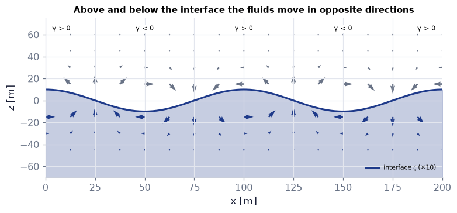

```python
k, a = 2*np.pi/100, 1.0                                    # λ = 100 m, a = 1 m
xs = np.linspace(0, 200, 400)                              # two wavelengths [m]
zs = np.array([-60, -45, -30, -15, 15, 30, 45, 60.0])      # heights of the arrow rows, away from the interface [m]
XX, ZZ = np.meshgrid(np.linspace(0, 200, 17), zs)          # arrow grid
f = ch07.interface_fields(XX, ZZ, 0.0, a, k, 1000.0, 1002.0)   # u, w in the fluid on each side (real parts)
fig, ax = plt.subplots(figsize=(7, 3.2))
ax.fill_between(xs, -70, 10*np.cos(k*xs), color=NAVY, alpha=0.25)   # lower (denser) fluid, interface ×10 for visibility
ax.plot(xs, 10*np.cos(k*xs), color=NAVY, lw=2, label=r"interface $\zeta$ (×10)")
up = ZZ > 0                                                 # arrows above (light) and below (navy)
ax.quiver(XX[up], ZZ[up], f["u"][up], f["w"][up], color=COLORS["muted"], scale=0.4, width=0.004)
ax.quiver(XX[~up], ZZ[~up], f["u"][~up], f["w"][~up], color=NAVY, scale=0.4, width=0.004)
for xc in (8, 100, 192): ax.text(xc, 64, "γ > 0", fontsize=7, ha="center", bbox=dict(facecolor="white", edgecolor="none", pad=1))   # sheet strength positive above crests
for xc in (50, 150): ax.text(xc, 64, "γ < 0", fontsize=7, ha="center", bbox=dict(facecolor="white", edgecolor="none", pad=1))       # and negative above troughs
ax.set_xlim(0, 200); ax.set_ylim(-70, 75); ax.set_xlabel("x [m]"); ax.set_ylabel("z [m]"); ax.legend(fontsize=7, loc="lower right")
ax.set_title("Above and below the interface the fluids move in opposite directions", fontsize=10)
savefig(fig, "ch07", "c13_interface"); plt.show()
```

**What you see.** Above and below the interface (navy line, height ×10) the arrows point in opposite directions; the sheet strength changes sign between crests and troughs (our remake of Fig. 7.24 `N190`).

**How to read it.** The arrows shrink like $e^{-k\lvert z\rvert}$: the motion is confined to about a wavelength around the interface.

**What would change if…** …ρ₁ → 0 (air over water): the upper arrows vanish and (7.95), $\omega=\sqrt{gk\frac{\rho_2-\rho_1}{\rho_2+\rho_1}}=\varepsilon\sqrt{gk}$ returns $\omega=\sqrt{gk}$, the deep-water wave of C04.

📝 **Note.** **Dead water** `N108, N192` — A ship in a fjord with a thin fresh layer makes interfacial waves and feels an unexpected drag — Bjerknes' explanation of the old sailors' puzzle (the book's Fig. 7.26; two-layer flows return in Ch. 13).

**What would change if…** …the upper layer had a free surface a finite distance above? A second wave (on the surface) enters and the two interact — C14's barotropic and baroclinic modes.

### 🧩 Barotropic and baroclinic modes; reduced gravity `C14`

*The question:* What are the two ways a layer over deep water can oscillate — and why is one of them almost invisible at the surface?

*In one line:* $c=[g'H]^{1/2}$ *(7.116)* · $g'=g\Big(\frac{\rho_2-\rho_1}{\rho_2}\Big)$ *(7.117)*

📝 **Note.** **The set-up** `N109` — (the book's Fig. 7.27) An upper layer of thickness H with a free surface, over an infinitely deep lower layer; the origin at the mean free surface, the interface at z = −H. Two modes: surface and interface in phase, or in antiphase.

#### The problem in plain words

The summer thermocline of a lake sits 10–50 m down; tides and winds move both the surface and the thermocline. Ocean models are built from exactly two kinds of motion: the barotropic one, which moves the whole column and shows at the surface, and the baroclinic one, which heaves the thermocline by metres while the surface barely twitches. We want both from one calculation.

#### The idea

```
barotropic:  surface ~~~   interface ~ (in phase, smaller by e^{−kH})     ω² = gk          fast
baroclinic:  surface ~ (tiny, antiphase)   interface ~~~~~ (large)        ω² ≈ g′kH·k      slow
```

📝 **Note.** **The problem** `N110–N118` — $\phi_2\to0\ \text{at}\ z\to-\infty$ *(7.97)*; $\frac{\partial\phi_1}{\partial z}=\frac{\partial\eta}{\partial t}\ \text{at}\ z=0$ *(7.98)* (the book prints ∂φ₁/dz; read ∂z); $\frac{\partial\phi_1}{\partial t}+g\eta=0\ \text{at}\ z=0$ *(7.99)*; $\frac{\partial\phi_1}{\partial z}=\frac{\partial\phi_2}{\partial z}=\frac{\partial\zeta}{\partial t}\ \text{at}\ z=-H$ *(7.100)*; $\rho_1\frac{\partial\phi_1}{\partial t}+\rho_1g\zeta=\rho_2\frac{\partial\phi_2}{\partial t}+\rho_2g\zeta\ \text{at}\ z=-H$ *(7.101)*; with $\eta=ae^{i(kx-\omega t)}$ *(7.102)* (a real), $\zeta=be^{i(kx-\omega t)}$ *(7.103)* (b complex: a phase difference is allowed), $\phi_1=(Ae^{kz}+Be^{-kz})e^{i(kx-\omega t)}$ *(7.104)* and $\phi_2=Ce^{kz}e^{i(kx-\omega t)}$ *(7.105)*. The book prints (7.105) with $e^{i(kz-\omega t)}$; that cannot satisfy Laplace's equation or (7.100) for all x — `ch07.two_layer_sympy()["printed_7105_residual"]` ≠ 0 shows it (printed in D29's check).

> 🔁 **Tools from earlier chapters used here** (see `knowledge/primers.md`)
- **complex 2 × 2 systems and factorising in sympy** — `sp.solve` handles complex unknowns, `sp.I` is i, `sp.factor` exposes common factors (Ch. 6 P158).

#### 🧮 Derivation — The two-layer constants `D29` (Eq. 7.109: $b=\frac a2\Big(1+\frac{gk}{\omega^2}\Big)e^{-kH}+\frac a2\Big(1-\frac{gk}{\omega^2}\Big)e^{kH}$)

**What we want to show.** For a layer of thickness H with a free surface over a deep fluid, express the flow and the interface amplitude through the surface amplitude a and ω.

**Assumptions.** Linear; lower layer infinitely deep; a real; b complex (a phase difference is allowed).

**The plan.**

1. Write the potentials.
2. Surface conditions give A, B.
3. Interface kinematics gives C and b.

**Tools we use** (each explained before this point): complex amplitudes (P176) · two linear equations (as D05) · sympy for complex systems (P158).

**We start from**

$$ \begin{array}{l}\phi_2\to0\ \text{at}\ z\to-\infty\ \text{(7.97);}\ \frac{\partial\phi_1}{\partial z}=\frac{\partial\eta}{\partial t}\ \text{at z = 0 (7.98);}\ \frac{\partial\phi_1}{\partial t}+g\eta=0\ \text{at z} \\ \text{= 0 (7.99);}\ \frac{\partial\phi_1}{\partial z}=\frac{\partial\phi_2}{\partial z}=\frac{\partial\zeta}{\partial t}\ \text{at z = −H (7.100);}\ \eta=ae^{i(kx-\omega t)} \\ \text{(7.102),}\ \zeta=be^{i(kx-\omega t)}\ \text{(7.103).}\end{array} $$

**Step 1 of 12 — Write the complex surfaces.**

$$ \eta=ae^{i\theta},\quad\zeta=be^{i\theta},\quad\theta=kx-\omega t\ \text{(7.102), (7.103)} $$

- *Why we can do this:* Both boundaries oscillate with the same k and ω; a real sets the phase origin; b may be complex.
- *In words:* surface and interface waves.

**Step 2 of 12 — Write the layer potentials.**

$$ \phi_1=(Ae^{kz}+Be^{-kz})e^{i\theta}\ \text{(7.104),}\ \phi_2=Ce^{kz}e^{i\theta}\ \text{(7.105)} $$

- *Why we can do this:* Laplace gives $e^{\pm kz}$; the finite upper layer keeps both; (7.97), $\phi_2\to0\ \text{at}\ z\to-\infty$ keeps only $e^{kz}$ below. The book prints (7.105), $\phi_2=Ce^{kz}e^{i(kx-\omega t)}$ with $e^{i(kz-\omega t)}$: read $e^{i(kx-\omega t)}$.
- *In words:* four unknowns A, B, C, b.

**Step 3 of 12 — Apply the surface kinematic condition.**

$$ k(A-B)=-i\omega a $$

- *Why we can do this:* (7.98), $\frac{\partial\phi_1}{\partial z}=\frac{\partial\eta}{\partial t}\ \text{at}\ z=0$ at z = 0: ∂φ₁/∂z = k(A − B)$e^{i\theta}$, ∂η/∂t = −iω$ae^{i\theta}$; cancel $e^{i\theta}$.
- *In words:* the upper layer follows the free surface.

**Step 4 of 12 — Apply the surface dynamic condition.**

$$ -i\omega(A+B)+ga=0\ \Rightarrow\ A+B=-\frac{iga}{\omega} $$

- *Why we can do this:* (7.99), $\frac{\partial\phi_1}{\partial t}+g\eta=0\ \text{at}\ z=0$ at z = 0: ∂φ₁/∂t = −iω(A + B)$e^{i\theta}$; 1/i = −i.
- *In words:* the free surface stays at atmospheric pressure.

**Step 5 of 12 — Solve for A.**

$$ A=-\frac{ia}2\Big(\frac\omega k+\frac g\omega\Big)\ \text{(7.106)} $$

- *Why we can do this:* A = ½[(A − B) + (A + B)] with A − B = −iωa/k.
- *In words:* first constant.

**Step 6 of 12 — Solve for B.**

$$ B=\frac{ia}2\Big(\frac\omega k-\frac g\omega\Big)\ \text{(7.107)} $$

- *Why we can do this:* B = ½[(A + B) − (A − B)].
- *In words:* second constant.

**Step 7 of 12 — Match vertical velocities at the interface.**

$$ k(Ae^{-kH}-Be^{kH})=kCe^{-kH} $$

- *Why we can do this:* (7.100), $\frac{\partial\phi_1}{\partial z}=\frac{\partial\phi_2}{\partial z}=\frac{\partial\zeta}{\partial t}\ \text{at}\ z=-H$, first equality at z = −H: ∂φ₁/∂z = k($Ae^{kz}$ − $Be^{-kz}$) and ∂φ₂/∂z = kC$e^{kz}$, both at z = −H.
- *In words:* the layers move together vertically at the interface.

**Step 8 of 12 — Solve for C.**

$$ C=A-Be^{2kH}=-\frac{ia}2\Big(\frac\omega k+\frac g\omega\Big)-\frac{ia}2\Big(\frac\omega k-\frac g\omega\Big)e^{2kH}\ \text{(7.108)} $$

- *Why we can do this:* Divide by $ke^{-kH}$; insert A and B.
- *In words:* third constant.

**Step 9 of 12 — Match with the interface motion.**

$$ k(Ae^{-kH}-Be^{kH})=-i\omega b $$

- *Why we can do this:* (7.100), $\frac{\partial\phi_1}{\partial z}=\frac{\partial\phi_2}{\partial z}=\frac{\partial\zeta}{\partial t}\ \text{at}\ z=-H$, second equality: ∂φ₁/∂z = ∂ζ/∂t = −iω$be^{i\theta}$ at z = −H.
- *In words:* the interface moves with the water.

**Step 10 of 12 — Solve for b.**

$$ b=\frac{ik}\omega\big(Ae^{-kH}-Be^{kH}\big) $$

- *Why we can do this:* Divide by −iω; 1/(−i) = i.
- *In words:* the interface amplitude from A and B.

**Step 11 of 12 — Insert A and B.**

$$ \frac{ik}\omega Ae^{-kH}=\frac a2\Big(1+\frac{gk}{\omega^2}\Big)e^{-kH},\quad-\frac{ik}\omega Be^{kH}=\frac a2\Big(1- \frac{gk}{\omega^2}\Big)e^{kH} $$

- *Why we can do this:* i·(−i) = 1 and −i·i = 1: (k/ω)(a/2)(ω/k + g/ω) = (a/2)(1 + gk/ω²), and likewise the second term.
- *In words:* two pieces of b.

**Step 12 of 12 — Add them.**

$$ b=\frac a2\Big(1+\frac{gk}{\omega^2}\Big)e^{-kH}+\frac a2\Big(1-\frac{gk}{\omega^2}\Big)e^{kH}\ \text{(7.109)} $$

- *Why we can do this:* Sum of step 11; b is real here (the modes will be exactly in or out of phase). ω is still unknown: (7.101), $\rho_1\frac{\partial\phi_1}{\partial t}+\rho_1g\zeta=\rho_2\frac{\partial\phi_2}{\partial t}+\rho_2g\zeta\ \text{at}\ z=-H$ fixes it (D30).
- *In words:* the interface amplitude.

**Result**

$$ \begin{array}{l}A=-\frac{ia}2\Big(\frac\omega k+\frac g\omega\Big)\ \text{(7.106)} \\ B=\frac{ia}2\Big(\frac\omega k-\frac g\omega\Big)\ \text{(7.107)} \\ C=-\frac{ia}2\Big(\frac\omega k+\frac g\omega\Big)-\frac{ia}2\Big(\frac\omega k-\frac g\omega\Big)e^{2kH}\ \text{(7.108)} \\ b=\frac a2\Big(1+\frac{gk}{\omega^2}\Big)e^{-kH}+\frac a2\Big(1-\frac{gk}{\omega^2}\Big)e^{kH}\ \text{(7.109)}\end{array} $$

*In words:* every constant in terms of a and ω

**What it means.** Everything is fixed by a and ω; the one remaining condition (pressure at the interface) will allow only two values of ω — two modes.

**Check it.** Units: A, B, C [m²/s]; b [m] ✓. H → 0 (no upper layer): b → a — the interface is the surface ✓.

```python
import sympy as sp                                         # symbolic algebra with complex numbers
x, z, t = sp.symbols('x z t', real=True)                   # coordinates and time
k, w, g, H, a = sp.symbols('k omega g H a', positive=True) # wavenumber, frequency, gravity, layer depth, surface amplitude
A, B, C, b = sp.symbols('A B C b')                         # unknown (complex) constants
E_ = sp.exp(sp.I*(k*x - w*t))                              # the common wave factor e^{iθ}
phi1 = (A*sp.exp(k*z) + B*sp.exp(-k*z))*E_                 # (7.104) upper-layer potential
phi2 = C*sp.exp(k*z)*E_                                    # (7.105) with e^{i(kx−ωt)} (the printed kz is a slip)
eta, zeta = a*E_, b*E_                                     # (7.102), (7.103)
eqs = [sp.diff(phi1, z).subs(z, 0) - sp.diff(eta, t),      # (7.98) surface kinematics — D29 step 3
       sp.diff(phi1, t).subs(z, 0) + g*eta,                # (7.99) surface dynamics — step 4
       (sp.diff(phi1, z) - sp.diff(phi2, z)).subs(z, -H),  # (7.100) first equality — step 7
       sp.diff(phi1, z).subs(z, -H) - sp.diff(zeta, t)]    # (7.100) second equality — step 9
sol = sp.solve([sp.simplify(e/E_) for e in eqs], [A, B, C, b], dict=True)[0]   # steps 5, 6, 8, 10
book = {A: -sp.I*a/2*(w/k + g/w), B: sp.I*a/2*(w/k - g/w),
        C: -sp.I*a/2*(w/k + g/w) - sp.I*a/2*(w/k - g/w)*sp.exp(2*k*H),
        b: a/2*(1 + g*k/w**2)*sp.exp(-k*H) + a/2*(1 - g*k/w**2)*sp.exp(k*H)}   # (7.106)–(7.109)
print("solved − book:", [sp.simplify(sol[s_] - book[s_]) for s_ in (A, B, C, b)])   # [0, 0, 0, 0]
phi2_printed = C*sp.exp(k*z)*sp.exp(sp.I*(k*z - w*t))      # the printed (7.105)
r = (sp.diff(phi1, z) - sp.diff(phi2_printed, z)).subs(z, -H).subs(sol)   # (7.100) with it, after steps 5–10
print("printed (7.105) satisfies (7.100) for every x:", sp.simplify(sp.diff(r, x)) == 0)   # False
print("library:", ch07.two_layer_sympy()["residuals"], "| printed Laplace residual:", ch07.two_layer_sympy()["printed_7105_residual"])
```

```
solved − book: [0, 0, 0, 0]
```

```
printed (7.105) satisfies (7.100) for every x: False
```

```
library: {'A_7_106': 0, 'B_7_107': 0, 'C_7_108': 0, 'b_7_109': 0, 'root_7_111': 0, 'root_7_113': 0, 'b_7_112': 0, 'eta_over_zeta_7_114': 0} | printed Laplace residual: 2*I*k**2
```

> ⚠️ **Common confusion (traps in `D29`):** Using the printed (7.105), $\phi_2=Ce^{kz}e^{i(kx-\omega t)}$; forgetting that b may be complex until the algebra shows it is real; signs of i.

📝 **Note.** **The constants** `N119–N122` — $A=-\frac{ia}2\big(\frac\omega k+\frac g\omega\big)$ *(7.106)*, $B=\frac{ia}2\big(\frac\omega k-\frac g\omega\big)$ *(7.107)*, $C=-\frac{ia}2\big(\frac\omega k+\frac g\omega\big)-\frac{ia}2\big(\frac\omega k-\frac g\omega\big)e^{2kH}$ *(7.108)* and (7.109) below.

$$ b=\frac a2\Big(1+\frac{gk}{\omega^2}\Big)e^{-kH}+\frac a2\Big(1-\frac{gk}{\omega^2}\Big)e^{kH} \qquad \text{(7.109)} $$

#### 🧮 Derivation — The two-layer dispersion relation `D30` (Eq. 7.110: $\Big(\frac{\omega^2}{gk}-1\Big)\Big\{\frac{\omega^2}{gk}[\rho_1\sinh kH+\rho_2\cosh kH]-(\rho_2-\rho_1)\sinh kH\Big\}=0$)

**What we want to show.** Use pressure continuity at the interface to find which ω are possible, and show the result factors into two modes. The book skips this algebra; we write it out move by move.

**Assumptions.** As D29; no interfacial tension.

**The plan.**

1. Evaluate (7.101), $\rho_1\frac{\partial\phi_1}{\partial t}+\rho_1g\zeta=\rho_2\frac{\partial\phi_2}{\partial t}+\rho_2g\zeta\ \text{at}\ z=-H$ with the constants.
2. Eliminate C, then A and B.
3. Introduce s = ω²/gk.
4. Factor out (s − 1) and turn exponentials into sinh and cosh.

**Tools we use** (each explained before this point): complex amplitudes (P176) · hyperbolic functions from exponentials (P168) · factorising (P158 in sympy) · D29.

**We start from**

$$ \begin{array}{l}\rho_1\frac{\partial\phi_1}{\partial t}+\rho_1g\zeta=\rho_2\frac{\partial\phi_2}{\partial t}+\rho_2g\zeta\ \text{at}\ z=-H\ \text{(7.101)} \\ A=-\frac{ia}2\Big(\frac\omega k+\frac g\omega\Big)\ \text{(7.106)} \\ B=\frac{ia}2\Big(\frac\omega k-\frac g\omega\Big)\ \text{(7.107)} \\ C=-\frac{ia}2\Big(\frac\omega k+\frac g\omega\Big)-\frac{ia}2\Big(\frac\omega k-\frac g\omega\Big)e^{2kH}\ \text{(7.108)} \\ b=\frac a2\Big(1+\frac{gk}{\omega^2}\Big)e^{-kH}+\frac a2\Big(1-\frac{gk}{\omega^2}\Big)e^{kH}\ \text{(7.109)}\end{array} $$

*In words:* the interface pressure condition, with the constants of D29 in terms of a and ω

**Step 1 of 12 — Write the interface pressure condition.**

$$ \rho_1\frac{\partial\phi_1}{\partial t}+\rho_1g\zeta=\rho_2\frac{\partial\phi_2}{\partial t}+ \rho_2g\zeta\ \text{at}\ z=-H\ \text{(7.101)} $$

- *Why we can do this:* Pressure is continuous across the interface (no tension); linear Bernoulli in each layer, applied at the mean interface.
- *In words:* the last condition — it fixes ω.

**Step 2 of 12 — Evaluate the time derivatives.**

$$ \frac{\partial\phi_1}{\partial t}=-i\omega(Ae^{-kH}+Be^{kH})e^{i\theta},\quad\frac{\partial\phi_2}{\partial t}= -i\omega Ce^{-kH}e^{i\theta} $$

- *Why we can do this:* ∂/∂t → −iω; set z = −H in (7.104), $\phi_1=(Ae^{kz}+Be^{-kz})e^{i(kx-\omega t)}$, (7.105), $\phi_2=Ce^{kz}e^{i(kx-\omega t)}$.
- *In words:* the pressure-producing parts.

**Step 3 of 12 — Collect the terms.**

$$ -i\omega\big[\rho_1(Ae^{-kH}+Be^{kH})-\rho_2Ce^{-kH}\big]=(\rho_2-\rho_1)gb $$

- *Why we can do this:* Cancel $e^{i\theta}$; move ρ₁gζ to the right.
- *In words:* inertia difference = weight difference.

**Step 4 of 12 — Replace $Ce^{-kH}$.**

$$ Ce^{-kH}=Ae^{-kH}-Be^{kH} $$

- *Why we can do this:* D29 step 7 (vertical velocities match).
- *In words:* eliminate C.

**Step 5 of 12 — Regroup by A and B.**

$$ -i\omega\big[(\rho_1-\rho_2)Ae^{-kH}+(\rho_1+\rho_2)Be^{kH}\big]=(\rho_2-\rho_1)gb $$

- *Why we can do this:* Expand ρ₁$Ae^{-kH}$ + ρ₁$Be^{kH}$ − ρ₂$Ae^{-kH}$ + ρ₂$Be^{kH}$.
- *In words:* two terms left.

**Step 6 of 12 — Insert −iωA and −iωB.**

$$ -i\omega A=-\frac a2\Big(\frac{\omega^2}k+g\Big),\quad-i\omega B=\frac a2\Big(\frac{\omega^2}k-g\Big) $$

- *Why we can do this:* From (7.106), $A=-\frac{ia}2\Big(\frac\omega k+\frac g\omega\Big)$, (7.107), $B=\frac{ia}2\Big(\frac\omega k-\frac g\omega\Big)$: (−iω)(−ia/2) = −ωa/2 and (−iω)(ia/2) = ωa/2.
- *In words:* the constants times −iω.

**Step 7 of 12 — Introduce s = ω²/gk.**

$$ \frac{\omega^2}k=gs,\qquad\frac{gk}{\omega^2}=\frac1s $$

- *Why we can do this:* One dimensionless unknown shortens the algebra; s = 1 is the deep-water surface wave.
- *In words:* measure ω² in units of gk.

**Step 8 of 12 — Write the equation in s.**

$$ (\rho_2-\rho_1)(s+1)e^{-kH}+(\rho_1+\rho_2)(s-1)e^{kH}=(\rho_2-\rho_1)\big[(1+\tfrac1s)e^{-kH}+(1-\tfrac1s)e^{kH}\big] $$

- *Why we can do this:* Steps 5–6 with b from (7.109), $b=\frac a2\Big(1+\frac{gk}{\omega^2}\Big)e^{-kH}+\frac a2\Big(1-\frac{gk}{\omega^2}\Big)e^{kH}$; multiply by 2/(ag); (ρ₁ − ρ₂)(−(s + 1)) = (ρ₂ − ρ₁)(s + 1).
- *In words:* one equation for s.

**Step 9 of 12 — Move all to the left and factor.**

$$ \frac{s-1}{s}\Big[(\rho_2-\rho_1)(s+1)e^{-kH}+\big((\rho_1+\rho_2)s-(\rho_2-\rho_1)\big)e^{kH}\Big]=0 $$

- *Why we can do this:* (s + 1) − (1 + 1/s) = (s − 1)(s + 1)/s, and (ρ₁ + ρ₂)(s − 1) − (ρ₂ − ρ₁)(1 − 1/s) = ((s − 1)/s)[(ρ₁ + ρ₂)s − (ρ₂ − ρ₁)].
- *In words:* a common factor (s − 1)/s appears.

**Step 10 of 12 — Keep the factor s − 1.**

$$ s-1=\frac{\omega^2}{gk}-1 $$

- *Why we can do this:* Do not cancel it as 'trivial': s = 1, ω² = gk, is a genuine solution — the surface wave (D31). 1/s ≠ 0 may be dropped.
- *In words:* one factor per mode.

**Step 11 of 12 — Turn the bracket into sinh and cosh.**

$$ s\big[(\rho_2-\rho_1)e^{-kH}+(\rho_1+\rho_2)e^{kH}\big]+(\rho_2-\rho_1)(e^{-kH}-e^{kH}) =2s(\rho_1\sinh kH+\rho_2\cosh kH)-2(\rho_2-\rho_1)\sinh kH $$

- *Why we can do this:* Collect the s-terms; ρ₂($e^{kH}$ + $e^{-kH}$) + ρ₁($e^{kH}$ − $e^{-kH}$) = 2ρ₂ cosh kH + 2ρ₁ sinh kH; $e^{-kH}$ − $e^{kH}$ = −2 sinh kH (P168).
- *In words:* exponentials become hyperbolic functions.

**Step 12 of 12 — Assemble.**

$$ \Big(\frac{\omega^2}{gk}-1\Big)\Big\{\frac{\omega^2}{gk}[\rho_1\sinh kH+\rho_2\cosh kH]-(\rho_2-\rho_1)\sinh kH\Big\}=0\ \text{(7.110)} $$

- *Why we can do this:* Divide by the nonzero factor 2/s. The full residual of (7.101), $\rho_1\frac{\partial\phi_1}{\partial t}+\rho_1g\zeta=\rho_2\frac{\partial\phi_2}{\partial t}+\rho_2g\zeta\ \text{at}\ z=-H$ is (ag²k/ω²) × this left side.
- *In words:* the two-layer dispersion relation.

**Result**

$$ \Big(\frac{\omega^2}{gk}-1\Big)\Big\{\frac{\omega^2}{gk}[\rho_1\sinh kH+\rho_2\cosh kH]-(\rho_2-\rho_1)\sinh kH\Big\}=0\ \text{(7.110)} $$

*In words:* two factors: two modes

**What it means.** One condition, two roots: a layered fluid supports two kinds of wave with the same wavelength.

**Check it.** kH → ∞: the brace gives ω² = gk(ρ₂ − ρ₁)/(ρ₂ + ρ₁) (7.95), $\omega=\sqrt{gk\frac{\rho_2-\rho_1}{\rho_2+\rho_1}}=\varepsilon\sqrt{gk}$ ✓. ρ₁ = ρ₂: the brace gives ω²(ρ sinh + ρ cosh) = 0 → no internal mode ✓. `np.roots` of the expanded quadratic in s agrees with `two_layer_free_surface_omega` to 1e-10 ✓.

```python
import sympy as sp                                              # symbolic algebra
k, w, g, H, a, r1, r2 = sp.symbols('k omega g H a rho1 rho2', positive=True)   # wave, layer and densities
A = -sp.I*a/2*(w/k + g/w); B = sp.I*a/2*(w/k - g/w)             # (7.106), (7.107)
C = A - B*sp.exp(2*k*H)                                         # (7.108), D29 step 8
b = sp.I*k/w*(A*sp.exp(-k*H) - B*sp.exp(k*H))                   # D29 step 10
lhs = -sp.I*w*(r1*(A*sp.exp(-k*H) + B*sp.exp(k*H)) - r2*C*sp.exp(-k*H))   # D30 step 3, left side
res = lhs - (r2 - r1)*g*b                                       # residual of (7.101) after cancelling e^{iθ}
s = w**2/(g*k)                                                  # step 7: s = ω²/gk
book = (s - 1)*(s*(r1*sp.sinh(k*H) + r2*sp.cosh(k*H)) - (r2 - r1)*sp.sinh(k*H))   # (7.110)
print("residual − (ag²k/ω²)·(7.110):", sp.simplify((res - a*g**2*k/w**2*book).rewrite(sp.exp)))   # 0 (step 12)
print("factored residual:", sp.factor(sp.simplify((res*w**2/(a*g**2*k)).rewrite(sp.exp))))   # shows (gk − ω²) (step 10)
print("library ratio (7.101)/(7.110):", ch07.two_layer_sympy()["common_factor"])   # a g² k/ω²
```

```
residual − (ag²k/ω²)·(7.110): 0
```

```
factored residual: -(g*k - omega**2)*(g*k*rho1*exp(2*H*k) - g*k*rho1 - g*k*rho2*exp(2*H*k) + g*k*rho2 + omega**2*rho1*exp(2*H*k) - omega**2*rho1 + omega**2*rho2*exp(2*H*k) + omega**2*rho2)*exp(-H*k)/(2*g**2*k**2)
library ratio (7.101)/(7.110): a*g**2*k/omega**2
```

> ⚠️ **Common confusion (traps in `D30`):** Cancelling (s − 1) as trivial; dropping the common factor ag²k/ω² without noting it is nonzero; sign slips with i² = −1.

📝 **Note.** **Two factors, two modes** `N123` — The product (7.110) vanishes when either factor does.

$$ \Big(\frac{\omega^2}{gk}-1\Big)\Big\{\frac{\omega^2}{gk}[\rho_1\sinh kH+\rho_2\cosh kH]-(\rho_2-\rho_1)\sinh kH\Big\}=0 \qquad \text{(7.110)} $$

#### 🧮 Derivation — Roots, mode shapes and long waves: $c=\sqrt{g'H}$ `D31` (Eq. 7.117: $g'=g\Big(\frac{\rho_2-\rho_1}{\rho_2}\Big)$)

**What we want to show.** Read the two modes out of (7.110), $\Big(\frac{\omega^2}{gk}-1\Big)\Big\{\frac{\omega^2}{gk}[\rho_1\sinh kH+\rho_2\cosh kH]-(\rho_2-\rho_1)\sinh kH\Big\}=0$: their frequencies, how the interface moves relative to the surface, and their long-wave speeds.

**Assumptions.** kH ≪ 1 for the long-wave steps (9–11); lower layer deep.

**The plan.**

1. First factor: the surface mode.
2. Second factor: the internal mode and its amplitude ratio.
3. Deep and long-wave limits.

**Tools we use** (each explained before this point): small-argument forms (P168) · D29, D30.

**We start from**

$$ \Big(\frac{\omega^2}{gk}-1\Big)\Big\{\frac{\omega^2}{gk}[\rho_1\sinh kH+\rho_2\cosh kH]-(\rho_2-\rho_1)\sinh kH\Big\}=0\ \text{(7.110)},\qquad b=\frac a2\Big(1+\frac{gk}{\omega^2}\Big)e^{-kH}+\frac a2\Big(1-\frac{gk}{\omega^2}\Big)e^{kH}\ \text{(7.109)} $$

*In words:* the two-layer dispersion relation and the interface amplitude

**Step 1 of 11 — Take the first factor.**

$$ \omega^2=gk\ \text{(7.111)} $$

- *Why we can do this:* s = 1 zeroes the first factor of (7.110), $\Big(\frac{\omega^2}{gk}-1\Big)\Big\{\frac{\omega^2}{gk}[\rho_1\sinh kH+\rho_2\cosh kH]-(\rho_2-\rho_1)\sinh kH\Big\}=0$.
- *In words:* the deep-water surface wave, blind to the density step.

**Step 2 of 11 — Put it into b.**

$$ b=\frac a2(2)e^{-kH}+0=ae^{-kH}\ \text{(7.112)} $$

- *Why we can do this:* Put gk/ω² = 1 into the interface amplitude $b=\frac a2\Big(1+\frac{gk}{\omega^2}\Big)e^{-kH}+\frac a2\Big(1-\frac{gk}{\omega^2}\Big)e^{kH}$ (7.109): the first bracket becomes 1 + 1 = 2 and the second 1 − 1 = 0.
- *In words:* the interface moves in phase, smaller by $e^{-kH}$.

**Step 3 of 11 — Name the mode.**

$$ \frac\eta\zeta=e^{kH}>0\ \text{(barotropic)} $$

- *Why we can do this:* Surfaces of constant pressure and density move together; the motion decays like $e^{kz}$ from the top, as a surface wave.
- *In words:* the barotropic mode.

**Step 4 of 11 — Take the second factor.**

$$ \omega^2=\frac{gk(\rho_2-\rho_1)\sinh kH}{\rho_2\cosh kH+\rho_1\sinh kH}\ \text{(7.113)} $$

- *Why we can do this:* Set the brace of (7.110), $\Big(\frac{\omega^2}{gk}-1\Big)\Big\{\frac{\omega^2}{gk}[\rho_1\sinh kH+\rho_2\cosh kH]-(\rho_2-\rho_1)\sinh kH\Big\}=0$ to zero and solve for s = ω²/gk.
- *In words:* the second, slow mode.

**Step 5 of 11 — Evaluate the brackets of b.**

$$ 1+\frac1s=\frac{\rho_2e^{kH}}{D},\quad1-\frac1s=-\frac{\rho_2e^{-kH}+2\rho_1\sinh kH}{D},\quad D=(\rho_2-\rho_1)\sinh kH $$

- *Why we can do this:* 1/s = (ρ₁ sinh kH + ρ₂ cosh kH)/D; add or subtract D and use sinh ± cosh = ±$e^{\pm kH}$.
- *In words:* the two brackets of (7.109), $b=\frac a2\Big(1+\frac{gk}{\omega^2}\Big)e^{-kH}+\frac a2\Big(1-\frac{gk}{\omega^2}\Big)e^{kH}$.

**Step 6 of 11 — Assemble b.**

$$ b=\frac{a}{2D}\big[\rho_2-\rho_2-2\rho_1\sinh kH\,e^{kH}\big]=-\frac{a\rho_1e^{kH}}{\rho_2-\rho_1} $$

- *Why we can do this:* (a/2)(ρ₂$e^{kH}$/D)$e^{-kH}$ = aρ₂/2D and (a/2)(−(ρ₂$e^{-kH}$ + 2ρ₁ sinh kH)/D)$e^{kH}$ = −a(ρ₂ + 2ρ₁ sinh kH $e^{kH}$)/2D; the ρ₂ cancel and sinh kH cancels with D.
- *In words:* the interface amplitude of the slow mode.

**Step 7 of 11 — Form the ratio.**

$$ \eta=-\zeta\Big(\frac{\rho_2-\rho_1}{\rho_1}\Big)e^{-kH}\ \text{(7.114)} $$

- *Why we can do this:* The amplitude ratio of the two surfaces is η/ζ = a/b because both share the same factor $e^{i(kx - \omega t)}$.
- *In words:* antiphase, and a tiny surface when Δρ is small: the baroclinic mode.

**Step 8 of 11 — Check the deep limit.**

$$ kH\to\infty:\ \omega^2\to gk\frac{\rho_2-\rho_1}{\rho_2+\rho_1}\ \text{(7.95)} $$

- *Why we can do this:* sinh kH ≈ cosh kH ≈ $e^{kH}$/2 cancel.
- *In words:* far from the surface the interface wave of C13 returns.

**Step 9 of 11 — Take long waves.**

$$ \omega^2\approx\frac{gk(\rho_2-\rho_1)kH}{\rho_2+\rho_1kH}\approx kg\Big(\frac{\rho_2-\rho_1}{\rho_2}\Big)kH\ \text{(7.115)} $$

- *Why we can do this:* sinh kH ≈ kH, cosh kH ≈ 1 (P168); ρ₁kH ≪ ρ₂ at lowest order in kH.
- *In words:* long baroclinic waves.

**Step 10 of 11 — Read off the speed.**

$$ c=\frac\omega k=[g'H]^{1/2},\quad g'=g\Big(\frac{\rho_2-\rho_1}{\rho_2}\Big)\ \text{(7.116, 7.117)} $$

- *Why we can do this:* ω² = g′H k², so c² = g′H. ⚠️ g′ has ρ₂ below the line here (Ch. 4 used ρ₁).
- *In words:* the shallow-water speed with reduced gravity.

**Step 11 of 11 — Long-wave ratio and pressure.**

$$ \eta=-\zeta\frac{\rho_2-\rho_1}{\rho_1}\ \text{(7.118),}\ p'=-\rho_1\frac{\partial\phi_1}{\partial t}=i\rho_1\omega (A+B)e^{i\theta}=\rho_1g\eta\ \text{(7.119)} $$

- *Why we can do this:* $e^{-kH}$ → 1 in (7.114), $\eta=-\zeta\Big(\frac{\rho_2-\rho_1}{\rho_1}\Big)e^{-kH}$; in a thin layer $e^{\pm kz}$ ≈ 1 so φ₁ ≈ (A + B)$e^{i\theta}$, and A + B = −iga/ω (D29 step 4).
- *In words:* the upper layer is hydrostatic for long waves.

**Result**

$$ \begin{array}{l}\text{barotropic:}\ \omega^2=gk,\ \ b=ae^{-kH} \\ \text{baroclinic:}\ \omega^2=\frac{gk(\rho_2-\rho_1)\sinh kH}{\rho_2\cosh kH+\rho_1\sinh kH}\ \text{(7.113)},\ \ \frac\eta\zeta=-\frac{\rho_2-\rho_1}{\rho_1}e^{-kH} \\ \text{long waves:}\ c=\sqrt{g'H}\end{array} $$

**What it means.** The vocabulary of layered ocean and atmosphere models: barotropic (depth-uniform, fast, seen at the surface) and baroclinic (sheared, slow, hidden); √(g′H)/f is the baroclinic Rossby radius (Ch. 13).

**Check it.** H = 50 m, ρ₁ = 1000, ρ₂ = 1002 kg/m³: c = 0.99 m/s vs √(gH) = 22.1 m/s ✓; a 10 m thermocline wave shows 2 cm at the surface ✓.

> ⚠️ **Common confusion (traps in `D31`):** Which ρ in g′ (ρ₂ here); the sign of η/ζ (negative); taking kH → ∞ of the long-wave formula.

📝 **Note.** **The two modes** `N124–N130` — First root $\omega^2=gk$ *(7.111)* — a deep-water surface wave — with $b=ae^{-kH}$ *(7.112)*: the interface moves in phase, smaller by $e^{-kH}$: the **barotropic** mode (surfaces of constant pressure and density coincide). Second root $\omega^2=\frac{gk(\rho_2-\rho_1)\sinh kH}{\rho_2\cosh kH+\rho_1\sinh kH}$ *(7.113)*, which becomes (7.95), $\omega=\sqrt{gk\frac{\rho_2-\rho_1}{\rho_2+\rho_1}}=\varepsilon\sqrt{gk}$ as kH → ∞, with $\eta=-\zeta\big(\frac{\rho_2-\rho_1}{\rho_1}\big)e^{-kH}$ *(7.114)*: surface and interface in antiphase and the surface tiny — the **baroclinic** (internal) mode; u reverses across the interface. Long waves (kH ≪ 1): $\omega^2=kg\big(\frac{\rho_2-\rho_1}{\rho_2}\big)kH$ *(7.115)*, so $c=[g'H]^{1/2}$ *(7.116)* with the **reduced gravity** $g'=g\big(\frac{\rho_2-\rho_1}{\rho_2}\big)$ *(7.117)* — the shallow-water speed with g replaced by g′; $\eta=-\zeta\big(\frac{\rho_2-\rho_1}{\rho_1}\big)$ *(7.118)*; and $p'=-\rho_1\frac{\partial\phi_1}{\partial t}=\rho_1g\eta$ *(7.119)*: the upper layer is hydrostatic for long waves — shallow means hydrostatic again (C04).

> 🔁 **Tools from earlier chapters used here** (see `knowledge/primers.md`)
- **reduced gravity and its two conventions** — a parcel lighter by Δρ feels g′ = gΔρ/ρ_ref (Ch. 4 P131); which ρ_ref is used differs between books — the callout below gives the numbers.

> ⚠️ **Common confusion:** **Which ρ in g′?** The book's $g'=g\big(\frac{\rho_2-\rho_1}{\rho_2}\big)$ *(7.117)* divides by the **lower** density ρ₂; Ch. 4's `reduced_gravity` (P131) divided by ρ₁. Ocean (1025 over 1027 kg/m³): 0.01910 vs 0.01914 m/s² (0.2 % apart); oil (800) over water (1000): 1.96 vs 2.45 m/s² (25 %). Our code: `W.reduced_gravity_book(rho1, rho2, ref="lower")` for the book, `ref="upper"` for Ch. 4's. Ch. 13 uses a reference ρ₀ — for the ocean all three agree to 0.2 %.

```python
for r1, r2 in ((1025.0, 1027.0), (800.0, 1000.0)):         # ocean thermocline; oil over water [kg/m³]
    gl = W.reduced_gravity_book(r1, r2, ref="lower")       # (7.117): divide by ρ₂
    gu = W.reduced_gravity_book(r1, r2, ref="upper")       # Ch. 4: divide by ρ₁
    print(f"ρ₁ = {r1:.0f}, ρ₂ = {r2:.0f}: g′ = {gl:.5f} (book) vs {gu:.5f} m/s² (Ch. 4), "
          f"Ch. 4's own function {similarity.reduced_gravity(r1, r2, g=9.81):.5f}; ratio {gl/gu:.4f}")
```

```
ρ₁ = 1025, ρ₂ = 1027: g′ = 0.01910 (book) vs 0.01914 m/s² (Ch. 4), Ch. 4's own function 0.01914; ratio 0.9981
ρ₁ = 800, ρ₂ = 1000: g′ = 1.96200 (book) vs 2.45250 m/s² (Ch. 4), Ch. 4's own function 2.45250; ratio 0.8000
```

#### ✏️ Tiny example: a thermocline 50 m down

H = 50 m, ρ₁ = 1000, ρ₂ = 1002 kg/m³.

1. $g'=9.81\times2/1002=0.0196$ m/s².
2. $c=\sqrt{g'H}=\sqrt{0.98}=0.99$ m/s — against $\sqrt{gH}=22.1$ m/s for a long surface wave on the same 50 m.
3. A 10 m heave of the thermocline shows at the surface as $\eta=-10\times2/1000=-0.02$ m: 2 cm, in antiphase.
4. For λ = 1 km (kH = 0.31, not quite long) (7.113), $\omega^2=\frac{gk(\rho_2-\rho_1)\sinh kH}{\rho_2\cosh kH+\rho_1\sinh kH}$ gives T = 19.5 min, c = 0.85 m/s.

```python
for lam in (100.0, 1000.0, 5000.0):                        # three wavelengths [m]
    k = 2*np.pi/lam                                        # [rad/m]
    bt, bc = ch07.two_layer_free_surface_omega(k, 50.0, 1000.0, 1002.0)   # (7.111), (7.113)
    st = ch07.two_layer_state(k, 50.0, 1000.0, 1002.0)     # everything for the baroclinic mode
    print(f"λ = {lam:5.0f} m: barotropic T = {2*np.pi/bt:5.1f} s, baroclinic T = {2*np.pi/bc/60:5.1f} min, "
          f"c_bc = {st['c_bc']:.3f} m/s, η/ζ = {st['eta_over_zeta']:.5f}")
print("long-wave c = √(g′H) =", ch07.two_layer_long_wave_speed(50.0, 1000.0, 1002.0), "m/s")   # (7.116)
m = ch07.two_layer_modes(2*np.pi/1000, 50.0, 1000.0, 1002.0, mode="baroclinic")
print("baroclinic η/ζ at λ = 1 km:", m["eta_over_zeta"], "| book form (7.114):", m["eta_over_zeta_book"])
print("rigid lids, h₁ = 50 m over h₂ = 200 m (rigid-lid form):", ch07.two_layer_rigid_lid_omega(2*np.pi/1000, 50.0, 200.0, 1000.0, 1002.0), "rad/s")
```

```
λ =   100 m: barotropic T =   8.0 s, baroclinic T =   4.2 min, c_bc = 0.395 m/s, η/ζ = -0.00009
λ =  1000 m: barotropic T =  25.3 s, baroclinic T =  19.5 min, c_bc = 0.853 m/s, η/ζ = -0.00146
λ =  5000 m: barotropic T =  56.6 s, baroclinic T =  86.9 min, c_bc = 0.959 m/s, η/ζ = -0.00188
long-wave c = √(g′H) = 0.9894654699218487 m/s
baroclinic η/ζ at λ = 1 km: -0.0014608053820972912 | book form (7.114): -0.0014608053820972912
rigid lids, h₁ = 50 m over h₂ = 200 m (rigid-lid form): 0.005254012486518838 rad/s
```

**What does the code above do?**

1. Baroclinic periods 4.2, 19.5 and 86.9 min against barotropic 8.0, 25.3 and 56.6 s: the internal mode is 30–90 times slower.
2. For λ = 1 km a 1 m heave of the interface lifts the surface by only −1.5 mm (antiphase), approaching −2 mm per metre (−Δρ/ρ₁) for long waves.
3. `two_layer_rigid_lid_omega` is the two-layer form between rigid lids (note N131): here 0.0053 rad/s.

```python
k, H, r1, r2 = 2*np.pi/1000, 50.0, 1000.0, 1002.0          # λ = 1 km on the thermocline of the tiny example
S, Cc = np.sinh(k*H), np.cosh(k*H)                         # sinh kH, cosh kH
# (7.110) expanded as a quadratic in s = ω²/gk:
coeffs = [r1*S + r2*Cc, -(r1*S + r2*Cc + (r2 - r1)*S), (r2 - r1)*S]
s_roots = np.roots(coeffs)                                 # the two roots s
w_mine = np.sqrt(G*k*s_roots)                              # ω = √(gk s) [rad/s]
print("s roots:", s_roots, "→ ω:", w_mine)
assert np.allclose(sorted(w_mine), sorted(ch07.two_layer_free_surface_omega(k, H, r1, r2)), rtol=1e-10)   # both modes
```

```
s roots: [1.     0.0005] → ω: [0.2483 0.0054]
```

**What does this show?** The quadratic in s = ω²/(gk) has two roots. s = 1 gives ω = 0.248 rad/s, the barotropic mode ($\omega^2=gk$, as for one deep fluid); s ≈ 5 × 10⁻⁴ gives ω ≈ 0.0054 rad/s, the baroclinic mode, about 46 times slower. Both are the zeros of the two factors of $\Big(\frac{\omega^2}{gk}-1\Big)\Big\{\frac{\omega^2}{gk}[\rho_1\sinh kH+\rho_2\cosh kH]-(\rho_2-\rho_1)\sinh kH\Big\}=0$ *(7.110)*, as `two_layer_free_surface_omega` finds them.

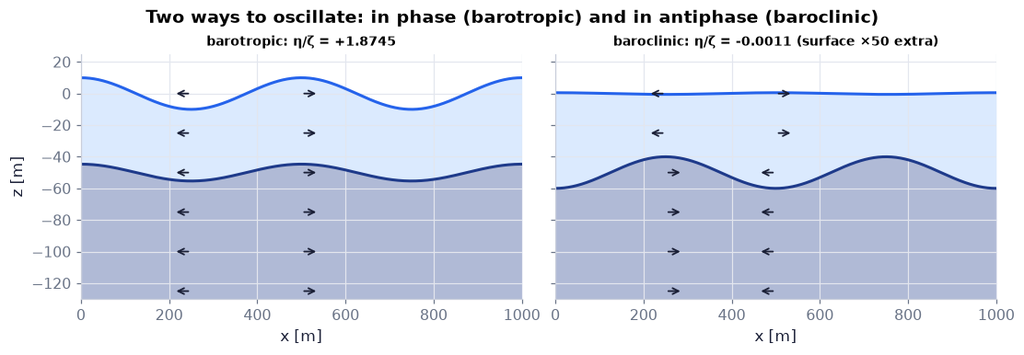

```python
k, H, r1, r2 = 2*np.pi/500, 50.0, 1000.0, 1002.0           # λ = 500 m
xs = np.linspace(0, 1000, 300)                             # two wavelengths [m]
fig, axs = plt.subplots(1, 2, figsize=(10, 3.4), sharey=True)   # barotropic | baroclinic
for axp, mode in zip(axs, ("barotropic", "baroclinic")):   # one panel per mode
    md = ch07.two_layer_modes(k, H, r1, r2, mode=mode)     # constants and the amplitude ratio
    ph = k*xs                                               # phase at t = 0
    zeta_true = np.real(md["b"]*np.exp(1j*ph))              # interface displacement for a surface amplitude a = 1 m [m]
    if mode == "barotropic":   # the in-phase mode
        eta_d, zeta_d = 10*np.cos(ph), 10*zeta_true         # both drawn ×10 (the interface is the smaller one)
    else:   # the antiphase mode
        sc = 10/abs(md["b"])                                # draw the interface with a 10 m amplitude …
        zeta_d, eta_d = sc*zeta_true, 50*sc*np.cos(ph)      # … and the surface 50 times larger again
    two_layer_sketch(axp, H, 1000, eta=eta_d, zeta=zeta_d, x=xs)   # light upper layer over navy lower layer
    zz = np.linspace(-2.5*H, 0, 6)                          # arrow heights [m]
    for z_ in zz:                                           # u at x = 0 (crest) and x = 250 (trough), sign only
        up = z_ > -H   # True in the upper layer
        amp = np.real(1j*k*((md["A"]*np.exp(k*z_) + md["B"]*np.exp(-k*z_)) if up else md["C"]*np.exp(k*z_)))   # u = ∂φ/∂x at a crest of η
        for x_, sg in ((500, 1), (250, -1)):               # under a crest of η (u ∝ +amp) and a trough (−amp)
            axp.annotate("", xy=(x_ + 40*np.sign(amp)*sg, z_), xytext=(x_, z_),   # an arrow showing the direction of u
                         arrowprops=dict(arrowstyle="->", color=COLORS["ink"], lw=1.2))   # arrow style
    axp.set_title(f"{mode}: η/ζ = {md['eta_over_zeta']:+.4f}" + (" (surface ×50 extra)" if mode == "baroclinic" else ""), fontsize=9)   # the true amplitude ratio
    axp.set_xlabel("x [m]"); axp.set_ylim(-2.6*H, 25)   # axes
axs[0].set_ylabel("z [m]")   # unit
fig.suptitle("Two ways to oscillate: in phase (barotropic) and in antiphase (baroclinic)", fontweight="bold")   # the message
savefig(fig, "ch07", "c14_modes"); plt.show()   # save, then draw
```

**What you see.** Left, the barotropic mode: surface and interface in phase, the arrows point the same way in both layers; right, the baroclinic mode: a tiny surface signal in antiphase (drawn 50 times larger again) and a large interface wave, with u reversing across the interface (our remake of Fig. 7.27 `N193`).

**How to read it.** The printed ratios: η/ζ = +$e^{kH}$ ≈ 1.9 for the barotropic mode (the interface is the smaller one) and −0.0011 for the baroclinic one.

**What would change if…** …Δρ → 0: the baroclinic surface signal vanishes and its speed goes to zero like √Δρ.

📝 **Note.** **Two thin layers** `N131` — When both layers are thin compared with λ and Δρ/ρ ≪ 1 (Boussinesq), the barotropic mode has the same u at every depth and the baroclinic mode has uniform, opposite u in the two layers (two layers between rigid lids). The profiles below are $u=\partial\phi/\partial x$ of the two long-wave modes (λ = 5 km, H = 50 m), each scaled to its largest value — our version of the book's Fig. 7.28 `N194`.

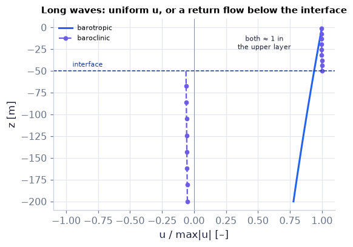

```python
k, H, r1, r2 = 2*np.pi/5000, 50.0, 1000.0, 1002.0          # a long wave, kH = 0.063
z1, z2 = np.linspace(-H, 0, 50), np.linspace(-4*H, -H, 80) # upper and lower layer depths [m]
fig, ax = plt.subplots(figsize=(5, 3.6))   # one panel
for mode, cl, ls, mk in (("barotropic", COLORS["blue"], "-", None), ("baroclinic", COLORS["accent"], "--", "o")):   # both modes
    md = ch07.two_layer_modes(k, H, r1, r2, mode=mode)   # its constants A, B, C (a = 1 m)
    u1 = np.real(1j*k*(md["A"]*np.exp(k*z1) + md["B"]*np.exp(-k*z1)))   # u = ∂φ₁/∂x at the crest of η
    u2 = np.real(1j*k*md["C"]*np.exp(k*z2))                              # u = ∂φ₂/∂x
    sc = max(np.abs(u1).max(), np.abs(u2).max())   # scale to the largest |u|
    ax.plot(u1/sc, z1, color=cl, lw=2 if mk is None else 1.5, ls=ls, marker=mk, markevery=6, ms=4, label=mode)   # upper layer
    ax.plot(u2/sc, z2, color=cl, lw=2 if mk is None else 1.5, ls=ls, marker=mk, markevery=10, ms=4)   # lower layer
ax.text(0.55, -H/2, "both ≈ 1 in\nthe upper layer", fontsize=7, ha="center", color=COLORS["ink"])   # the curves overlap here
ax.axhline(-H, color=NAVY, lw=1, ls="--"); ax.text(-0.95, -H + 5, "interface", fontsize=7, color=NAVY)   # the interface
ax.axvline(0, color=COLORS["muted"], lw=0.5)   # u = 0
ax.set_xlabel("u / max|u| [–]"); ax.set_ylabel("z [m]"); ax.legend(fontsize=7); ax.set_xlim(-1.1, 1.1)   # axes
ax.set_title("Long waves: uniform u, or a return flow below the interface", fontsize=10)   # the message
savefig(fig, "ch07", "c14_long_wave_u"); plt.show()   # save, then draw
```

**What you see.** The barotropic u (blue) is nearly the same at every depth (it decays only like $e^{kz}$ over 1/k ≈ 800 m); the baroclinic u (purple, dashed with dots) is uniform in the upper layer — on top of the blue line there — and reverses across the interface into a weak return flow below.

**How to read it.** In the baroclinic mode the upper layer's flow is balanced by the opposite flow below: here the lower layer is deep, so the return flow is weak (≈ kH = 6 % of the upper one) but spread over ~1/k; between rigid lids with a thin lower layer (note N131) it would be as strong as the upper one. Almost no net transport — the signature of internal motion.

**What would change if…** …the upper layer were much thicker than the wavelength: the profiles would curve like $e^{\pm kz}$ (deep water, C13).

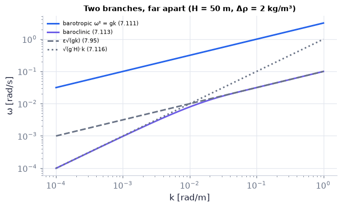

```python
k = np.logspace(-4, 0, 300)                                # wavenumbers [rad/m]
H, r1, r2 = 50.0, 1000.0, 1002.0                           # thermocline of the tiny example
bt, bc = ch07.two_layer_free_surface_omega(k, H, r1, r2)   # (7.111), (7.113)
fig, ax = plt.subplots(figsize=(6, 3.6))   # one panel
ax.loglog(k, bt, color=COLORS["blue"], lw=2, label="barotropic ω² = gk (7.111)")   # fast branch
ax.loglog(k, bc, color=COLORS["accent"], lw=2, label="baroclinic (7.113)")   # slow branch
ax.loglog(k, ch07.interface_omega(k, r1, r2), "--", color=COLORS["muted"], label="ε√(gk) (7.95)")   # short-wave limit
ax.loglog(k, np.sqrt(W.reduced_gravity_book(r1, r2)*H)*k, ":", color=COLORS["muted"], label="√(g′H)·k (7.116)")   # long-wave limit
ax.set_xlabel("k [rad/m]"); ax.set_ylabel("ω [rad/s]"); ax.legend(fontsize=7)   # axes
ax.set_title("Two branches, far apart (H = 50 m, Δρ = 2 kg/m³)", fontsize=10)   # the message
savefig(fig, "ch07", "c14_two_branches"); plt.show()   # save, then draw
```

**How to read it.** For kH ≫ 1 the surface is too far away to matter: the interface forgets it, (7.113), $\omega^2=\frac{gk(\rho_2-\rho_1)\sinh kH}{\rho_2\cosh kH+\rho_1\sinh kH}$ → (7.95), $\omega=\sqrt{gk\frac{\rho_2-\rho_1}{\rho_2+\rho_1}}=\varepsilon\sqrt{gk}$.

**What would change if…** …H were doubled: the baroclinic long-wave line moves up by √2.

```python
k = np.logspace(-4, 0, 120)                                # wavenumbers [rad/m]
def branches(r):                                           # r = Δρ/ρ₂ [–]
    r2 = 1000.0; r1 = r2*(1 - r)                           # densities [kg/m³]
    bt, bc = ch07.two_layer_free_surface_omega(k, 50.0, r1, r2)   # (7.111), (7.113)
    return {"barotropic (7.111)": (k, bt), "baroclinic (7.113)": (k, bc), "ε√(gk) (7.95)": (k, ch07.interface_omega(k, r1, r2))}   # three curves per position
fig = slider_figure(branches, "Δρ/ρ₂", np.logspace(-4, np.log10(0.5), 16 if not FAST else 9), xlabel="k [rad/m]",   # slider: density contrast (log)
                    ylabel="ω [rad/s]", title="The baroclinic branch rises with the density contrast (H = 50 m)")   # labels and message
logaxes(fig, x=(1e-4, 1), y=(1e-6, 5))   # log axes, fixed
recolor(fig, {"barotropic (7.111)": COLORS["blue"], "baroclinic (7.113)": COLORS["accent"], "ε√(gk) (7.95)": COLORS["muted"]},   # colours by meaning
        dashes={"ε√(gk) (7.95)": "dash"})   # limit dashed
fig.show()   # draw (works on the page: no kernel needed)
```

[interactive chart not shown]

**What you see.** Drag Δρ/ρ₂: the barotropic branch does not move at all; the baroclinic branch rises like $\sqrt{\Delta\rho}$ and always joins the two-deep-fluids curve (7.95), $\omega=\sqrt{gk\frac{\rho_2-\rho_1}{\rho_2+\rho_1}}=\varepsilon\sqrt{gk}$ for short waves.

**What would change if…** the upper layer were thicker (H = 200 m): the baroclinic long-wave line $\sqrt{g'H}\,k$ would move up by a factor 2 and bend over into the short-wave curve at a smaller k.

#### 🎮 Interactive: What is a baroclinic mode?

**Why interactive rather than a static figure:** The density-contrast and thickness sliders move both dispersion curves and both mode shapes at once; the reader sees the interface amplitude dwarf the surface one as Δρ → 0 and recovers the two-deep-fluids case as kH → ∞.

**What to try:**

- Preset *ocean thermocline*: compare the two periods in the Explain tab.
- Switch between the modes: watch u reverse across the interface in the baroclinic one.
- Drag Δρ/ρ up to 0.2 (oil over water) and read how different the two g′ conventions are.
- Step the Derivation (D30) to 'factor out (s − 1)'.

```python
show_viz("ch07", "two_layer_modes")   # full-width explainer; ⤢ Full screen for more room
```

🎮 Interactive 8/9 What is a baroclinic mode? Open alone ↗

[interactive chart not shown]

**What would change if…** …the Earth rotated? The baroclinic long-wave speed $\sqrt{g'H}\approx1$ m/s divided by the Coriolis parameter f ≈ 10⁻⁴ s⁻¹ gives the internal (baroclinic) Rossby radius ≈ 10 km — the size of ocean eddies (Ch. 13).

## 7.8 Internal Waves in a Continuously Stratified Fluid

**What is this section about?** Now the density changes smoothly with height, as in most of the ocean and atmosphere. Displaced parcels bob at the buoyancy frequency N, and waves can travel in any direction — with astonishing rules: the frequency depends only on the direction of the wave, never on its wavelength; the water moves along the crests; and the energy travels at right angles to the crests.

> 🔁 **Recap — Assumptions** (Ch. 4 §4.9). Boussinesq (density differences matter only in the weight), inviscid, small amplitude (advection dropped), and frequencies well above the Coriolis frequency (rotation joins in Ch. 13). The momentum equations are Ch. 4's Boussinesq form $\frac{D\mathbf u}{Dt}=-\frac1{\rho_0}\nabla p'+\frac{\rho'}{\rho_0}\mathbf g+\nu\nabla^2\mathbf u$ without advection and viscosity.

> 🔁 **Recap — Density and continuity equations** (Ch. 4 §4.2). $\frac{D\rho}{Dt}\equiv\frac{\partial\rho}{\partial t}+\mathbf u\cdot\nabla\rho=0$ *(4.9)* (each parcel keeps its density) and $\nabla\cdot\mathbf u=0$ *(4.10)* (incompressible flow). Below: the internal wave of C16 is divergence-free to round-off.

```python
r = ch07.internal_wave_fields(0.3, -0.2, 1.0, 1.0, 1.0, 0.01, 1e-3, residuals=True)["residuals"]   # k = m = 1 rad/m, N = 0.01 rad/s
print({n: f"{v:.1e}" for n, v in r.items()})               # (4.10), (7.128), (7.130), (7.131) by central differences
```

```
{'continuity': '0.0e+00', 'momentum_x': '5.5e-14', 'momentum_z': '-1.6e-13', 'density': '-1.7e-12'}
```

**What does the code above do?**

The plane internal wave of C15 is put into continuity $\nabla\cdot\mathbf u=0$ *(4.10)* and the linear equations $\frac{\partial u}{\partial t}=-\frac1{\rho_0}\frac{\partial p'}{\partial x}$ *(7.128)*, $\frac{\partial w}{\partial t}=-\frac1{\rho_0}\frac{\partial p'}{\partial z}-\frac{\rho'g}{\rho_0}$ *(7.130)* and $\frac{\partial\rho'}{\partial t}-\frac{N^2\rho_0}gw=0$ *(7.131)*; every residual is at the size of the difference-stencil error — the fields satisfy the equations D32 derives below.

> 🔁 **Recap — Linear Boussinesq momentum** (Ch. 4 §4.9). $\frac{\partial u}{\partial t}=-\frac1{\rho_0}\frac{\partial p}{\partial x}$ *(7.120)*, $\frac{\partial v}{\partial t}=-\frac1{\rho_0}\frac{\partial p}{\partial y}$ *(7.121)*, $\frac{\partial w}{\partial t}=-\frac1{\rho_0}\frac{\partial p}{\partial z}-\frac{\rho g}{\rho_0}$ *(7.122)*: ρ₀ in the inertia, the true ρ only in the weight.

> 🔁 **Recap — Why Dρ/Dt = 0** (Ch. 1 §1.10, Ch. 4 §4.2). Heat and salt do not diffuse on wave time scales, and the density depends on temperature and salinity but not on pressure (δρ/ρ = −αδT + βδS), so a parcel keeps its density: $\frac{D\rho}{Dt}=0$ *(4.9)*.

> 🔁 **Recap — The resting state** (Ch. 1 §1.7). Before the waves, the fluid is hydrostatic: $0=-\frac1{\rho_0}\frac{d\bar p}{dz}-\frac{\bar\rho g}{\rho_0}$ *(7.123)*.

> 🔁 **Recap — Background plus perturbation** (Ch. 4 §4.9). $p=\bar p(z)+p',\ \rho=\bar\rho(z)+\rho'$ *(7.124)* — ⚠️ here p′ is measured from the stratified background $\bar p(z)$, not from −ρgz as in $p'\equiv p+\rho gz$ *(7.30)*.

> 🔁 **Recap — The buoyancy frequency** (Ch. 1 §1.10). $N^2\equiv-\frac g{\rho_0}\frac{d\bar\rho}{dz}$ *(7.127)* — $N^2=-\frac{g}{\rho}\big(\frac{d\rho}{dz}-\frac{d\rho_a}{dz}\big)$ *(1.29)* with no adiabatic gradient: a displaced parcel oscillates at N.

```python
N2 = stratification.brunt_vaisala_sq(1025.0, -1.045e-2, 0.0, g=9.81)   # (1.29): ρ = 1025 kg/m³, dρ/dz = −0.01045 kg/m⁴
print(f"N² = {N2:.3e} 1/s², N = {np.sqrt(N2):.4f} rad/s, buoyancy period {2*np.pi/np.sqrt(N2)/60:.1f} min")   # a thermocline
```

```
N² = 1.000e-04 1/s², N = 0.0100 rad/s, buoyancy period 10.5 min
```

> 🔁 **Recap — Potential density** (Ch. 1 §1.10). Compressibility is handled by using the potential density (the density brought adiabatically to a reference pressure, oceanographers' "sigma-theta") in N, so the incompressible equations still apply.

> 🔁 **Recap — Internal waves are rotational** (Ch. 5 §5.4). Where density surfaces tilt against pressure surfaces the baroclinic torque ∇ρ × ∇p/ρ² makes vorticity (Ch. 5 §5.4), so internal waves have no velocity potential — C13's vortex sheet is the thin-layer limit.

### 🧩 Internal waves: frequency set by direction `C15`

*The question:* If the buoyancy frequency N is the only frequency the fluid knows, what sets the frequency of a wave?

*In one line:* $\omega=N\cos\theta$ *(7.139)*

#### The problem in plain words

Fill a tank with salt water that gets fresher toward the top and wiggle a rod: the disturbance does not spread in rings like on a pond but in slanted beams. In the ocean, tides flowing over ridges radiate such beams through the thermocline; in the atmosphere, wind over mountains makes lee waves. We want the rule that fixes their frequency.

#### The idea

```
parcel pushed straight up:           it bobs at N (Ch. 1)
parcel pushed along a slope at θ:    only the vertical part of gravity's pull restores it
                                     ⇒ it bobs at N cos θ, whatever the wavelength
so:  ω = N cos θ,   0 < ω < N,   θ = angle of K above the horizontal = angle of the motion from the vertical
```

📝 **Note.** **Put the split into the density equation** `N132` — **Linearisation about a base state** keeps products of one small quantity with a background quantity ($w\,d\bar\rho/dz$) and drops products of two small quantities ($u\,\partial\rho'/\partial x$) — Ch. 2 P68's orders of smallness.

$$ \frac{\partial}{\partial t}(\bar\rho+\rho')+\mathbf u\cdot\nabla(\bar\rho+\rho')=0 \qquad \text{(7.125)} $$

> 🔁 **Tools from earlier chapters used here** (see `knowledge/primers.md`)
- **material derivative** — $\frac{D}{Dt}=\frac{\partial}{\partial t}+\mathbf u\cdot\nabla$, the rate of change following a parcel (Ch. 3 §3.4).

#### 🧮 Derivation — The linear perturbation equations `D32` (Eq. 7.131: $\frac{\partial\rho'}{\partial t}-\frac{N^2\rho_0}gw=0$)

**What we want to show.** From the Boussinesq equations, derive the linear equations for small motions about a resting stratified fluid.

**Assumptions.** Small amplitude (steps 4, 9); ρ̄ depends on z only (step 3); Boussinesq (ρ₀ in the inertia).

**The plan.**

1. Split the density equation and linearise.
2. Introduce N².
3. Subtract the hydrostatic base from the momentum equations.

**Tools we use** (each explained before this point): material derivative (Ch. 3) · linearisation about a base state (gloss; P68) · R16, R17, R18.

**We start from**

$$ \begin{array}{l}\frac{D\rho}{Dt}\equiv\frac{\partial\rho}{\partial t}+\mathbf u\cdot\nabla\rho=0\ \text{(4.9)} \\ \nabla\cdot\mathbf u=0\ \text{(4.10)} \\ \frac{\partial u}{\partial t}=-\frac1{\rho_0}\frac{\partial p}{\partial x}\ \text{(7.120)} \\ \frac{\partial v}{\partial t}=-\frac1{\rho_0}\frac{\partial p}{\partial y}\ \text{(7.121)} \\ \frac{\partial w}{\partial t}=-\frac1{\rho_0}\frac{\partial p}{\partial z}-\frac{\rho g}{\rho_0}\ \text{(7.122)} \\ 0=-\frac1{\rho_0}\frac{d\bar p}{dz}-\frac{\bar\rho g}{\rho_0}\ \text{(7.123)} \\ p=\bar p(z)+p',\quad\rho=\bar\rho(z)+\rho'\ \text{(7.124)}\end{array} $$

*In words:* mass conservation, incompressibility, the momentum equations, the resting (hydrostatic) state and the split into base plus perturbation

**Step 1 of 10 — Write the density equation in full.**

$$ \frac{\partial\rho}{\partial t}+u\frac{\partial\rho}{\partial x}+v\frac{\partial\rho}{\partial y}+w\frac{\partial \rho}{\partial z}=0 $$

- *Why we can do this:* D/Dt = ∂/∂t + u·∇ (Ch. 3); (4.9), $\frac{D\rho}{Dt}\equiv\frac{\partial\rho}{\partial t}+\mathbf u\cdot\nabla\rho=0$ says each parcel keeps its density.
- *In words:* density is carried with the flow.

**Step 2 of 10 — Insert the split.**

$$ \frac{\partial}{\partial t}(\bar\rho+\rho')+u\frac{\partial}{\partial x}(\bar\rho+\rho')+v\frac{\partial}{\partial y}(\bar\rho+\rho')+ w\frac{\partial}{\partial z}(\bar\rho+\rho')=0\ \text{(7.125)} $$

- *Why we can do this:* (7.124) ρ = ρ̄(z) + ρ′.
- *In words:* background plus perturbation.

**Step 3 of 10 — Use ρ̄ = ρ̄(z).**

$$ \frac{\partial\bar\rho}{\partial t}=\frac{\partial\bar\rho}{\partial x}=\frac{\partial\bar\rho}{\partial y}=0 $$

- *Why we can do this:* The resting stratification is steady and horizontally uniform.
- *In words:* three background terms vanish.

**Step 4 of 10 — Drop products of small quantities.**

$$ \frac{\partial\rho'}{\partial t}+w\frac{d\bar\rho}{dz}=0\ \text{(7.126)} $$

- *Why we can do this:* u∂ρ′/∂x, v∂ρ′/∂y, w∂ρ′/∂z are small × small; w dρ̄/dz is small × O(1) and stays (linearisation).
- *In words:* density changes at a point because vertical motion carries the background up or down.

**Step 5 of 10 — Introduce N².**

$$ \frac{d\bar\rho}{dz}=-\frac{\rho_0N^2}{g}\ \Rightarrow\ \frac{\partial\rho'}{\partial t}-\frac{N^2\rho_0}gw=0\ \text{(7.131)} $$

- *Why we can do this:* The buoyancy frequency is defined by (7.127), $N^2\equiv-\frac g{\rho_0}\frac{d\bar\rho}{dz}$ N² ≡ −(g/ρ₀)dρ̄/dz (R18); substituting it names the stratification's strength.
- *In words:* the density equation in terms of N.

**Step 6 of 10 — Split the vertical momentum.**

$$ \frac{\partial w}{\partial t}=-\frac1{\rho_0}\frac{\partial(\bar p+p')}{\partial z}-\frac{(\bar\rho+\rho')g} {\rho_0} $$

- *Why we can do this:* Insert the split p = p̄(z) + p′, ρ = ρ̄(z) + ρ′ (7.124), $p=\bar p(z)+p',\ \rho=\bar\rho(z)+\rho'$ into the vertical momentum equation (7.122), $\frac{\partial w}{\partial t}=-\frac1{\rho_0}\frac{\partial p}{\partial z}-\frac{\rho g}{\rho_0}$ to separate background and wave.
- *In words:* background and perturbation parts.

**Step 7 of 10 — Subtract the hydrostatic base.**

$$ \frac{\partial w}{\partial t}=-\frac1{\rho_0}\frac{\partial p'}{\partial z}-\frac{\rho'g}{\rho_0}\ \text{(7.130)} $$

- *Why we can do this:* (7.123), $0=-\frac1{\rho_0}\frac{d\bar p}{dz}-\frac{\bar\rho g}{\rho_0}$: −(1/ρ₀)dp̄/dz − ρ̄g/ρ₀ = 0 cancels exactly.
- *In words:* only perturbations accelerate the water vertically.

**Step 8 of 10 — Split the horizontal momentum.**

$$ \frac{\partial u}{\partial t}=-\frac1{\rho_0}\frac{\partial p'}{\partial x},\quad\frac{\partial v}{\partial t}= -\frac1{\rho_0}\frac{\partial p'}{\partial y}\ \text{(7.128, 7.129)} $$

- *Why we can do this:* (7.120)–(7.121), $\frac{\partial u}{\partial t}=-\frac1{\rho_0}\frac{\partial p}{\partial x},\ \frac{\partial v}{\partial t}=-\frac1{\rho_0}\frac{\partial p}{\partial y}$ with p = p̄(z) + p′; p̄ does not depend on x or y.
- *In words:* horizontal acceleration by the perturbation pressure.

**Step 9 of 10 — Confirm nothing else is nonlinear.**

$$ \begin{array}{l}\mathbf u\cdot\nabla\mathbf u\ \text{already dropped in} \\ \frac{\partial u}{\partial t}=-\frac1{\rho_0}\frac{\partial p}{\partial x}\ \text{(7.120)} \\ \frac{\partial v}{\partial t}=-\frac1{\rho_0}\frac{\partial p}{\partial y}\ \text{(7.121)} \\ \frac{\partial w}{\partial t}=-\frac1{\rho_0}\frac{\partial p}{\partial z}-\frac{\rho g}{\rho_0}\ \text{(7.122)}\end{array} $$

- *Why we can do this:* The momentum equations of §7.8 are linear from the start (small amplitude, R12, R14); only the density equation needed linearising.
- *In words:* the momentum side is already linear.

**Step 10 of 10 — Count equations and unknowns.**

$$ \begin{array}{l}\nabla\cdot\mathbf u=0\ \text{(4.10)} \\ \frac{\partial u}{\partial t}=-\frac1{\rho_0}\frac{\partial p'}{\partial x}\ \text{(7.128)} \\ \frac{\partial v}{\partial t}=-\frac1{\rho_0}\frac{\partial p'}{\partial y}\ \text{(7.129)} \\ \frac{\partial w}{\partial t}=-\frac1{\rho_0}\frac{\partial p'}{\partial z}-\frac{\rho'g}{\rho_0}\ \text{(7.130)} \\ \frac{\partial\rho'}{\partial t}-\frac{N^2\rho_0}gw=0\ \text{(7.131)} \\ \text{5 equations for}\ u,v,w,p',\rho'\end{array} $$

- *Why we can do this:* A closed linear system: ready to be reduced to one equation (D33).
- *In words:* the linear internal-wave equations.

**Result**

$$ \begin{array}{l}\frac{\partial\rho'}{\partial t}+w\frac{d\bar\rho}{dz}=0\ \text{(7.126)} \\ \frac{\partial u}{\partial t}=-\frac1{\rho_0}\frac{\partial p'}{\partial x}\ \text{(7.128)} \\ \frac{\partial v}{\partial t}=-\frac1{\rho_0}\frac{\partial p'}{\partial y}\ \text{(7.129)} \\ \frac{\partial w}{\partial t}=-\frac1{\rho_0}\frac{\partial p'}{\partial z}-\frac{\rho'g}{\rho_0}\ \text{(7.130)} \\ \frac{\partial\rho'}{\partial t}-\frac{N^2\rho_0}gw=0\ \text{(7.131)} \\ \nabla\cdot\mathbf u=0\ \text{(4.10)}\end{array} $$

*In words:* five linear equations for u, v, w, p′, ρ′

**What it means.** Density perturbations are made only by moving fluid across the background gradient; that is what N measures.

**Check it.** Units: (7.131), $\frac{\partial\rho'}{\partial t}-\frac{N^2\rho_0}gw=0$ kg/(m³ s) on both terms ✓. `boussinesq_linear_sympy()` residuals 0 ✓. With N = 0 (uniform density) ρ′ stays 0 and the system is plain incompressible flow ✓.

> ⚠️ **Common confusion (traps in `D32`):** Dropping w dρ̄/dz (it is the whole physics); p′ here is measured from p̄(z), not from −ρgz as in (7.30), $p'\equiv p+\rho gz$.

📝 **Note.** **The linear equations** `N133–N135` — $\frac{\partial\rho'}{\partial t}+w\frac{d\bar\rho}{dz}=0$ *(7.126)*: density changes at a point only because the vertical motion carries the background up or down; the perturbation momentum equations $\frac{\partial u}{\partial t}=-\frac1{\rho_0}\frac{\partial p'}{\partial x}$ *(7.128)*, $\frac{\partial v}{\partial t}=-\frac1{\rho_0}\frac{\partial p'}{\partial y}$ *(7.129)*, $\frac{\partial w}{\partial t}=-\frac1{\rho_0}\frac{\partial p'}{\partial z}-\frac{\rho'g}{\rho_0}$ *(7.130)* look like (7.120)–(7.122), $\frac{\partial u}{\partial t}=-\frac1{\rho_0}\frac{\partial p}{\partial x},\ \frac{\partial v}{\partial t}=-\frac1{\rho_0}\frac{\partial p}{\partial y},\ \frac{\partial w}{\partial t}=-\frac1{\rho_0}\frac{\partial p}{\partial z}-\frac{\rho g}{\rho_0}$ with ρ′, p′; and $\frac{\partial\rho'}{\partial t}-\frac{N^2\rho_0}gw=0$ *(7.131)*.

> 📎 **Primer — operator elimination for linear PDEs.** `P177` · With several linear PDEs in several unknowns, apply derivatives (∂/∂t, ∂/∂z, the horizontal Laplacian $\nabla_H^2$) to whole equations and substitute one into another until a single unknown is left — like eliminating variables from linear equations. Allowed because the derivatives of smooth fields commute (Schwarz, Ch. 4 P121) and the coefficients do not depend on the variable being differentiated.

```python
import sympy as sp                                # symbolic check of one elimination move
x, t = sp.symbols('x t'); u, p = sp.Function('u')(x, t), sp.Function('p')(x, t)   # two unknown fields
eq1 = sp.Eq(sp.diff(u, t), -sp.diff(p, x))        # ∂u/∂t = −∂p/∂x
print(sp.simplify(sp.diff(eq1.lhs, x) - sp.diff(sp.diff(u, x), t)))   # 0: ∂/∂x of ∂u/∂t is ∂/∂t of ∂u/∂x
```

```
0
```

#### 🧮 Derivation — The w-equation `D33` (Eq. 7.134: $\frac{\partial^2}{\partial t^2}\nabla^2w+N^2\nabla_H^2w=0$)

**What we want to show.** Eliminate u, v, p′ and ρ′ to get one equation for the vertical velocity.

**Assumptions.** Linear, inviscid, Boussinesq, no rotation; N may depend on z (step 8).

**The plan.**

1. Time-differentiate continuity and bring in the horizontal momentum: (7.132), $\frac1{\rho_0}\nabla_H^2p'=\frac{\partial^2w}{\partial z\,\partial t}$.
2. Time-differentiate the vertical momentum and bring in the density equation: (7.133), $\frac1{\rho_0}\frac{\partial^2p'}{\partial t\,\partial z}=-\frac{\partial^2w}{\partial t^2}-N^2w$.
3. Eliminate p′ between them.

**Tools we use** (each explained before this point): operator elimination for linear PDEs (P177) · mixed partials commute (P121).

**We start from**

$$ \begin{array}{l}\nabla\cdot\mathbf u=0\ \text{(4.10)} \\ \frac{\partial u}{\partial t}=-\frac1{\rho_0}\frac{\partial p'}{\partial x}\ \text{(7.128)} \\ \frac{\partial v}{\partial t}=-\frac1{\rho_0}\frac{\partial p'}{\partial y}\ \text{(7.129)} \\ \frac{\partial w}{\partial t}=-\frac1{\rho_0}\frac{\partial p'}{\partial z}-\frac{\rho'g}{\rho_0}\ \text{(7.130)} \\ \frac{\partial\rho'}{\partial t}-\frac{N^2\rho_0}gw=0\ \text{(7.131)}\end{array} $$

*In words:* the linear internal-wave equations of D32

**Step 1 of 12 — Differentiate continuity in time.**

$$ \frac{\partial}{\partial t}\Big(\frac{\partial u}{\partial x}+\frac{\partial v}{\partial y}\Big)=-\frac{\partial^2w} {\partial z\,\partial t} $$

- *Why we can do this:* (4.10), $\nabla\cdot\mathbf u=0$ holds at all times, so its time derivative is zero; move the w-term right (P177).
- *In words:* prepare to bring in the momentum equations.

**Step 2 of 12 — Swap the derivatives.**

$$ \frac{\partial}{\partial x}\Big(\frac{\partial u}{\partial t}\Big)+\frac{\partial}{\partial y}\Big(\frac{\partial v}{\partial t}\Big)= -\frac{\partial^2w}{\partial z\,\partial t} $$

- *Why we can do this:* Mixed partials of smooth fields commute (P121).
- *In words:* now ∂u/∂t and ∂v/∂t appear.

**Step 3 of 12 — Insert the horizontal momentum.**

$$ -\frac1{\rho_0}\Big(\frac{\partial^2p'}{\partial x^2}+\frac{\partial^2p'}{\partial y^2}\Big)=-\frac{\partial^2w}{\partial z\, \partial t} $$

- *Why we can do this:* (7.128)–(7.129), $\frac{\partial u}{\partial t}=-\frac1{\rho_0}\frac{\partial p'}{\partial x},\ \frac{\partial v}{\partial t}=-\frac1{\rho_0}\frac{\partial p'}{\partial y}$: ∂u/∂t = −p′_x/ρ₀, ∂v/∂t = −p′_y/ρ₀.
- *In words:* u and v are gone.

**Step 4 of 12 — Name the horizontal Laplacian.**

$$ \frac1{\rho_0}\nabla_H^2p'=\frac{\partial^2w}{\partial z\,\partial t}\ \text{(7.132)} $$

- *Why we can do this:* ∇_H² ≡ ∂²/∂x² + ∂²/∂y²; multiply by −1.
- *In words:* horizontal pressure curvature drives vertical stretching.

**Step 5 of 12 — Differentiate the vertical momentum in time.**

$$ \frac{\partial^2w}{\partial t^2}=-\frac1{\rho_0}\frac{\partial^2p'}{\partial t\,\partial z}-\frac g {\rho_0}\frac{\partial\rho'}{\partial t} $$

- *Why we can do this:* (7.130), $\frac{\partial w}{\partial t}=-\frac1{\rho_0}\frac{\partial p'}{\partial z}-\frac{\rho'g}{\rho_0}$ holds at all times; ρ₀ and g are constants.
- *In words:* prepare to eliminate ρ′.

**Step 6 of 12 — Insert the density equation.**

$$ \frac g{\rho_0}\frac{\partial\rho'}{\partial t}=N^2w $$

- *Why we can do this:* The linear density equation (7.131), $\frac{\partial\rho'}{\partial t}-\frac{N^2\rho_0}gw=0$ gives ∂ρ′/∂t = (N²ρ₀/g)w; multiplying by g/ρ₀ turns the buoyancy term into N²w.
- *In words:* the buoyancy acceleration in terms of w.

**Step 7 of 12 — Rearrange.**

$$ \frac1{\rho_0}\frac{\partial^2p'}{\partial t\,\partial z}=-\frac{\partial^2w}{\partial t^2}-N^2w\ \text{(7.133)} $$

- *Why we can do this:* Put step 6 into step 5 and move the pressure term to the left; this is the book's (7.133), $\frac1{\rho_0}\frac{\partial^2p'}{\partial t\,\partial z}=-\frac{\partial^2w}{\partial t^2}-N^2w$ — the line above.
- *In words:* a second relation between p′ and w.

**Step 8 of 12 — Apply ∇_H² to (7.133).**

$$ \frac1{\rho_0}\frac{\partial^2}{\partial t\,\partial z}\nabla_H^2p'=-\nabla_H^2\Big(\frac{\partial^2w}{\partial t^2}+N^2w\Big) $$

- *Why we can do this:* ∇_H² commutes with ∂/∂t, ∂/∂z and with N(z), since it acts only in x and y.
- *In words:* prepare to use (7.132), $\frac1{\rho_0}\nabla_H^2p'=\frac{\partial^2w}{\partial z\,\partial t}$.

**Step 9 of 12 — Apply ∂²/∂t∂z to (7.132).**

$$ \frac1{\rho_0}\frac{\partial^2}{\partial t\,\partial z}\nabla_H^2p'=\frac{\partial^2}{\partial t\,\partial z}\Big(\frac{\partial^2w} {\partial z\,\partial t}\Big) $$

- *Why we can do this:* Differentiate both sides of (7.132), $\frac1{\rho_0}\nabla_H^2p'=\frac{\partial^2w}{\partial z\,\partial t}$; ρ₀ is constant.
- *In words:* the same left side as step 8.

**Step 10 of 12 — Equate the right sides.**

$$ \frac{\partial^4w}{\partial t^2\partial z^2}=-\nabla_H^2\frac{\partial^2w}{\partial t^2}-N^2\nabla_H^2w $$

- *Why we can do this:* Steps 8 and 9 have identical left sides; commute the derivatives on the left of step 9.
- *In words:* p′ is eliminated.

**Step 11 of 12 — Group the time derivatives.**

$$ \frac{\partial^2}{\partial t^2}\Big(\frac{\partial^2w}{\partial z^2}+\nabla_H^2w\Big)+N^2\nabla_H^2w=0 $$

- *Why we can do this:* Move everything left and factor ∂²/∂t².
- *In words:* nearly there.

**Step 12 of 12 — Use the full Laplacian.**

$$ \frac{\partial^2}{\partial t^2}\nabla^2w+N^2\nabla_H^2w=0\ \text{(7.134)} $$

- *Why we can do this:* ∇² = ∇_H² + ∂²/∂z². Valid for N(z) too (step 8).
- *In words:* one equation for w.

**Result**

$$ \frac{\partial^2}{\partial t^2}\nabla^2w+N^2\nabla_H^2w=0 $$

**What it means.** One scalar equation governs internal waves; its operator treats horizontal and vertical directions differently — the source of ω = N cos θ (D34).

**Check it.** Units: 1/(m² s³) per unit w ✓. N = 0: ∇²w = const in time — no waves without stratification ✓. A plane wave with ω from (7.138), $\omega=\frac{kN}{\sqrt{k^2+m^2}}=\frac{kN}K\ (k>0)$ makes the finite-difference residual ≈ 0, a wrong ω does not (C15 from scratch) ✓.

```python
import sympy as sp                                        # symbolic algebra
x, y, z, t = sp.symbols('x y z t', real=True)             # coordinates and time
rho0, g = sp.symbols('rho0 g', positive=True)             # reference density, gravity
N = sp.Function('N')(z)                                   # buoyancy frequency, allowed to depend on z
p = sp.Function('p')(x, y, z, t); w = sp.Function('w')(x, y, z, t)   # perturbation pressure and vertical velocity
lap_H = lambda f: sp.diff(f, x, 2) + sp.diff(f, y, 2)     # horizontal Laplacian ∇_H²
eq132 = lap_H(p)/rho0 - sp.diff(w, z, t)                  # (7.132) as "left − right": ∇_H²p′/ρ₀ − w_zt (steps 1–4)
eq133 = sp.diff(p, t, z)/rho0 + sp.diff(w, t, 2) + N**2*w # (7.133) as "left − right": p′_tz/ρ₀ + w_tt + N²w (steps 5–7)
combo = sp.diff(eq132, t, z) - lap_H(eq133)               # steps 8–10: ∂_t∂_z of (7.132) minus ∇_H² of (7.133)
w134 = sp.diff(w, t, 2, z, 2) + lap_H(sp.diff(w, t, 2)) + N**2*lap_H(w)   # (7.134): ∂_tt∇²w + N²∇_H²w (steps 11–12)
print("p′ eliminated, even for N(z):", sp.simplify(combo + w134))          # 0: the elimination is exact
print("library, every step's residual:", {k_: v for k_, v in ch07.boussinesq_linear_sympy().items() if k_.startswith("r")})
```

```
p′ eliminated, even for N(z): 0
```

```
library, every step's residual: {'r7126': 0, 'r7128': 0, 'r7129': 0, 'r7130': 0, 'r7131': 0, 'r7132': 0, 'r7133': 0, 'r7134': 0, 'r7137': 0, 'residuals': {'r7126': 0, 'r7128': 0, 'r7129': 0, 'r7130': 0, 'r7131': 0, 'r7132': 0, 'r7133': 0, 'r7134': 0, 'r7137': 0}}
```

> ⚠️ **Common confusion (traps in `D33`):** Forgetting that ∂/∂z and N(z) do not commute (we never needed to swap them); dropping the minus sign when moving w_zt; losing a ρ₀.

📝 **Note.** **Where D33 passes** `N136–N138` — D33 passes through $\frac1{\rho_0}\nabla_H^2p'=\frac{\partial^2w}{\partial z\,\partial t}$ *(7.132)* ($\nabla_H^2\equiv\partial^2/\partial x^2+\partial^2/\partial y^2$), $\frac1{\rho_0}\frac{\partial^2p'}{\partial t\,\partial z}=-\frac{\partial^2w}{\partial t^2}-N^2w$ *(7.133)*, and ends at the w-equation (7.134) — which holds for N(z) too.

$$ \frac{\partial^2}{\partial t^2}\nabla^2w+N^2\nabla_H^2w=0 \qquad \text{(7.134)} $$

📝 **Note.** **Anisotropy and the plane-wave trial** `N139, N140` — The medium has no preferred horizontal direction but a preferred vertical, so ω depends on all of K: $\omega=\omega(k,l,m)=\omega(\mathbf K)$ *(7.135)* — anisotropic. Try a plane wave $w=w_0e^{i(kx+ly+mz-\omega t)}$ *(7.136)*. **Angle of a vector from its components**: cos θ = |k|/K, computed with `np.arccos`, degrees with `np.degrees`.

> 🔁 **Tools from earlier chapters used here** (see `knowledge/primers.md`)
- **plane-wave trial (7.136), $w=w_0e^{i(kx+ly+mz-\omega t)}$, ∂ → ik and −iω** — for a field $\propto e^{i(\mathbf K\cdot\mathbf x-\omega t)}$ every ∂/∂x brings ik, ∂/∂z brings im and ∂/∂t brings −iω (primer P176, C13).

#### 🧮 Derivation — Internal-wave dispersion: $\omega=N\cos\theta$ `D34` (Eq. 7.139: $\omega=N\cos\theta$)

**What we want to show.** Find the frequency of a plane internal wave and show that it depends only on the direction of K.

**Assumptions.** Constant N (step 2); l = 0 by rotating axes (step 6).

**The plan.**

1. Note the anisotropy.
2. Insert a plane wave.
3. Solve and express through the angle of K.

**Tools we use** (each explained before this point): complex amplitudes (P176) · angle of a vector (gloss).

**We start from**

$$ \frac{\partial^2}{\partial t^2}\nabla^2w+N^2\nabla_H^2w=0\ \text{(7.134) with constant N.} $$

**Step 1 of 8 — Note the anisotropy.**

$$ \omega=\omega(k,l,m)=\omega(\mathbf K)\ \text{(7.135)} $$

- *Why we can do this:* Gravity singles out the vertical: (7.134), $\frac{\partial^2}{\partial t^2}\nabla^2w+N^2\nabla_H^2w=0$ treats ∇_H² and ∂²/∂z² differently, so ω may depend on the direction of K, not just its length.
- *In words:* frequency may depend on direction.

**Step 2 of 8 — Try a plane wave.**

$$ w=w_0e^{i(kx+ly+mz-\omega t)}=w_0e^{i(\mathbf K\cdot\mathbf x-\omega t)}\ \text{(7.136)} $$

- *Why we can do this:* Constant N means constant coefficients, so exponentials solve (7.134), $\frac{\partial^2}{\partial t^2}\nabla^2w+N^2\nabla_H^2w=0$ (P176).
- *In words:* one Fourier mode.

**Step 3 of 8 — Replace the derivatives.**

$$ \frac{\partial^2}{\partial t^2}\to-\omega^2,\quad\nabla^2\to-K^2,\quad\nabla_H^2\to-(k^2+l^2) $$

- *Why we can do this:* Each ∂/∂x brings ik, ∂/∂t brings −iω, and (ik)² = −k².
- *In words:* derivatives become multiplications.

**Step 4 of 8 — Substitute.**

$$ \omega^2K^2w-N^2(k^2+l^2)w=0\ \Rightarrow\ \omega^2K^2=N^2(k^2+l^2) $$

- *Why we can do this:* (−ω²)(−K²) = ω²K²; divide by w ≠ 0.
- *In words:* an algebraic relation.

**Step 5 of 8 — Solve for ω².**

$$ \omega^2=\frac{k^2+l^2}{k^2+l^2+m^2}N^2\ \text{(7.137)} $$

- *Why we can do this:* K² = k² + l² + m² (7.6), $K^2=k^2+l^2+m^2$.
- *In words:* the internal-wave dispersion relation.

**Step 6 of 8 — Work in the x–z plane.**

$$ l=0:\ \omega=\frac{\lvert k\rvert N}{\sqrt{k^2+m^2}}=\frac{\lvert k\rvert N}K\ \text{(7.138)} $$

- *Why we can do this:* The medium is the same in every horizontal direction, so we point x along the horizontal part of K; positive root. The book writes kN/K assuming k > 0.
- *In words:* frequency from the components.

**Step 7 of 8 — Introduce the angle of K.**

$$ \cos\theta=\frac{\lvert k\rvert}K,\quad\theta=\text{angle of }\mathbf K\text{ above the horizontal} $$

- *Why we can do this:* Geometry of K = (k, m) (gloss: angle of a vector, `np.arccos`).
- *In words:* the direction of the wave.

**Step 8 of 8 — Conclude.**

$$ \omega=N\cos\theta\ \text{(7.139),}\ 0<\omega<N $$

- *Why we can do this:* Substitute step 7 into step 6; cos θ lies between 0 and 1.
- *In words:* frequency set by direction only; N is the maximum.

**Result**

$$ \omega^2=\frac{k^2+l^2}{K^2}N^2\ \text{(7.137),}\ \omega=N\cos\theta $$

**What it means.** An internal wave's frequency is its direction: a source at fixed ω radiates only at cos θ = ω/N — the beams of C16.

**Check it.** θ = 0 (m = 0): ω = N, the Ch. 1 parcel (N145 parity) ✓. N = 0.01 rad/s, θ = 45°: T = 14.8 min ✓. Doubling K at fixed direction leaves ω unchanged ✓ (the code cell after the tiny example of C15: three equal values).

> ⚠️ **Common confusion (traps in `D34`):** Using k instead of |k| for a wave going to −x; mixing θ (K from the horizontal) with the beam angle (from the vertical: the same number); expecting ω to grow with K as for surface waves.

📝 **Note.** **The internal-wave dispersion relation** `N141, N142` — $\omega^2=\frac{k^2+l^2}{k^2+l^2+m^2}N^2$ *(7.137)*; in the x–z plane $\omega=\frac{kN}{\sqrt{k^2+m^2}}=\frac{kN}K$ *(7.138)* — written for k > 0; for a wave travelling toward −x use |k| (our code does).

📝 **Note.** **The two limits** `N145` — θ = 0 (K horizontal, m = 0) gives ω = N — vertical columns bobbing, Ch. 1's parcel; θ → π/2 gives ω → 0, where the wave solution says nothing and the full equations must be used (next note). The code checks the ω = N limit against Ch. 1's parcel oscillation.

```python
t = np.linspace(0, 1000, 5)                                # times [s]
f = ch07.internal_wave_fields(0.0, 0.0, t, 0.01, 0.0, 0.01, 1e-3)   # m = 0: K horizontal; N = 0.01 rad/s; ŵ = 1 mm/s
z = stratification.parcel_displacement(t, 0.0, 1e-4, w0=1e-3)       # Ch. 1: ζ″ + N²ζ = 0 from ζ = 0 with speed ŵ
print(f["zeta_particle"], "|", z)                          # the particle's vertical displacement both ways [m]
assert np.allclose(f["zeta_particle"], z, atol=1e-12)      # the ω = N wave is Ch. 1's bobbing parcel
```

```
[ 0.      0.0598 -0.0959  0.0938 -0.0544] | [ 0.      0.0598 -0.0959  0.0938 -0.0544]
```

📝 **Note.** **Layered flows and blocking** `N146, N147, N196` — A possible steady solution of (4.10), $\nabla\cdot\mathbf u=0$ and (7.128)–(7.131), $\frac{\partial u}{\partial t}=-\frac1{\rho_0}\frac{\partial p'}{\partial x},\ \frac{\partial v}{\partial t}=-\frac1{\rho_0}\frac{\partial p'}{\partial y},\ \frac{\partial w}{\partial t}=-\frac1{\rho_0}\frac{\partial p'}{\partial z}-\frac{\rho'g}{\rho_0},\ \frac{\partial\rho'}{\partial t}-\frac{N^2\rho_0}gw=0$: w = p′ = ρ′ = 0 with u, v any horizontally non-divergent field, $\frac{\partial u}{\partial x}+\frac{\partial v}{\partial y}=0$ *(7.142)*, at each level separately — strong stratification allows flat, layered flows (pancake eddies, cloud sheets seen from aircraft, Ch. 13). In strong stratification a 2-D body blocks a whole horizontal layer of fluid ahead of it (the book's Fig. 7.30: the fluid cannot go over or under — orographic blocking in Ch. 13).

```python
print(ch07.layered_flow_check(lambda x, y, z: -np.sin(y), lambda x, y, z: np.sin(x), 0.3, 0.7))   # (7.142) and the rest: 0
```

```
{'divergence': 0.0, 'momentum_x': 0.0, 'momentum_z': 0.0, 'density': 0.0}
```

#### ✏️ Tiny example: a thermocline internal wave

N = 0.01 rad/s.

1. Buoyancy period 2π/N = 628 s = 10.5 min — no internal wave can be faster.
2. A wave with K at θ = 45° to the horizontal: ω = N cos 45° = 0.00707 rad/s, T = 14.8 min.
3. The same direction with a 10× longer wavelength: still 14.8 min — only the direction counts.
4. For T = 12 h (a tide): cos θ = (2π/43 200)/0.01 = 0.0145, θ = 89.2° — K almost vertical, the energy beams almost horizontal.

```python
print(ch07.internal_wave_omega(1.0, 1.0, 0.01), ch07.internal_wave_omega(0.1, 0.1, 0.01),
      ch07.internal_wave_omega(-1.0, 1.0, 0.01), "rad/s")   # (7.138): size and the sign of k do not matter
print(f"θ for ω/N = 0.707: {np.degrees(ch07.beam_angle(0.00707, 0.01)):.2f}°")   # (7.139) inverted
s = ch07.boussinesq_linear_sympy()                         # D32–D34 in sympy (cached)
print({n: v for n, v in s.items() if n.startswith("r")})   # every residual 0
```

```
0.007071067811865476 0.007071067811865476 0.007071067811865476 rad/s
θ for ω/N = 0.707: 45.01°
{'r7126': 0, 'r7128': 0, 'r7129': 0, 'r7130': 0, 'r7131': 0, 'r7132': 0, 'r7133': 0, 'r7134': 0, 'r7137': 0, 'residuals': {'r7126': 0, 'r7128': 0, 'r7129': 0, 'r7130': 0, 'r7131': 0, 'r7132': 0, 'r7133': 0, 'r7134': 0, 'r7137': 0}}
```

**What does the code above do?**

1. Three wavenumber vectors along the same 45° direction or its mirror — ω = 0.0070711 rad/s every time: the frequency knows only the direction of K.
2. `beam_angle` inverts $\omega=N\cos\theta$ *(7.139)*: 45.0°.
3. `boussinesq_linear_sympy` checks every equation of D32–D34 symbolically, including $\omega^2=\frac{k^2+l^2}{k^2+l^2+m^2}N^2$ *(7.137)*.

```python
Nf, kk, mm = 1.0, 1.0, 1.0                                 # N [rad/s], k, m [rad/m] (unit scales: round-off stays small)
w_right = ch07.internal_wave_omega(kk, mm, Nf)             # (7.138): 0.707 rad/s
def res(om, x=0.3, z=-0.2, t=1.0, h=1e-2):                 # residual of (7.134) for w = cos(kx + mz − ωt), by hand
    wf = lambda X, Z, T: np.cos(kk*X + mm*Z - om*T)        # the trial plane wave
    d2 = lambda f, X, Z, T, dx, dz, dt: (f(X + dx, Z + dz, T + dt) - 2*f(X, Z, T) + f(X - dx, Z - dz, T - dt))/h**2
    lap = lambda X, Z, T: d2(wf, X, Z, T, h, 0, 0) + d2(wf, X, Z, T, 0, h, 0)   # ∇²w
    return d2(lap, x, z, t, 0, 0, h) + Nf**2*d2(wf, x, z, t, h, 0, 0)            # ∂_tt∇²w + N²∂_xx w
res_right, res_wrong = res(w_right), res(Nf)               # with ω from (7.138), and with the wrong ω = N
print(f"residual with the right ω: {res_right:.1e}; with ω = N: {res_wrong:.2f}")
assert abs(res_right) < 1e-4*abs(res_wrong)                # only (7.138) solves (7.134) (what is left is the O(h²) stencil error)
assert np.allclose(res_right, ch07.w_equation_residual(lambda X, Z, T: np.cos(kk*X + mm*Z - w_right*T), 0.3, -0.2, 1.0, Nf), atol=1e-8)
```

```
residual with the right ω: -3.5e-06; with ω = N: 0.62
```

> 📎 **Primer — np.errstate(invalid="ignore").** `P184` · numpy normally prints a RuntimeWarning when an operation has no valid answer, such as 0/0 → NaN. Inside `with np.errstate(invalid="ignore"):` that particular complaint is switched off for the lines in the block only. We use it where a NaN is expected and harmless: at K = 0 the direction of K, and so ω = N cos θ, is undefined.

```python
import numpy as np                                        # arrays
with np.errstate(invalid="ignore"):                       # 0/0 is expected here: stay quiet
    print(np.array([0.0, 1.0])/np.array([0.0, 2.0]))      # [nan 0.5]
```

```
[nan 0.5]
```

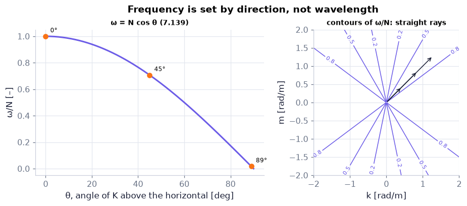

```python
fig, (a1, a2) = plt.subplots(1, 2, figsize=(9, 3.6))       # ω/N vs θ | the (k, m) plane
th = np.linspace(0, np.pi/2, 200)                          # angle of K above the horizontal [rad]
a1.plot(np.degrees(th), np.cos(th), color=COLORS["accent"], lw=2)   # (7.139)
for d in (0, 45, 89):                                      # three directions [deg]
    a1.plot(d, np.cos(np.radians(d)), "o", color=COLORS["orange"]); a1.text(d + 2, np.cos(np.radians(d)) + 0.03, f"{d}°", fontsize=8)
a1.set_xlabel("θ, angle of K above the horizontal [deg]"); a1.set_ylabel("ω/N [–]"); a1.set_title("ω = N cos θ (7.139)", fontsize=9)
kg = np.linspace(-2, 2, 201); KX, MZ = np.meshgrid(kg, kg) # the wavenumber plane [rad/m]
with np.errstate(invalid="ignore"):                        # K = 0 (the centre) has no direction: a quiet NaN there
    WN = ch07.internal_wave_omega(KX, MZ, 1.0)             # ω/N on the plane (N = 1)
cs = a2.contour(KX, MZ, WN, levels=[0.2, 0.5, 0.8], colors=[COLORS["accent"]], linewidths=1)   # straight rays
a2.clabel(cs, fontsize=7)
for L_ in (0.6, 1.2, 1.8):                                 # three K of different length on the 45° ray
    a2.annotate("", xy=(L_*np.cos(np.pi/4), L_*np.sin(np.pi/4)), xytext=(0, 0), arrowprops=dict(arrowstyle="->", color=COLORS["ink"]))
a2.set_aspect("equal"); a2.set_xlabel("k [rad/m]"); a2.set_ylabel("m [rad/m]"); a2.set_title("contours of ω/N: straight rays", fontsize=9)
fig.suptitle("Frequency is set by direction, not wavelength", fontweight="bold")
savefig(fig, "ch07", "c15_direction"); plt.show()
```

**What you see.** Left, ω/N = cos θ with dots at 0°, 45° and 89°; right, the (k, m) plane with contours of ω/N — straight lines through the origin — and three K arrows of different length on the 45° line.

**How to read it.** Moving along a ray (changing |K|) keeps ω; turning K changes it. The three arrows share one frequency.

**What would change if…** …we drew a surface wave's ω(K) instead: the contours would be circles (ω depends only on |K|) — the opposite geometry.

```python
def cross(r):                                              # r = ω/N: four beams and the c, c_g arrows of each
    bx, bz, cx_, cz_, gx, gz = [], [], [], [], [], []
    for ks in (1.0, -1.0):                                 # K pointing right or left
        for ms in (1.0, -1.0):                             # K pointing up or down
            s_ = ch07.internal_wave_state(r, 1.0, 1.0, k_sign=ks, m_sign=ms)   # (7.139), (7.144)–(7.146)
            eb = np.array([s_["cgx"], s_["cgz"]])/max(s_["cg"], 1e-12)          # beam direction = c_g direction
            bx += [0, 2*eb[0], np.nan]; bz += [0, 2*eb[1], np.nan]              # the beam axis (length 2)
            p0 = 1.2*eb                                     # arrows start on the beam
            cx_ += [p0[0], p0[0] + s_["cx"], np.nan]; cz_ += [p0[1], p0[1] + s_["cz"], np.nan]   # c (orange)
            gx += [p0[0], p0[0] + s_["cgx"], np.nan]; gz += [p0[1], p0[1] + s_["cgz"], np.nan]   # c_g (purple)
    return {"beams": (bx, bz), "c (7.144)": (cx_, cz_), "c_g (7.145)": (gx, gz)}
fig = slider_figure(cross, "ω/N", np.linspace(0.05, 0.95, 19 if not FAST else 10), xlabel="x [m]", ylabel="z [m]",
                    title="The angle is set by the frequency: beams at arccos(ω/N) from the vertical",
                    xrange=(-2.5, 2.5), yrange=(-2.5, 2.5), height=520)
recolor(fig, {"beams": COLORS["muted"], "c (7.144)": COLORS["orange"], "c_g (7.145)": COLORS["accent"]}, dashes={"beams": "dash"})
fig.update_yaxes(scaleanchor="x", scaleratio=1)            # equal scales so angles are true
fig.show()   # draw (works on the page: no kernel needed)
```

[interactive chart not shown]

**What you see.** Slide ω/N toward 1: the beams stand up toward the vertical and the purple group velocities shrink; toward 0 the beams lie down. In every beam the orange phase velocity is perpendicular to the purple group velocity.

**What would change if…** N doubled with the same forcing frequency: ω/N would halve, so the beams would lie closer to the horizontal and energy would spread more sideways than downward.

> ⚠️ **Common confusion:** θ in $\omega=N\cos\theta$ *(7.139)* is the angle of **K** above the horizontal. The same θ is the angle of the particle motion and of the energy beams from the **vertical**. The book's caption of its St Andrew's-cross photograph says "45° with the horizontal" — true for the beams only because 45° is symmetric. We always print both.

**What would change if…** …the fluid rotated at f (Ch. 13)? Then $\omega^2=N^2\cos^2\theta+f^2\sin^2\theta$: internal waves live between f and N — the inertia–gravity waves of the ocean and atmosphere.

### 🧩 Transverse waves with c perpendicular to c_g: beams and F = c_g E `C16`

*The question:* Why does an internal wave's energy leave at right angles to the way its crests move?

*In one line:* $\mathbf c_g\cdot\mathbf c=0$ *(7.146)* · $\mathbf F=\mathbf c_gE$ *(7.159)*

#### The problem in plain words

Oscillate a cylinder up and down in a stratified tank and four beams appear — the St Andrew's cross; inside each beam the crests (dark and light stripes) slide *across* the beam, not along it. In the ocean, energy from tides over a ridge goes down into the abyss in such beams while the phase lines move up. We want to understand this and prove where the energy goes.

#### The idea

```
incompressible plane wave   ⇒  K·u = 0          the water moves along the crests (transverse)
ω = N|k|/K depends on direction only  ⇒  ∇_K ω ⊥ K   ⇒  c_g ⊥ c
phase up  ⇔  energy down;   horizontal parts of c and c_g point the same way
```

📝 **Note.** **The velocity as a plane wave** `N143`

$$ u=u_0e^{i(kx+ly+mz-\omega t)},\ \text{and the same for } v,\ w \qquad \text{(7.140)} $$

#### 🧮 Derivation — $\mathbf K\cdot\mathbf u=0$: internal waves are transverse `D35` (Eq. 7.141: $\mathbf K\cdot\mathbf u=0$)

**What we want to show.** Show that in an incompressible plane wave the water moves along the crests.

**Assumptions.** Plane wave; incompressible.

**The plan.**

1. Differentiate the plane wave, insert into continuity, read the dot product.

**Tools we use** (each explained before this point): complex amplitudes (P176) · dot product.

**We start from**

$$ u=u_0e^{i(kx+ly+mz-\omega t)}\ \text{(7.140)},\qquad \nabla\cdot\mathbf u=0\ \text{(4.10)} $$

*In words:* a plane wave in u (and the same form for v and w), and incompressibility

**Step 1 of 5 — Write the velocity as a plane wave.**

$$ u=u_0e^{i\Theta},\ v=v_0e^{i\Theta},\ w=w_0e^{i\Theta},\ \Theta=kx+ly+mz-\omega t\ \text{(7.140)} $$

- *Why we can do this:* In a linear plane wave every field shares the same phase factor.
- *In words:* all three components ride one wave.

**Step 2 of 5 — Differentiate.**

$$ \frac{\partial u}{\partial x}=iku,\quad\frac{\partial v}{\partial y}=ilv,\quad\frac{\partial w}{\partial z}=imw $$

- *Why we can do this:* The x-derivative of $e^{i\Theta}$ is ik $e^{i\Theta}$, and likewise for y and z.
- *In words:* derivatives become i × wavenumber.

**Step 3 of 5 — Insert into continuity.**

$$ i(ku+lv+mw)=0 $$

- *Why we can do this:* (4.10), $\nabla\cdot\mathbf u=0$ ∂u/∂x + ∂v/∂y + ∂w/∂z = 0.
- *In words:* incompressibility for a plane wave.

**Step 4 of 5 — Recognise the dot product.**

$$ \mathbf K\cdot\mathbf u=0\ \text{(7.141)} $$

- *Why we can do this:* Divide by i ≠ 0; ku + lv + mw = K·u.
- *In words:* the motion is perpendicular to K — along the crests.

**Step 5 of 5 — Name the wave type.**

$$ \text{transverse (shear) wave} $$

- *Why we can do this:* Only continuity and the plane-wave form were used, so every incompressible plane wave is transverse; surface waves are not plane in z (they decay), so they are not.
- *In words:* internal waves are transverse.

**Result**

$$ \mathbf K\cdot\mathbf u=0 $$

**What it means.** Particles slide along the phase lines; combined with D36, the energy also runs along them.

**Check it.** `internal_wave_fields` returns K·u = 0 to 1e-15 ✓. At θ = 0 (K horizontal) u = 0 and w ≠ 0: vertical bobbing ✓.

> ⚠️ **Common confusion (traps in `D35`):** Thinking surface waves are transverse too (their orbits are loops, not lines); forgetting this needs a plane wave in all three directions.

📝 **Note.** **Transverse waves** `N144` — $\mathbf K\cdot\mathbf u=0$ *(7.141)*: particle motion is perpendicular to K, i.e. along the crests — a transverse (shear) wave. Surface waves are not transverse: their fields decay in z instead of oscillating.

📝 **Note.** **Group velocity as a gradient** `N148` — The group velocity is the gradient of ω in wavenumber space (note N71), component by component, next to the phase velocity $\mathbf c=(\omega/K)\,\mathbf e_K$ *(7.8)*. **Gradient in wavenumber space**: treat (k, l, m) as coordinates and take partial derivatives (Ch. 1 P25).

$$ \mathbf c_g=\mathbf e_x\frac{\partial\omega}{\partial k}+\mathbf e_y\frac{\partial\omega}{\partial l}+\mathbf e_z\frac{\partial\omega}{\partial m} \qquad \text{(7.143)} $$

> 🔁 **Tools from earlier chapters used here** (see `knowledge/primers.md`)
- **gradient in wavenumber space** — treat (k, l, m) as coordinates: $\nabla_{\mathbf K}\omega=(\partial\omega/\partial k,\partial\omega/\partial l,\partial\omega/\partial m)$, partial derivatives as in Ch. 1 P25.
- **quotient rule** — $\frac{d}{dk}\frac{u}{v}=\frac{u'v-uv'}{v^2}$ — or the product rule on $uv^{-1}$ (Ch. 1 P38), as D36 step 3 does.

#### 🧮 Derivation — $\mathbf c$, $\mathbf c_g$ and $\mathbf c_g\cdot\mathbf c=0$ `D36` (Eq. 7.146: $\mathbf c_g\cdot\mathbf c=0$)

**What we want to show.** Compute the phase and group velocities of an internal wave and show they are perpendicular.

**Assumptions.** Constant N; x–z plane.

**The plan.**

1. Differentiate ω(k, m).
2. Assemble c_g and c.
3. Handle k < 0.
4. Dot product and geometry.

**Tools we use** (each explained before this point): gradient in wavenumber space (gloss; P25) · quotient rule · D34.

**We start from**

$$ \begin{array}{l}\omega=\frac{kN}K\ \text{(7.138) (k > 0),}\ \mathbf c=(\omega/K)\mathbf e_K\ \text{(7.8),} \\ \mathbf c_g=\mathbf e_x\frac{\partial\omega}{\partial k}+\mathbf e_y\frac{\partial\omega} {\partial l}+\mathbf e_z\frac{\partial\omega}{\partial m}\ \text{(7.143).}\end{array} $$

**Step 1 of 9 — Write c_g as a gradient.**

$$ \mathbf c_g=\mathbf e_x\frac{\partial\omega}{\partial k}+\mathbf e_y\frac{\partial\omega}{\partial l}+\mathbf e_z\frac{\partial \omega}{\partial m}\ \text{(7.143)} $$

- *Why we can do this:* In several dimensions the group velocity is the gradient of ω in wavenumber space (N71, C09).
- *In words:* energy velocity from the slopes of ω in each direction.

**Step 2 of 9 — Write ω with k > 0.**

$$ \omega=NkK^{-1},\quad K=(k^2+m^2)^{1/2} $$

- *Why we can do this:* (7.138), $\omega=\frac{kN}{\sqrt{k^2+m^2}}=\frac{kN}K\ (k>0)$ in the x–z plane; k < 0 comes in step 7.
- *In words:* a function of two variables.

**Step 3 of 9 — Differentiate in k.**

$$ \frac{\partial\omega}{\partial k}=\frac NK-\frac{Nk^2}{K^3}=\frac{N(K^2-k^2)}{K^3}=\frac{Nm^2}{K^3} $$

- *Why we can do this:* Product rule with ∂K/∂k = k/K.
- *In words:* horizontal part of c_g.

**Step 4 of 9 — Differentiate in m.**

$$ \frac{\partial\omega}{\partial m}=-\frac{Nkm}{K^3} $$

- *Why we can do this:* Only K depends on m, ∂K/∂m = m/K.
- *In words:* vertical part of c_g.

**Step 5 of 9 — Assemble c_g.**

$$ \mathbf c_g=\frac{Nm}{K^3}(m\mathbf e_x-k\mathbf e_z)\ \text{(7.145)} $$

- *Why we can do this:* Collect the two partial derivatives of steps 3 and 4 into one vector and factor out Nm/K³.
- *In words:* the group velocity.

**Step 6 of 9 — Write c.**

$$ \mathbf c=\frac\omega{K^2}(k\mathbf e_x+m\mathbf e_z)\ \text{(7.144)} $$

- *Why we can do this:* The phase velocity (7.8) c = (ω/K)e_K points along K; with e_K = K/K it becomes (ω/K²)(k, m).
- *In words:* the phase velocity points along K.

**Step 7 of 9 — Allow k < 0.**

$$ \omega=\frac{N\lvert k\rvert}K\ \Rightarrow\ \frac{\partial\omega}{\partial k}=\mathrm{sgn}(k)\frac{Nm^2}{K^3},\quad\frac{\partial\omega}{\partial m}= -\frac{N\lvert k\rvert m}{K^3} $$

- *Why we can do this:* The printed (7.138), $\omega=\frac{kN}{\sqrt{k^2+m^2}}=\frac{kN}K\ (k>0)$, (7.145), $\mathbf c_g=\frac{Nm}{K^3}(m\mathbf e_x-k\mathbf e_z)\ (k>0)$ assume k > 0; for K pointing up-left (Fig. 7.29) use |k|. The horizontal parts of c and c_g keep a common sign.
- *In words:* the sign-safe form the code uses.

**Step 8 of 9 — Take the dot product.**

$$ \mathbf c\cdot\mathbf c_g=\frac\omega{K^2}\frac{Nm}{K^3}(km-mk)=0\ \text{(7.146)} $$

- *Why we can do this:* Multiply components and add; the two terms cancel exactly (also in the sign-safe form).
- *In words:* phase and group velocities are perpendicular.

**Step 9 of 9 — Read the geometry.**

$$ c_z=\frac{\omega m}{K^2}=\frac{Nkm}{K^3}=-c_{g,z} $$

- *Why we can do this:* Use ω = Nk/K in c_z and compare with step 5's vertical part.
- *In words:* vertical parts equal and opposite: phase up ⇔ energy down; horizontal parts the same way.

**Result**

$$ \mathbf c=\frac\omega{K^2}(k\mathbf e_x+m\mathbf e_z)\ \text{,}\ \mathbf c_g=\frac{Nm}{K^3}(m\mathbf e_x-k\mathbf e_z)\ \text{(7.144, 7.145),}\ \mathbf c_g\cdot\mathbf c=0 $$

**What it means.** Energy leaves along the crests, at right angles to the phase: the St Andrew's cross, tidal beams going down while their phase goes up.

**Check it.** N = 1 rad/s, K = 1 rad/m at 45°: c = (0.5, 0.5), c_g = (0.5, −0.5) m/s, dot 0 ✓; the central-difference gradient agrees to 1e-7 ✓. |c_g| = N sin θ/K → 0 as θ → 0 (ω → N) ✓.

> ⚠️ **Common confusion (traps in `D36`):** Using the printed (7.145), $\mathbf c_g=\frac{Nm}{K^3}(m\mathbf e_x-k\mathbf e_z)\ (k>0)$ for k < 0 (it points the wrong way); thinking c and c_g are parallel as for surface waves.

📝 **Note.** **Phase and group velocity of internal waves** `N149` — $\mathbf c=\frac\omega{K^2}(k\mathbf e_x+m\mathbf e_z)$ *(7.144)* and $\mathbf c_g=\frac{Nm}{K^3}(m\mathbf e_x-k\mathbf e_z)$ *(7.145)* for k > 0; for k < 0, as drawn in the book's Fig. 7.29, the code uses $\nabla_{\mathbf K}$ of $N\lvert k\rvert/K$ (D36 step 7).

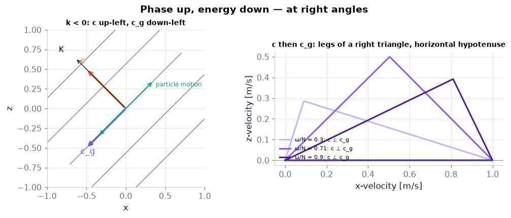

```python
fig, (a1, a2) = plt.subplots(1, 2, figsize=(9, 3.8))       # the book's geometry | the right triangle
v = ch07.internal_wave_velocities(-0.7071, 0.7071, 1.0)    # k < 0: K up-left at 45°, N = 1 rad/s
for vec, cl, lab in ((v["c"], COLORS["orange"], "c"), (v["cg"], COLORS["accent"], "c_g")):   # the two velocities
    a1.annotate("", xy=vec, xytext=(0, 0), arrowprops=dict(arrowstyle="->", color=cl, lw=2.5))   # arrow from the origin
    a1.text(vec[0]*1.15, vec[1]*1.15, lab, color=cl, fontsize=11)   # label
s_ = np.linspace(-1, 1, 2)                                 # crest lines ⟂ K through a few points
for off in np.linspace(-0.8, 0.8, 5):   # five crest lines
    a1.plot(off*(-0.7071) + s_*0.7071, off*0.7071 + s_*0.7071, color=COLORS["muted"], lw=0.8)   # direction ⟂ K = (1, 1)/√2
a1.annotate("", xy=(0.35, 0.35), xytext=(-0.35, -0.35), arrowprops=dict(arrowstyle="<->", color=COLORS["teal"], lw=1.5))   # motion along the crests
a1.text(0.38, 0.28, "particle motion", color=COLORS["teal"], fontsize=8)   # label
a1.annotate("", xy=(-0.7071*0.9, 0.7071*0.9), xytext=(0, 0), arrowprops=dict(arrowstyle="->", color=COLORS["ink"], lw=1))   # K (up-left)
a1.text(-0.85, 0.72, "K", fontsize=10)   # label
a1.set_xlim(-1, 1); a1.set_ylim(-1, 1); a1.set_aspect("equal"); a1.set_title("k < 0: c up-left, c_g down-left", fontsize=9)   # true angles
a1.set_xlabel("x"); a1.set_ylabel("z")   # axes
for r, cl in ((0.3, "#c4b5fd"), (0.71, "#8b5cf6"), (0.9, "#4c1d95")):   # ω/N: the right triangles
    st = ch07.internal_wave_state(r, 1.0)                   # k > 0, m > 0
    a2.plot([0, st["cx"], st["cx"] + st["cgx"], 0], [0, st["cz"], st["cz"] + st["cgz"], 0], color=cl, lw=2,   # c, then c_g, then back
            label=f"ω/N = {r}: c ⊥ c_g")   # legend
a2.axhline(0, color=COLORS["muted"], lw=0.5); a2.set_aspect("equal"); a2.legend(fontsize=7, loc="lower left")   # horizontal reference
a2.set_xlabel("x-velocity [m/s]"); a2.set_ylabel("z-velocity [m/s]")   # axes
a2.set_title("c then c_g: legs of a right triangle, horizontal hypotenuse", fontsize=9)   # the message
fig.suptitle("Phase up, energy down — at right angles", fontweight="bold")   # overall message
savefig(fig, "ch07", "c16_geometry"); plt.show()   # save, then draw
```

**What you see.** Left, the book's geometry with k < 0 (our remake of Figs. 7.29 and 7.31 `N195`, `N197`): K and c up-left, $c_g$ down-left at a right angle, the crest lines (grey) and the particle motion (teal) along them. Right, for three frequencies, c followed by $c_g$: the two legs of a right triangle whose closing side is horizontal.

**How to read it.** The hypotenuse is horizontal: $c_x$ and $c_{gx}$ have the same sign, $c_z=-c_{gz}$.

**What would change if…** …ω → N: θ → 0, K horizontal, $c_g\to0$ — vertical columns bob and nothing propagates.

📝 **Note.** **St Andrew's cross** `N150` — A source oscillating at ω < N can only radiate waves with $\cos\theta=\omega/N$, so its energy leaves along four beams at θ from the vertical (for example ω = 0.71N gives θ = arccos 0.71 ≈ 44.8°, the case of our figure), phase lines moving across each beam. The figure is **our superposition of four Gaussian beams — an illustration of the geometry, not the photograph** (`N199`).

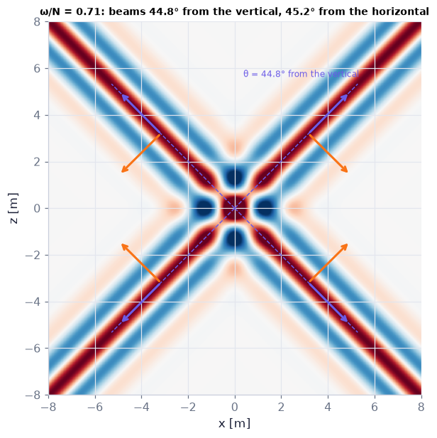

```python
n = 400 if not FAST else 200                               # grid size
xg = np.linspace(-8, 8, n)                                 # [m]
det = ch07.st_andrews_cross(xg, xg, 0.0, omega=0.71, N=1.0, width=1.0, detail=True)   # the illustrative field and its beams
fig, ax = plt.subplots(figsize=(5.5, 5.5))   # square panel
ax.imshow(det["field"], extent=(-8, 8, -8, 8), origin="lower", cmap="RdBu_r", vmin=-1, vmax=1)   # the field: crests red, troughs blue
beam_labels(ax, det["theta"], r=7.5)                        # dashed beam axes at θ from the vertical
for bm in det["beams"]:                                     # c (orange) and c_g (purple) on each beam
    p0 = 4.5*bm["e_beam"]   # a point on the beam axis
    ax.annotate("", xy=p0 + 2.5*bm["cg"]/np.linalg.norm(bm["cg"]), xytext=p0, arrowprops=dict(arrowstyle="->", color=COLORS["accent"], lw=2))   # c_g: along the beam
    ax.annotate("", xy=p0 + 2.5*bm["c"]/np.linalg.norm(bm["c"]), xytext=p0, arrowprops=dict(arrowstyle="->", color=COLORS["orange"], lw=2))   # c: across the beam
ax.set_xlabel("x [m]"); ax.set_ylabel("z [m]")   # axes
ax.set_title(f"ω/N = 0.71: beams {np.degrees(det['theta']):.1f}° from the vertical, {90 - np.degrees(det['theta']):.1f}° from the horizontal", fontsize=9)   # both angles
savefig(fig, "ch07", "c16_st_andrews"); plt.show()   # save, then draw
```

**What you see.** An X of striped beams (red and blue: crests and troughs of the density perturbation) with the purple $c_g$ arrows pointing away from the source along each beam and the orange c arrows across it.

**How to read it.** The stripes are phase lines (constant ρ′); energy runs along the beam, phase across it.

**What would change if…** …ω/N = 0.3: the beams tilt toward the horizontal (72.5° from the vertical).

📝 **Note.** **Real oceans** `N151` — In the real ocean N depends on z (below 0.01 rad/s); the plane-wave results hold locally where N changes little over a vertical wavelength 2π/m, and rays (C10's method) bend as N changes — WKB theory in Ch. 13.

📝 **Note.** **The energy equation** `N152` — Multiply (7.128)–(7.130), $\frac{\partial u}{\partial t}=-\frac1{\rho_0}\frac{\partial p'}{\partial x},\ \frac{\partial v}{\partial t}=-\frac1{\rho_0}\frac{\partial p'}{\partial y},\ \frac{\partial w}{\partial t}=-\frac1{\rho_0}\frac{\partial p'}{\partial z}-\frac{\rho'g}{\rho_0}$ by ρ₀u, ρ₀v, ρ₀w and add — the Ch. 4 energy move, $\rho\frac{D}{Dt}\big(\tfrac12u_j^2\big)=\rho g_ju_j-u_j\frac{\partial p}{\partial x_j}+u_j\frac{\partial\sigma_{ij}}{\partial x_i}$ *(4.56)* — to get (7.147): kinetic energy changes by buoyancy work gρ′w and by the divergence of the energy flux p′u. The code evaluates it point by point for a plane wave.

$$ \frac{\partial}{\partial t}\Big[\tfrac12\rho_0(u^2+v^2+w^2)\Big]+g\rho'w+\nabla\cdot(p'\mathbf u)=0 \qquad \text{(7.147)} $$

```python
print(ch07.internal_energy_budget_residual(0.3, -0.2, 1.0, 1.0, 1.0, 0.01, 1e-3), "W/m³")   # (7.147): ≈ 0
```

```
-8.711065735627179e-13 W/m³
```

📝 **Note.** **Available potential energy** `N153–N155` — With (7.131), $\frac{\partial\rho'}{\partial t}-\frac{N^2\rho_0}gw=0$ the buoyancy work is a time derivative, $\frac{\partial E_p}{\partial t}=g\rho'w=\frac{\partial}{\partial t} \Big[\frac{g^2\rho'^2}{2\rho_0N^2}\Big]$ *(7.148)*; with w = ∂ζ/∂t, $\rho'=\frac{N^2\rho_0\zeta}{g}$ *(7.149)*, so the energy per unit **volume** is (7.150) — the available potential energy of Ch. 13. Number: N = 0.01 rad/s, ζ = 10 m → 5 J/m³.

$$ E_p=\frac{g^2\rho'^2}{2\rho_0N^2}=\tfrac12N^2\rho_0\zeta^2 \qquad \text{(7.150)} $$

> 🔁 **Tools from earlier chapters used here** (see `knowledge/primers.md`)
- **density jump as a delta function** — a step of height Δρ has a derivative that is zero except at the step, with total Δρ: $-d\bar\rho/dz=\Delta\rho\,\delta(z)$ — the 1-D version of Ch. 6 P149's delta. The next note uses it to write $N^2=\frac g{\rho_0}(\rho_2-\rho_1)\delta(z)$ *(7.152)* and recover $E_p=\tfrac14(\rho_2-\rho_1)ga^2$ *(7.151)*.

📝 **Note.** **Consistency with C13** `N156, N157` — For two deep fluids the potential energy per unit area was $E_p=\tfrac14(\rho_2-\rho_1)ga^2$ *(7.151)*; writing a density jump as $N^2=\frac g{\rho_0}(\rho_2-\rho_1)\delta(z)$ *(7.152)* and integrating (7.150), $E_p=\frac{g^2\rho'^2}{2\rho_0N^2}=\tfrac12N^2\rho_0\zeta^2$ over z recovers it (a 1-D Dirac delta is the limit of a narrow step's derivative — Ch. 6 P149 in one dimension). The code smooths the jump over a width ε and lets ε shrink:

```python
eps_list = [1.0, 0.3, 0.1, 0.03]                           # widths of the smoothed density step [m]
errs = []                                                   # relative errors against ¼Δρga²
for eps in eps_list:
    d = ch07.internal_pe_interface_limit(1.0, 1000.0, 1002.0, eps=eps, detail=True)   # ∫½N²ρ₀⟨ζ²⟩dz [J/m²]
    errs.append(abs(d["rel_error"]))
    print(f"ε = {eps:4.2f} m: {d['Ep_column']:.5f} J/m² vs ¼Δρga² = {d['target']:.4f} ({d['rel_error']:+.2%})")
print(f"observed order in ε: {observed_order(eps_list, errs):.2f}")   # ≈ 1: the error shrinks like ε
```

```
ε = 1.00 m: 4.83780 J/m² vs ¼Δρga² = 4.9050 (-1.37%)
ε = 0.30 m: 4.88467 J/m² vs ¼Δρga² = 4.9050 (-0.41%)
ε = 0.10 m: 4.89821 J/m² vs ¼Δρga² = 4.9050 (-0.14%)
ε = 0.03 m: 4.90296 J/m² vs ¼Δρga² = 4.9050 (-0.04%)
observed order in ε: 1.00
```

> 🔁 **Tools from earlier chapters used here** (see `knowledge/primers.md`)
- **complex conjugate** — $z^*=a-ib$ for $z=a+ib$; $zz^*=\lvert z\rvert^2$ (Ch. 2 P81).

> 📎 **Primer — mean of a product of real parts.** `P178` · For two fields written as real parts of complex amplitudes, the average over a period of their product is $\langle\mathrm{Re}(Ae^{i\theta})\,\mathrm{Re}(Be^{i\theta})\rangle=\tfrac12\mathrm{Re}(AB^*)$ (B* the complex conjugate, Ch. 2 P81). Two fields 90° out of phase (B = iA) give zero: they carry no mean product.

```python
import numpy as np                                # numbers
A, B = 2.0, 3.0*np.exp(1j*0.5)                    # amplitudes with a phase shift
th = np.linspace(0, 2*np.pi, 100001)              # one period of the phase
mean = np.mean(np.real(A*np.exp(1j*th))*np.real(B*np.exp(1j*th)))   # the average of the product of real parts
print(mean, 0.5*np.real(A*np.conj(B)))            # both 2.633
```

```
2.632774012884703 2.6327476856711183
```

📝 **Note.** **The plane-wave fields** `N158` — Assume $[u,w,p',\rho']=[\hat u,\hat w,\hat p,\hat\rho]e^{i(kx+mz-\omega t)}$ with real ŵ (D37 step 1).

📝 **Note.** **The energy of an internal wave (used in D37 step 11)** `N160–N163` — Per unit volume and averaged over a period, the kinetic energy is $\tfrac12\rho_0\langle u^2+w^2\rangle$ and the potential energy is $\tfrac12\frac{g^2}{\rho_0N^2}\langle\rho'^2\rangle$ (the parcel-displacement energy of Ch. 1's N, written with ρ′). With the ½Re(AB*) rule (P178 above) each mean square is half the squared amplitude, and the amplitudes are the plane-wave ones D37 finds in steps 3–4 (derived line by line just below): $\lvert\hat u\rvert=\frac mk\hat w$ and $\lvert\hat\rho\rvert=\frac{N^2\rho_0}{\omega g}\hat w$. That gives $E_k=\tfrac14\rho_0\big(\frac{m^2}{k^2}+1\big)\hat w^2$ *(7.154)* and $E_p=\frac{N^2\rho_0}{4\omega^2}\hat w^2$ *(7.155)*. They are equal, $E_k=E_p$ *(7.156)*, because the dispersion relation $\omega^2=k^2N^2/(k^2+m^2)$ turns $N^2/\omega^2$ into $(k^2+m^2)/k^2=\frac{m^2}{k^2}+1$. So the total is $E=\tfrac12\rho_0\big(\frac{m^2}{k^2}+1\big)\hat w^2$ *(7.157)* — the E that D37 multiplies by $\mathbf c_g$ in step 11. (Stated, not derived line by line; the code after D37 checks $E_k=E_p$ to round-off.)

$$ E=\tfrac12\rho_0\Big(\frac{m^2}{k^2}+1\Big)\hat w^2 \qquad \text{(7.157)} $$

#### 🧮 Derivation — Polarization, mean flux and $\mathbf F=\mathbf c_gE$ `D37` (Eq. 7.159: $\mathbf F=\mathbf c_gE$)

**What we want to show.** Express every field of an internal plane wave through w, compute the mean energy flux and show it equals group velocity × energy.

**Assumptions.** Plane wave in the x–z plane, k > 0, real ŵ.

**The plan.**

1. Polarization relations from three equations.
2. Mean flux with real parts.
3. Compare with c_g E.

**Tools we use** (each explained before this point): complex amplitudes (P176) · mean of a product of real parts (P178) · complex conjugate (P81) · (7.145), $\mathbf c_g=\frac{Nm}{K^3}(m\mathbf e_x-k\mathbf e_z)\ (k>0)$, (7.157), $E=\tfrac12\rho_0\Big(\frac{m^2}{k^2}+1\Big)\hat w^2$.

**We start from**

$$ \begin{array}{l}[u,w,p',\rho']=[\hat u,\hat w,\hat p,\hat\rho]e^{i(kx+mz-\omega t)}\ \text{with} \\ \frac{\partial u}{\partial t}=-\frac1{\rho_0}\frac{\partial p'}{\partial x}\ \text{(7.128)} \\ \frac{\partial\rho'}{\partial t}-\frac{N^2\rho_0}gw=0\ \text{(7.131)} \\ \frac1{\rho_0}\nabla_H^2p'=\frac{\partial^2w}{\partial z\,\partial t}\ \text{(7.132)}\end{array} $$

*In words:* plane-wave fields in the horizontal momentum, density and pressure equations of D32–D33

**Step 1 of 12 — Assume plane-wave fields.**

$$ [u,w,p',\rho']=[\hat u,\hat w,\hat p,\hat\rho]e^{i\theta},\ \theta=kx+mz-\omega t,\ \hat w\ \text{real} $$

- *Why we can do this:* The equations are linear with constant N; choosing the phase origin makes ŵ real.
- *In words:* every field is a complex amplitude times one wave.

**Step 2 of 12 — Get p̂ from (7.132).**

$$ -\frac{k^2}{\rho_0}\hat p=(im)(-i\omega)\hat w=m\omega\hat w\ \Rightarrow\ \hat p=-\frac{\omega m\rho_0}{k^2}\hat w $$

- *Why we can do this:* ∇_H² → −k² (l = 0) and ∂²/∂z∂t → (im)(−iω) = mω.
- *In words:* the pressure amplitude.

**Step 3 of 12 — Get ρ̂ from (7.131).**

$$ -i\omega\hat\rho=\frac{N^2\rho_0}g\hat w\ \Rightarrow\ \hat\rho=\frac{iN^2\rho_0}{\omega g}\hat w $$

- *Why we can do this:* ∂/∂t → −iω and 1/(−i) = i; the factor i means ρ′ is 90° out of phase with w.
- *In words:* the density amplitude.

**Step 4 of 12 — Get û from (7.128).**

$$ -i\omega\hat u=-\frac{ik}{\rho_0}\hat p\ \Rightarrow\ \hat u=-\frac mk\hat w $$

- *Why we can do this:* ∂/∂t → −iω, ∂/∂x → ik; insert p̂. It agrees with K·u = 0 (D35): kû + mŵ = 0.
- *In words:* the horizontal velocity amplitude.

**Step 5 of 12 — Collect the polarization relations.**

$$ p'=-\frac{\omega m\rho_0}{k^2}\hat we^{i\theta},\ \rho'=\frac{iN^2\rho_0}{\omega g}\hat we^{i\theta},\ u=-\frac mk\hat we^{i\theta}\ \text{(7.153)} $$

- *Why we can do this:* Collect the three amplitudes of steps 2–4, each multiplied by the common wave factor $e^{i\theta}$; ŵ is the only free constant.
- *In words:* everything in terms of w.

**Step 6 of 12 — Write the mean flux.**

$$ \mathbf F=\overline{p'\mathbf u}=\mathbf e_x\overline{p'u}+\mathbf e_z\overline{p'w} $$

- *Why we can do this:* The energy flux is the pressure work p′u (7.147), $\frac{\partial}{\partial t}\Big[\tfrac12\rho_0(u^2+v^2+w^2)\Big]+g\rho'w+\nabla\cdot(p'\mathbf u)=0$; average over a period.
- *In words:* power per unit area.

**Step 7 of 12 — Take real parts before multiplying.**

$$ \big\langle\mathrm{Re}(Pe^{i\theta})\,\mathrm{Re}(Qe^{i\theta})\big\rangle=\tfrac12\mathrm{Re}(PQ^*) $$

- *Why we can do this:* The real part of a product is not the product of real parts; this rule averages correctly (P178).
- *In words:* the right way to average a product.

**Step 8 of 12 — Compute the horizontal flux.**

$$ \overline{p'u}=\tfrac12\mathrm{Re}(\hat p\hat u^*)=\frac{\rho_0\omega m^2\hat w^2}{2k^3} $$

- *Why we can do this:* p̂ û* = (−ωmρ₀ŵ/k²)(−mŵ/k), both real.
- *In words:* horizontal energy flux.

**Step 9 of 12 — Compute the vertical flux.**

$$ \overline{p'w}=\tfrac12\mathrm{Re}(\hat p\hat w)=-\frac{\rho_0\omega m\hat w^2}{2k^2} $$

- *Why we can do this:* Because ŵ is real, ŵ* = ŵ in ½Re(p̂ŵ*); the product p̂ŵ is real and negative for m > 0.
- *In words:* vertical energy flux (downward for m > 0).

**Step 10 of 12 — Assemble F.**

$$ \mathbf F=\frac{\rho_0\omega m\hat w^2}{2k^2}\Big(\mathbf e_x\frac mk-\mathbf e_z\Big)\ \text{(7.158)} $$

- *Why we can do this:* Factor ρ₀ωmŵ²/(2k²) out of steps 8–9.
- *In words:* the energy flux vector.

**Step 11 of 12 — Form c_g E.**

$$ \mathbf c_gE=\frac{Nm}{K^3}(m\mathbf e_x-k\mathbf e_z)\frac{\rho_0}2\Big(\frac{m^2}{k^2}+1\Big)\hat w^2=\frac{\rho_0Nm\hat w^2} {2Kk^2}(m\mathbf e_x-k\mathbf e_z) $$

- *Why we can do this:* (7.145), $\mathbf c_g=\frac{Nm}{K^3}(m\mathbf e_x-k\mathbf e_z)\ (k>0)$ times (7.157) E = ½ρ₀(m²/k² + 1)ŵ², and m²/k² + 1 = K²/k².
- *In words:* group velocity times energy.

**Step 12 of 12 — Use the dispersion relation.**

$$ \frac NK=\frac\omega k\ \Rightarrow\ \mathbf c_gE=\frac{\rho_0\omega m\hat w^2}{2k^2}\Big(\mathbf e_x\frac mk-\mathbf e_z\Big)= \mathbf F\ \text{(7.159)} $$

- *Why we can do this:* (7.138) ω = kN/K; take 1/k out of (m, −k).
- *In words:* energy flux = group velocity × energy.

**Result**

$$ \begin{array}{l}p'=-\frac{\omega m\rho_0}{k^2}\hat we^{i\theta},\ \rho'=\frac{iN^2\rho_0}{\omega g}\hat we^{i\theta},\ u=-\frac mk\hat we^{i\theta}\ \text{(7.153)} \\ \mathbf F=\overline{p'\mathbf u}=\frac{\rho_0\omega m\hat w^2}{2k^2}\Big(\mathbf e_x\frac mk-\mathbf e_z\Big)\ \text{(7.158)} \\ \mathbf F=\mathbf c_gE\ \text{(7.159)}\end{array} $$

*In words:* every field through w; the energy flux is group velocity times energy

**What it means.** The same law as (7.71), $F=Ec_g,\ E=\tfrac12\rho ga^2$ for surface waves: wave energy is transported at the group velocity — here at right angles to the phase. Per unit volume and area here, per unit area and crest length there.

**Check it.** Units: ρ₀ωŵ²/k [kg/m³ · 1/s · m²/s² · m] = W/m² ✓. `internal_wave_energy` asserts F = c_g E and E_k = E_p ((7.154)–(7.156), $E_k=\tfrac14\rho_0\Big(\frac{m^2}{k^2}+1\Big)\hat w^2,\ E_p=\frac{N^2\rho_0}{4\omega^2}\hat w^2,\ E_k=E_p$) to 1e-12 ✓.

> ⚠️ **Common confusion (traps in `D37`):** Multiplying complex fields before taking real parts; using ŵ instead of ŵ* in ⟨p′w⟩ (harmless here, ŵ real, but wrong in general); forgetting ρ′ is 90° out of phase (it contributes nothing to a flux with w).

📝 **Note.** **Polarization and flux** `N159, N164–N166` — The polarization relations $p'=-\frac{\omega m\rho_0}{k^2}\hat we^{i\theta},\ \rho'=\frac{iN^2\rho_0}{\omega g}\hat we^{i\theta},\ u=-\frac mk\hat we^{i\theta}$ *(7.153)*: ρ′ is 90° out of phase with w (the factor i), so ρ′ peaks a quarter period after the upward velocity does. The mean flux $\mathbf F=\frac{\rho_0\omega m\hat w^2}{2k^2}\big(\mathbf e_x\frac mk-\mathbf e_z\big)$ *(7.158)* and $\mathbf c_gE$ reduce to each other with $\omega=kN/K$ *(7.138)*: $\mathbf F=\mathbf c_gE$ *(7.159)* — the same law as $F=Ec_g$ *(7.71)*.

> ⚠️ **Common confusion:** **units**: in $\mathbf F=\mathbf c_gE$ *(7.159)* F is per unit **area** and E per unit **volume**; in $F=Ec_g$ *(7.71)* F was per metre of crest (the whole depth) and E per unit horizontal area. Same law, different bookkeeping.

#### ✏️ Tiny example: c and c_g at 45°

N = 1 rad/s, K = 1 rad/m at θ = 45° (k = m = 0.707 rad/m).

1. ω = N cos 45° = 0.707 rad/s.
2. $\mathbf c=\frac{\omega}{K^2}(k,m)=0.707\times(0.707,0.707)=(0.5,0.5)$ m/s: up and to the right.
3. $\mathbf c_g=\frac{Nm}{K^3}(m,-k)=0.707\times(0.707,-0.707)=(0.5,-0.5)$ m/s: down and to the right.
4. $\mathbf c\cdot\mathbf c_g=0.25-0.25=0$: a right angle; $\lvert\mathbf c\rvert=\lvert\mathbf c_g\rvert=0.707$ m/s at this angle only.
5. ω/N = 0.71 → θ = arccos 0.71 = 44.8°.

```python
print(ch07.internal_wave_velocities(0.7071, 0.7071, 1.0))  # k > 0: c = (0.5, 0.5), c_g = (0.5, −0.5), dot 0
print(ch07.internal_wave_velocities(-0.7071, 0.7071, 1.0)) # k < 0 (the book's Fig. 7.29): c up-left, c_g down-left
print("printed (7.145) for k < 0:", ch07.internal_wave_velocities(-0.7071, 0.7071, 1.0, printed=True)["cg"])   # wrong way
e = ch07.internal_wave_energy(0.7071, 0.7071, 1.0, 0.01)   # ŵ = 1 cm/s, ρ₀ = 1000 kg/m³
print({n: v for n, v in e.items() if n in ("Ek", "Ep", "E", "F", "cgE")})
assert np.allclose(e["F"], e["cgE"]) and np.isclose(e["Ek"], e["Ep"])   # (7.159) and (7.156)
st = ch07.internal_wave_state(0.71, 1.0)
print(f"ω/N = 0.71: beam {st['beam_from_vertical_deg']:.2f}° from the vertical, {st['beam_from_horizontal_deg']:.2f}° from the horizontal")
```

```
{'omega': 0.7071067811865476, 'c': array([0.5, 0.5]), 'cg': array([ 0.5, -0.5]), 'dot': 0.0, 'theta_K': 0.7853981633974483}
{'omega': 0.7071067811865476, 'c': array([-0.5,  0.5]), 'cg': array([-0.5, -0.5]), 'dot': 0.0, 'theta_K': 0.7853981633974483}
printed (7.145) for k < 0: [0.5 0.5]
{'Ek': 0.05, 'Ep': 0.04999999999999999, 'E': 0.1, 'F': array([ 0.05, -0.05]), 'cgE': array([ 0.05, -0.05])}
ω/N = 0.71: beam 44.77° from the vertical, 45.23° from the horizontal
```

**What does the code above do?**

1. For k > 0, c = (0.5, 0.5) and $\mathbf c_g=(0.5,-0.5)$ m/s: perpendicular.
2. For k < 0 (K up-left, as the book draws it) c = (−0.5, 0.5) and the sign-safe $\mathbf c_g=\nabla_{\mathbf K}\omega= (-0.5,-0.5)$ m/s — down-left, as drawn. The printed (7.145), $\mathbf c_g=\frac{Nm}{K^3}(m\mathbf e_x-k\mathbf e_z)\ (k>0)$ would give (0.5, 0.5), up-right: wrong for k < 0.
3. $E_k=E_p=0.05$ J/m³ for ŵ = 1 cm/s, and the mean flux F equals $\mathbf c_gE$ component by component.
4. The beam of a source at ω = 0.71N makes 44.77° with the vertical and 45.23° with the horizontal.

```python
wK = lambda k_, m_: ch07.internal_wave_omega(k_, m_, 1.0)  # ω(k, m) = N|k|/K with N = 1 rad/s
k0, m0, h = -0.7071, 0.7071, 1e-6                          # the book's k < 0 case; difference step [rad/m]
cg_mine = np.array([(wK(k0 + h, m0) - wK(k0 - h, m0))/(2*h),   # ∂ω/∂k
                    (wK(k0, m0 + h) - wK(k0, m0 - h))/(2*h)])  # ∂ω/∂m
c = ch07.internal_wave_velocities(k0, m0, 1.0)["c"]         # phase velocity (7.144)
print("our gradient:", cg_mine, " c·c_g =", np.dot(cg_mine, c))
assert np.allclose(cg_mine, ch07.internal_wave_velocities(k0, m0, 1.0)["cg"], rtol=1e-7)   # c_g = ∇_K ω
assert abs(np.dot(cg_mine, c)) < 1e-9                      # perpendicular to c (to the difference error)
```

```
our gradient: [-0.5 -0.5]  c·c_g = 0.0
```

**What does this show?** Our centred differences of ω(k, m) at k = −0.7071, m = 0.7071 rad/m (N = 1 rad/s) give $\mathbf c_g=\nabla_{\mathbf K}\,\omega=(-0.5,-0.5)$ m/s — energy heading down and to the left — the same vector as the sign-safe `internal_wave_velocities`, and $\mathbf c\cdot\mathbf c_g=0$ to round-off: the energy moves at right angles to the phase.

```python
n = 256 if not FAST else 128                               # doubly periodic grid
xg = np.linspace(0, 100, n, endpoint=False); zg = np.linspace(0, 100, n, endpoint=False)   # [m]
X, Z = np.meshgrid(xg, zg)                                 # (z, x) layout
k0 = m0 = 1/np.sqrt(2)                                     # K₀ = 1 rad/m at 45° up-right
env0 = np.exp(-((X - 35)**2 + (Z - 65)**2)/(2*8.0**2))     # Gaussian envelope, 8 m wide, centred at (35, 65) m
field0 = env0*np.exp(1j*(k0*X + m0*Z))                     # the analytic packet (complex)
nf = 40 if not FAST else 20                                # frames
tt = np.linspace(0, 60, nf)                                # times [s]
frames = ch07.linear_evolve_2d(field0, xg, zg, tt, lambda k_, m_: np.abs(k_)/np.hypot(k_, m_))   # each mode at N|k|/K, N = 1
v = ch07.internal_wave_velocities(k0, m0, 1.0)             # c = (0.5, 0.5), c_g = (0.5, −0.5) m/s
fig, ax = plt.subplots(figsize=(5.2, 5.2))
im = ax.imshow(frames[0], extent=(0, 100, 0, 100), origin="lower", cmap="RdBu_r", vmin=-1, vmax=1)
ax.annotate("", xy=(35 + 16*v["cg"][0]/0.707, 65 + 16*v["cg"][1]/0.707), xytext=(35, 65), arrowprops=dict(arrowstyle="->", color=COLORS["accent"], lw=2))
ax.annotate("", xy=(35 + 16*v["c"][0]/0.707, 65 + 16*v["c"][1]/0.707), xytext=(35, 65), arrowprops=dict(arrowstyle="->", color=COLORS["orange"], lw=2))
ax.set_xlabel("x [m]"); ax.set_ylabel("z [m]")   # axes


def update(i):   # draw frame i
    im.set_data(frames[i])                                 # the packet at time tt[i]
    ax.set_title(f"t = {tt[i]:.0f} s: phase ↗ (orange c), packet ↘ (purple c_g)", fontsize=9)
    return []   # nothing to blit


show_animation(animate(update, frames=nf, fig=fig, interval=70))
```

[video not shown]

**What you see.** A packet of internal waves (N = 1 rad/s, K at 45° up-right): the stripes (crests) move up-right while the whole packet slides down-right, along its own crests — the `A6` animation, our version of the book's Fig. 7.32 `N198`.

**How to read it.** The packet moves at $\mathbf c_g=(0.5,-0.5)$ m/s: after 60 s its centre has moved 30 m right and 30 m down, while each stripe moved 30 m right and 30 m up.

**What would change if…** …ω → N (K nearly horizontal): $c_g\to0$ — the packet would hardly move while its stripes still slide.

#### 🎮 Interactive: Why does energy leave at right angles to the crests?

**Why interactive rather than a static figure:** The ω/N slider tilts the beams while the crests visibly slide across them; drag K in the wavenumber plane: ω stays fixed when only |K| changes, and $c_g$ stays perpendicular to c.

**What to try:**

- Preset *45° cross*: read both angles in the status.
- Drag the K arrow outward along its ray: ω does not change.
- Choose *near N*: the beams stand almost vertical and the energy hardly moves.
- Set the book's Fig. 7.29 geometry (k < 0) and check that $c_g$ points down-left.

```python
show_viz("ch07", "internal_wave_beams")   # full-width explainer; ⤢ Full screen for more room
```

🎮 Interactive 9/9 Why does energy leave at right angles to the crests? Open alone ↗

[interactive chart not shown]

**What would change if…** …N varied with depth, as in the real ocean (N largest in the thermocline)? The beams curve, like the rays of C10, and can reflect where ω = N — internal waves get trapped in the thermocline (Ch. 13).

*↪ **Exercises 7.1–7.20** are not reproduced (S01). Ideas from them used in this notebook: 7.2 → C12 (Stokes expansion and its trap); 7.3 → N02 (any initial shape); 7.4 → N30 (ψ); 7.5–7.6 → N63 (basin modes); 7.9–7.10 → N69, N72 (capillary c_g, minimum c_g); 7.11 → N72 (viscous decay); 7.12 → D20 (Gaussian packet); 7.13–7.14 → N91 (drift at any depth); 7.15 → N97 (soliton check); 7.18 → N105 (interfacial energies); 7.19 → D30 (two-layer dispersion); 7.20 → N131 (rigid lids).*

## ✅ What should have clicked

- **C01** A wave is a moving phase: crests move at $c=\omega/k=\lambda\nu$ *(7.4)* while the water only oscillates.
- **C02** For gentle waves the surface conditions can be moved to the flat level z = 0; what is dropped is of order $(ka)\cdot a\omega$ — relative error O(ka).
- **C03** Laplace plus the bottom, kinematic and dynamic conditions leave one frequency per wavenumber: $\omega=\sqrt{gk\tanh kH}$ *(7.28)*.
- **C04** Long waves outrun short ones; depth matters only for waves longer than about three times the depth, and all long waves travel at $\sqrt{gH}$ *(7.49)*.
- **C05** Under a wave the water goes round closed ellipses — circles in deep water, flat ellipses in shallow water.
- **C06** A wave holds $E=\tfrac12\rho ga^2$ *(7.42)* per square metre, half kinetic and half potential, and carries it at a speed that is not the crest speed.
- **C07** Surface tension adds a second restoring force; together with gravity it makes a slowest wave, 23 cm/s at 1.7 cm.
- **C08** Two opposite waves make a standing wave; walls keep only the patterns whose nodes fit, so a lake rings at its own periods.
- **C09** Groups and energy travel at $c_g=d\omega/dk$ *(7.67)* — half the crest speed in deep water — and $F=Ec_g$ *(7.71)*.
- **C10** Along a ray moving at $c_g$ the frequency never changes; the wavelength shrinks in shallow water, so crests turn parallel to the shore.
- **C11** A hydraulic jump's height comes from momentum alone; energy is lost, which is why only fast shallow flow can jump — or dispersion balances steepening in a soliton.
- **C12** At finite amplitude the orbits do not close: the water drifts forward at $a^2\omega ke^{2kz_0}$ while the mean at a fixed point stays zero; Stokes' speed correction needs a consistent third-order expansion.
- **C13** A small density step gives slow, tall waves, $\omega=\varepsilon\sqrt{gk}$ *(7.95)*, with the two fluids sliding past each other.
- **C14** A layer over deep water rings in two modes: barotropic (fast, at the surface) and baroclinic (slow, $\sqrt{g'H}$, almost invisible at the surface).
- **C15** In a stratified fluid the frequency is set by direction only: $\omega=N\cos\theta$ *(7.139)*, never above N.
- **C16** Internal waves are transverse and their energy moves at right angles to the crests: phase up, energy down, $\mathbf F=\mathbf c_gE$ *(7.159)*.

**What later chapters build on**

- Ch. 11: the interfacial vortex sheet with a shear flow is the Kelvin–Helmholtz instability; the σ-term of (7.56), $\omega=\sqrt{k\Big(g+\frac{\sigma k^2}{\rho}\Big)\tanh kH}$ stabilises short waves.
- Ch. 13: √(gH) and hydrostatic shallow water carry tides, tsunamis and Kelvin waves; rotation adds f to ω² (Poincaré and inertia–gravity waves); √(g′H)/f is the baroclinic Rossby radius; rays and WKB follow waves through N(z); equipartition fails in geostrophic adjustment.
- Ch. 15: characteristics and shocks are the compressible cousins of the simple wave (note N81) and the hydraulic jump.

**Not taught here (and where to find it)**

- Exercise text (S01).
- Nonlinear internal waves and wave breaking (research literature).
- Viscous damping in detail (Ch. 8 tools; named in note N72).

← All chapters

← PreviousNext →

Code and explanations: shammun/fluidpy (MIT). The book is not reproduced here; equations are cited by number.